# Ch. 14 Aerodynamics — fluidpy

#### ✏️ Tiny example: a staircase of circulation

On the starboard half the bound circulation is 10 m²/s at the root, then 8, then 5, then 0 at the tip.

1. Where it drops from 10 to 8 a filament of strength 2 leaves.
2. From 8 to 5: strength 3.
3. From 5 to 0 at the tip: strength 5 — the strongest.
4. Total shed on this half: 2 + 3 + 5 = 10 = the root circulation $\Gamma_0$.
5. The port half sheds the same amounts with the opposite sense of rotation.

The trailing vorticity is concentrated near the tips because that is where Γ falls fastest.

```python
g9 = np.linspace(0.05, np.pi - 0.05, 9)                      # nine stations along the span, as span angles γ (0 = port tip, π = starboard tip; C11 explains γ)
y9 = LL.span_position(gamma=g9, s=ac["s"])                   # the same stations in metres: y = −(s/2) cos γ
sheet = LL.trailing_sheet_strength(Gn=np.array([14.17]), gamma=g9, s=ac["s"])   # −dΓ/dy [m/s] for an elliptic loading with mid-span circulation 14.17 m²/s on our 12 m span
print(pd.DataFrame({"y [m]": y9, "−dΓ/dy [m/s]": sheet}).round(2).T.to_string(header=False))   # antisymmetric: zero at mid-span, largest toward the tips
tv = ch14.tip_vortex_estimate(W=ac["W"], rho=1.225, U=ac["U_cruise"], s=ac["s"])   # what our aircraft's wake rolls up into at 55 m/s
print(f"Γ0 = {tv['Gamma0']:.2f} m²/s, spacing of the two tip vortices = {tv['spacing']:.2f} m, they sink at {tv['descent_speed']:.2f} m/s")   # 14.17, 9.42 (= πs/4), 0.24
```

```
y [m]         -5.99 -5.45 -4.14 -2.23  0.0  2.23  4.14  5.45   5.99
−dΓ/dy [m/s] -47.19 -5.15 -2.25 -0.94  0.0  0.94  2.25  5.15  47.19
Γ0 = 14.17 m²/s, spacing of the two tip vortices = 9.42 m, they sink at 0.24 m/s
```

**What does the code above do?**

1. `LL.trailing_sheet_strength` returns $-d\Gamma/dy$, the strength per metre of span of the trailing sheet. It is antisymmetric (negative on the port half, positive on the starboard half), zero at mid-span and largest toward the tips.
2. `ch14.tip_vortex_estimate` (ours) gives the mid-span circulation our aircraft needs at cruise, 14.17 m²/s clockwise, and what the sheet rolls up into (N37 below): two vortices 9.42 m apart sinking at 0.24 m/s.
3. The span angle γ and the list `Gn` are those of the primer above (P351): `Gn=np.array([14.17])` is an elliptic loading whose mid-span circulation is 14.17 m²/s. C11 introduces both properly.

```python
s = ac["s"]                                                  # span [m]
gf = np.linspace(0.05, np.pi - 0.05, 2001)                   # a fine set of span angles
yf = -(s/2)*np.cos(gf)                                       # the stations in metres
Gf = 14.17*np.sin(gf)                                        # the elliptic loading Γ(y) [m²/s]
mine = -(Gf[2:] - Gf[:-2])/(yf[2:] - yf[:-2])                # −dΓ/dy by a centred difference: (next − previous)/(distance between them)
assert np.allclose(mine, LL.trailing_sheet_strength(Gn=np.array([14.17]), gamma=gf, s=s)[1:-1], rtol=1e-5)   # same numbers → the library does exactly this
print(f"−dΓ/dy half-way out on the starboard side (y = {yf[1334]:.2f} m): {mine[1333]:.3f} m/s")   # positive on the starboard half
```

```
−dΓ/dy half-way out on the starboard side (y = 2.92 m): 1.315 m/s
```

**What does the code above do?**

The slope of the loading is estimated by finite differences on a fine grid and compared with the tested function (which differentiates the sine series exactly).

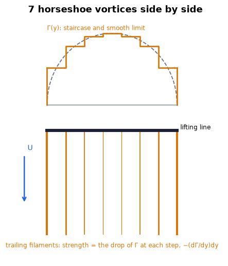

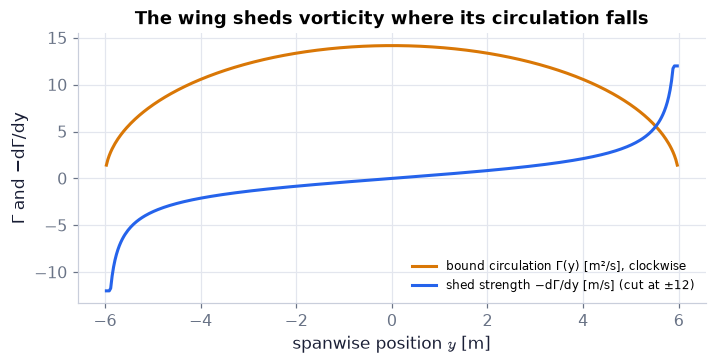

```python
fig = draw_horseshoe_staircase(N=7)                          # seven nested horseshoe vortices and the staircase Γ(y) they add up to
plt.show()                                                   # display
yy = np.linspace(-6.0, 6.0, 401)[1:-1]                       # stations along the 12 m span [m], tips excluded (the slope is infinite there)
Gam = LL.elliptic_circulation(y=yy, s=12.0, Gamma1=14.17)    # Eq. (14.23): the elliptic loading [m²/s]
fig, ax = plt.subplots(figsize=(6.4, 3.2))                   # one panel
ax.plot(yy, Gam, color=COLORS["amber"], label="bound circulation Γ(y) [m²/s], clockwise")          # the loading
ax.plot(yy, np.clip(-np.gradient(Gam, yy), -12, 12), color=COLORS["blue"], label="shed strength −dΓ/dy [m/s] (cut at ±12)")   # the trailing sheet
ax.set(xlabel="spanwise position $y$ [m]", ylabel="Γ and −dΓ/dy", title="The wing sheds vorticity where its circulation falls")   # labels
ax.legend(fontsize=8); plt.show()                            # legend and display
```

**What you see.** First: seven nested horseshoes seen from above, with the staircase of circulation they add up to. Second: the smooth elliptic loading (amber) and the strength of the sheet it sheds (blue).

**How to read it.** Each horseshoe adds one step to the staircase and two trailing legs. In the smooth limit the legs become a sheet whose strength is the slope of the loading: nothing leaves at mid-span, almost everything leaves near the tips.

**What would change if…** …the loading were flat-topped? The filaments would crowd even closer to the tips.

📝 **Note.** **N37 [B]** Assumption (iii) is not what happens: each half of the sheet rolls up into one **tip vortex** of circulation $\Gamma_{\text{tip}}=\Gamma_0$. **Not in the book — ours:** the two are a distance $b'=\dfrac1{\Gamma_0}\displaystyle\int\Gamma\,dy$ apart ($\tfrac\pi4s$ for the elliptic loading) and sink at $\Gamma_0/2\pi b'$. This is why airports keep a small aircraft minutes behind a large one, and what a contrail makes visible.

> 🔁 **Recap — point vortices move with the velocity the others induce** (Ch. 5 §5.6). A vortex is carried by the velocity all the *other* vortices induce at its position, $d\mathbf x_k/dt=\sum_{j\ne k}\mathbf u_j(\mathbf x_k)$; the total circulation and the impulse $\sum\Gamma_ky_k$ do not change.

```python
roll = ch14.wake_rollup(Gn=np.array([14.17]), s=12.0, n=(200 if not FAST else 80), n_t=41)   # the sheet of our aircraft cut into point vortices and followed in time (time stands for distance behind the wing)
stops = [0, 5, 10, 20, 40]                                   # five stop-frames out of the 41 saved times
fig, ax = plt.subplots(figsize=(6.4, 3.6))                   # rear view
sc = ax.scatter(roll["y"][0], roll["z"][0], s=6, c=np.where(roll["sigma"] > 0, COLORS["blue"], COLORS["rose"]))   # one dot per vortex, coloured by its sense of rotation
(cen,) = ax.plot([], [], "k+", ms=12)                        # the centroid of each half
ax.set(xlim=(-8, 8), ylim=(-6.5, 1.5), xlabel="spanwise position $y$ [m]", ylabel="height $z$ [m]", title="t = 0.0 s · centroids 9.42 m apart · 0.00 m down")   # fixed axes
ax.set_aspect("equal")                                       # true proportions
fig.canvas.draw(); fig.set_layout_engine("none")             # lay the figure out once, then freeze it
def update(j):                                               # draw stop-frame j
    k = stops[j]                                             # index of the saved time
    sc.set_offsets(np.c_[roll["y"][k], roll["z"][k]])        # move the vortices
    cen.set_data([-roll["centroid_y"][k], roll["centroid_y"][k]], [roll["centroid_z"][k], roll["centroid_z"][k]])   # the two centroids
    ax.set_title(f"t = {roll['t'][k]:.1f} s · centroids {2*roll['centroid_y'][k]:.2f} m apart · {-roll['centroid_z'][k]:.2f} m down")   # readout (short enough to fit the panel)
show_animation(animate(update, frames=len(stops), fig=fig, interval=900), player="frames")   # a frame player: stop at each of the five times
print(f"theory (ours): spacing b' = {roll['spacing_theory']:.2f} m, descent speed = {roll['descent_speed_theory']:.3f} m/s; impulse drift over the run = {np.ptp(roll['impulse'])/abs(roll['impulse'][0]):.1e}")   # the invariants
```

[figure not shown]

```
theory (ours): spacing b' = 9.42 m, descent speed = 0.239 m/s; impulse drift over the run = 2.1e-16
```

**What does the code above do?**

1. `ch14.wake_rollup` cuts the trailing sheet of an elliptic loading into point vortices (with a small core so that the computation stays smooth) and moves each with the velocity the others induce. Time stands for distance behind the wing.
2. Five of the saved times are shown as stop-frames; blue and rose are the two senses of rotation; the + marks are the centroids of the two halves.
3. The printed line gives the theoretical spacing $b'=\tfrac\pi4s$ = 9.42 m and descent speed, and how little the impulse $\sum\Gamma_ky_k$ drifted.

**What you see.** The wake seen from behind at five times. A flat row of vortices curls up at both ends into two spirals that sink. **The picture is qualitative past the first turn of each spiral.**

**How to read it.** The centroids (+) stay the same distance apart — 9.42 m, the invariant $b'$ — while they move down. **The turns of the spiral are qualitative**: their number depends on how many vortices and what core size the computation uses. What is robust is the spacing, the total circulation of each half and the sinking.

**What would change if…** …the aircraft were heavier or slower? More circulation (it scales as $W/U$): stronger vortices that sink faster.

📝 **Note.** **N69 [C]** The picture of a bound vortex with trailing vortices is Lanchester's; the usable theory is Prandtl's (see N17 in C03).

**What would change if…** …we stand on the wing and ask what all those filaments do to the air there? C09.

### 🧩 Downwash: $w(y_1)=\dfrac{1}{4\pi}\displaystyle\int_{-s/2}^{s/2}\dfrac{d\Gamma}{dy}\dfrac{dy}{(y_1-y)}$ (14.13) `C09`

*The question:* How fast is the air sinking where the wing meets it?

#### The problem in plain words

A wing holds the aircraft up by throwing air down — Newton's third law. Some of that downward motion is already present *at the wing itself*, caused by the trailing vortices behind it. Every filament swirls the air round its own axis; between the tips all of them push down. Add up their pushes at one point of the wing and you have the downwash there.

#### The idea

```
top view                         lifting line
─────────────●───────────────────────○──────────────      ● station y₁ where we want the downwash
             y₁    |y − y₁| = d      y                    ○ a filament leaves at y …
                                     ║
                                     ║   … and runs downstream for ever
                                     ▼

an infinite line vortex would give   Γ/(2π d)
this one starts at the wing, so the wing sees half:   Γ/(4π d)
```

> 🔁 **Recap — the filament law** (Ch. 5 §5.5). $d\mathbf u=\dfrac{\Gamma\,d\mathbf l}{4\pi}\times\dfrac{\mathbf x-\mathbf x'}{\lvert\mathbf x-\mathbf x'\rvert^3}$ (5.17): every piece of a vortex filament induces a velocity round itself; added along a straight piece it gives the speed $\dfrac{\Gamma}{4\pi d}(\cos\theta_a-\cos\theta_b)$ at distance $d$ from the line, with $\theta_a$, $\theta_b$ the angles to its two ends.

> 🔁 **Recap — Half an infinite line vortex `R12`** (Ch. 5 §5.5). For a filament that starts at the lifting line and runs downstream for ever the two angles are 0 and 90°: speed $\Gamma/(4\pi d)$, half the value $\Gamma/(2\pi d)$ of a line infinite both ways. With the strength of the shed filament from the derivation in C08: $dw(y_1)=\dfrac{-(d\Gamma/dy)\,dy}{4\pi(y-y_1)}$.

```python
print(BS.segment_speed(d=1.0, theta_a=0.0, theta_b=np.pi/2, Gamma=4*np.pi))   # a half-line of strength 4π at distance 1 m: 1.0 m/s
print(BS.segment_speed(d=1.0, theta_a=0.0, theta_b=np.pi, Gamma=4*np.pi))     # the full infinite line: 2.0 m/s — twice as much
```

```
0.9999999999999999
2.0
```

> ⚠️ **slip #3 — the book prints** that this velocity is induced “at location $y$ (< $y_1$)”**; the correct form is** it is induced **at $y_1$**, and it is downward for a filament at $y>y_1$ on the starboard half, as the book's own figure caption says.

> 📎 **Primer — Cauchy principal value.** `P344` · An integrand like $1/(x-c)$ is +∞ on one side of $c$ and −∞ on the other. The two infinite areas cancel if we cut out a *symmetric* gap $(c-\epsilon,\ c+\epsilon)$ and let ε → 0: that limit is the principal value. `scipy.integrate.quad` (primed in Ch. 3, P87) computes it with `weight="cauchy"`.

```python
val = quad(lambda x: 1.0, -1, 1, weight="cauchy", wvar=0.3)[0]   # principal value of the integral of 1/(x - 0.3) from -1 to 1
print(val, np.log(0.7/1.3))                                      # both -0.619
```

```
-0.6190392084062235 -0.6190392084062235
```

> 🔁 **Tools from earlier chapters used in this block** (one line each; the full primers are in the chapters named)
- **improper integral as a limit** — an integral that runs out to infinity is the limit of integrals to a finite end; here a trailing filament runs from the wing to infinity downstream, and its effect at the wing is that limit. *(Ch. 5, P144)*
- **`scipy.integrate.quad` (with `weight="cauchy"`, `points=`)** — `quad(f, a, b)` integrates a function numerically and returns the value and an error estimate; the option `weight="cauchy"` treats a factor 1/(x − x₀) as a principal value (primer P344 below), which is exactly the form of the downwash integral. *(Ch. 3, P87, P344)*

#### 🧮 Derivation — The downwash at the lifting line `D12` ★★ (Eq. 14.13: $w(y_1)=\dfrac{1}{4\pi}\displaystyle\int_{-s/2}^{s/2}\dfrac{d\Gamma}{dy}\,\dfrac{dy}{(y_1-y)}$)

**What we want to show.** Add up the velocity that all the trailing filaments induce at one point of the wing.

**Assumptions.** Lifting-line assumptions (ii) and (iii) — a straight bound vortex; straight, parallel, non-interacting trailing filaments.

**The plan.**

1. Specialise to a half-infinite line.
2. Insert the shed strength.
3. Fix the direction and sign.
4. Add all filaments.
5. Say what the singular integral means.

**Tools we use** (each explained before this point): the segment formula (recap in C09 · R12) · D11 · principal value (P344) · improper integral (P144, reminder)

**We start from**

$$ \begin{array}{l}\text{the speed induced by a straight vortex segment,}\ q=\dfrac{\Gamma}{4\pi d}(\cos\theta_a-\cos\theta_b)\ \text{, the} \\ \text{straight-line form of the filament law}\ d\mathbf u=\dfrac{\Gamma\,d\mathbf l}{4\pi}\times\dfrac{\mathbf x-\mathbf x'}{\lvert\mathbf x-\mathbf x'\rvert^3} \\ \text{(5.17)}\end{array} $$

*In words:* d is the distance to the line, θ_a and θ_b the angles to its two ends

**Step 1 of 7 — Take a filament that starts at the wing.**

$$ \theta_a=0,\ \theta_b=90^\circ:\quad q=\dfrac{\Gamma}{4\pi d} $$

- *Why we can do this:* Seen from a point on the lifting line, one end of the filament is infinitely far downstream (angle 0) and the other is abreast of the point (90°); cos 0 − cos 90° = 1.
- *In words:* A half-infinite line induces half of what an infinite line would (Γ/2πd).

**Step 2 of 7 — Insert the distance and the strength.**

$$ \lvert dw\rvert=\dfrac{\lvert d\Gamma/dy\rvert\,dy}{4\pi\,\lvert y-y_1\rvert} $$

- *Why we can do this:* The filament leaves at y, the point is at y₁, so d = abs(y − y₁); its strength is $-\dfrac{d\Gamma}{dy}\,dy$ (D11).
- *In words:* The size of one filament's contribution.

**Step 3 of 7 — Fix the direction.**

$$ dw(y_1)=\dfrac{-(d\Gamma/dy)\,dy}{4\pi\,(y-y_1)}\ \text{, w positive downward} $$

- *Why we can do this:* A starboard filament (positive strength) turns so that the air inboard of it moves down: positive for y > y₁. The signed denominator keeps the formula right on the other side too.
- *In words:* Filaments outboard of the point push it down.

**Step 4 of 7 — Check the other side.**

$$ y<y_1,\ -\dfrac{d\Gamma}{dy}>0:\quad dw<0 $$

- *Why we can do this:* The point is now *outboard* of that starboard filament, where its swirl is upward. (Slip #3: the velocity is induced at y₁, wherever the filament is.)
- *In words:* A filament pushes down on one side of itself and up on the other.

**Step 5 of 7 — Absorb the minus sign.**

$$ dw(y_1)=\dfrac{1}{4\pi}\,\dfrac{d\Gamma}{dy}\,\dfrac{dy}{(y_1-y)} $$

- *Why we can do this:* −1/(y − y₁) = 1/(y₁ − y).
- *In words:* The same contribution, written as the book does.

**Step 6 of 7 — Add all the filaments.**

$$ w(y_1)=\dfrac{1}{4\pi}\displaystyle\int_{-s/2}^{s/2}\dfrac{d\Gamma}{dy}\,\dfrac{dy}{(y_1-y)}\ \text{(14.13)} $$

- *Why we can do this:* Velocities add (the filament law is linear); filaments leave from every y between the tips. The straight bound vortex induces no velocity on its own line.
- *In words:* The downwash is the sum of all the half-line contributions.

**Step 7 of 7 — Say what the integral means at y = y₁.**

$$ w(y_1)=\dfrac1{4\pi}\displaystyle\lim_{\epsilon\to0}\Big[\int_{-s/2}^{y_1-\epsilon}+\int_{y_1+\epsilon}^{s/2}\Big]\dfrac{d\Gamma}{dy}\dfrac{dy}{(y_1-y)} $$

- *Why we can do this:* The integrand is infinite at y = y₁ with opposite signs on the two sides; the filaments just inboard and just outboard cancel, and the symmetric limit — the principal value — is finite (P344).
- *In words:* The singularity is harmless if we approach it evenly from both sides.

**Result**

$$ w(y_1)=\dfrac{1}{4\pi}\displaystyle\int_{-s/2}^{s/2}\dfrac{d\Gamma}{dy}\,\dfrac{dy}{(y_1-y)}\ \text{(a principal value)} $$

*In words:* The air at the wing sinks at a speed set by how the circulation falls off along the whole span

**What it means.** The downwash at a station depends on the *whole* loading, most strongly on how Γ changes nearby. **Fails when:** the wake rolls up or is not flat; near the tips of a wing whose Γ does not fall smoothly to zero the integral diverges (the horseshoe).

**Check it.** Units — (m/s) × m / m = m/s ✓. Limits — one horseshoe (Γ drops only at the tips): w(0) = 2 × Γ/(4π s/2) = Γ/(πs); elliptic loading: Γ₁/2s at every station (computed by quadrature in C14). Number — Γ = 4π m²/s, s = 2 m: 2 m/s at mid-span.

> ⚠️ **Common confusion (traps in `D12`):** The minus sign absorbed into (y₁ − y); w is positive downward (trap T5); the integral is a principal value (trap T10); the bound vortex contributes nothing on its own line; slip #3.

#### ✏️ Tiny example: the simplest wing: one horseshoe

**N60 [B]** One bound vortex of constant strength Γ = 4π ≈ 12.6 m²/s and span $s$ = 2 m, with one trailing leg from each tip.

1. Each leg is a half-line at distance $s/2$ = 1 m from the centre: it induces Γ/(4π × 1) = 1 m/s there.
2. Both legs push down at the centre: $w(0)$ = 2 m/s.
3. In symbols $w(0)=\dfrac{\Gamma}{\pi s}$ (ours) = 4π/(2π) = 2 ✓.
4. Move the station toward a tip, to $y_1$ = 0.9 m: the near leg is 0.1 m away and gives 10 m/s, the far leg 1.9 m away gives 0.53 m/s — the downwash grows without limit at the tips.

```python
print(f"horseshoe (Γ = 10 m²/s, s = 12 m): downwash at the centre = {LL.horseshoe_downwash(x=0.0, y=0.0, Gamma=10.0, s=12.0):.4f} m/s")   # Γ/(πs) = 0.2653, positive down
print("the same as a velocity vector (x downstream, y along the span, z up):", np.round(LL.horseshoe_velocity(x=0.0, y=0.0, z=0.0, Gamma=10.0, s=12.0), 4))   # (0, 0, −0.2653): with z up, a downwash is negative
hw = LL.horseshoe_wing(Gamma=10.0, s=12.0, rho=1.225, U=30.0)   # lift and 'induced drag' of the horseshoe wing
print(f"horseshoe wing: L = {hw['L']:.0f} N; its drag over the best possible wing's = {hw['ratio']:.2f} ({hw['note']})")   # 0.5 — an artefact
ell = lambda y: np.sqrt(1 - (2*y/12.0)**2)                    # an elliptic loading with mid-span circulation 1 m²/s on a 12 m span
print(f"elliptic loading: w(0) = {LL.downwash(y1=0.0, Gamma_fn=ell, s=12.0):.5f} m/s, w(3 m) = {LL.downwash(y1=3.0, Gamma_fn=ell, s=12.0):.5f} m/s")   # 0.04167 = Γ1/2s at both stations
```

```
horseshoe (Γ = 10 m²/s, s = 12 m): downwash at the centre = 0.2653 m/s
the same as a velocity vector (x downstream, y along the span, z up): [ 0.      0.     -0.2653]
horseshoe wing: L = 4410 N; its drag over the best possible wing's = 0.50 (centre downwash used for the whole span; the true downwash is unbounded at the tips)
elliptic loading: w(0) = 0.04167 m/s, w(3 m) = 0.04167 m/s
```

**What does the code above do?**

1. `LL.horseshoe_downwash` returns the downwash (positive down) of one horseshoe: Γ/(πs) = 0.2653 m/s at the centre.
2. `LL.horseshoe_velocity` returns true velocity components with $z$ **up**, so the same downwash appears as −0.2653.
3. `LL.horseshoe_wing` reports a drag ratio of one half — see the callout below.
4. `LL.downwash` evaluates the principal-value integral $w(y_1)=\dfrac{1}{4\pi}\displaystyle\int\dfrac{d\Gamma}{dy}\dfrac{dy}{(y_1-y)}$ (14.13) for any loading given as a function. For the elliptic loading it returns the same number at both stations: 0.04167 = 1/(2 × 12).

> ⚠️ **Common confusion:** (trap T10) the horseshoe's induced drag, $C_{D_i}=C_L^2/(2\pi\Lambda)$ (ours), looks half that of the best possible wing. It is an artefact: it uses the centre downwash everywhere, while the true downwash of a constant Γ is infinite at the tips.

```python
def staircase_downwash_mine(y1, ye, Gs):                     # downwash at y1 of a staircase loading: steps Gs between the edges ye
    w_ = 0.0                                                 # running sum [m/s]
    for k in range(len(ye)):                                 # one trailing filament at every edge
        left = Gs[k-1] if k > 0 else 0.0                     # bound strength just inboard (port side) of this edge; zero outside the wing
        right = Gs[k] if k < len(Gs) else 0.0                # bound strength on the other side
        w_ += (right - left)/(4*np.pi*(y1 - ye[k]))          # half-line formula of R12 with the jump of Γ across the edge
    return w_                                                # downwash, positive down
ye, Gs = LL.staircase_from_loading(Gamma_fn=ell, s=12.0, N=21)   # 21 horseshoes approximating the elliptic loading: 22 edges, 21 step values
assert np.isclose(staircase_downwash_mine(0.0, ye, Gs), LL.staircase_downwash(y1=0.0, y_edges=ye, Gamma_steps=Gs))   # same number → the library does exactly this
for N in (1, 3, 7, 21, 101):                                 # more and more horseshoes
    ye, Gs = LL.staircase_from_loading(Gamma_fn=ell, s=12.0, N=N)   # the staircase with N steps
    print(f"N = {N:3d}: mid-span downwash = {staircase_downwash_mine(0.0, ye, Gs)/(1/24.0):.4f} × Γ1/2s")   # 0.637, 0.961, 0.991, 0.998, 0.9998 → 1
```

```
N =   1: mid-span downwash = 0.6366 × Γ1/2s
N =   3: mid-span downwash = 0.9608 × Γ1/2s
N =   7: mid-span downwash = 0.9905 × Γ1/2s
N =  21: mid-span downwash = 0.9983 × Γ1/2s
N = 101: mid-span downwash = 0.9998 × Γ1/2s
```

**What does the code above do?**

1. `staircase_downwash_mine` adds the half-line contribution of each trailing filament; the filament at an edge has the strength of the jump in bound circulation across that edge.
2. The assert compares with `LL.staircase_downwash` for 21 horseshoes.
3. The loop shows the sum converging to the value of the integral: 0.637 with one horseshoe (= 2/π), 0.998 with 21. **The downwash integral is the limit of this sum.**

```python
y_st = np.linspace(-5.93, 5.93, 60)                          # 60 stations along the 12 m span [m]
def staircase(N):                                            # loading and downwash of N nested horseshoes
    ye_, Gs_ = LL.staircase_from_loading(Gamma_fn=ell, s=12.0, N=int(N))   # edges and step values
    w_ = np.array([LL.staircase_downwash(y1=y1, y_edges=ye_, Gamma_steps=Gs_) for y1 in y_st])*24.0   # downwash at the stations, in units of Γ1/2s
    return {"staircase Γ(y)/Γ1": (np.repeat(ye_, 2), np.r_[0.0, np.repeat(Gs_, 2), 0.0]),   # the steps, drawn with vertical risers
            "smooth limit: elliptic Γ(y)/Γ1": (y_st, ell(y_st)),                            # what the staircase tends to
            "downwash of the staircase / (Γ1/2s)": (y_st, np.clip(w_, -1.0, 4.0)),           # cut at −1 and 4: it is unbounded next to a filament
            "smooth limit: uniform downwash": (y_st, np.ones_like(y_st))}                    # the elliptic loading's Γ1/2s
figF6 = slider_figure(staircase, "number of horseshoes N", [1, 3, 5, 7, 11, 21, 41], unit="", xlabel="spanwise position y [m]",
                      ylabel="Γ/Γ1 and w/(Γ1/2s) [–]", yrange=[-1.05, 4.05], active=3,
                      title="A wing built from nested horseshoes: loading and downwash settle onto smooth curves")   # 7 slider positions
figF6.show()                                                 # display
```

[interactive chart not shown]

**What does the code above do?**

1. `staircase(N)` builds N nested horseshoes that approximate the elliptic loading and evaluates their downwash at 60 stations with `LL.staircase_downwash`.
2. Four traces: the staircase and its smooth limit; the staircase's downwash and the uniform value the limit has.

**What you see.** A slider for the number of horseshoes. The staircase loading closes on the half-ellipse; its downwash, a jagged curve with a spike next to every trailing leg, closes on the flat line at 1.

**How to read it.** With one horseshoe the downwash is 0.64 at mid-span and unbounded at the tips. Every added horseshoe adds a pair of weaker spikes but pulls the level between them toward 1. The principal-value integral is what remains when the spikes have become infinitely many and infinitely weak.

**What would change if…** …the loading were not elliptic? The limit curve of the downwash would no longer be flat (C11, C12).

📝 **Note.** **N41 [B]** Along the flight direction: $w(x\to-\infty)=0$, $w(0)=w$, $w(x\to+\infty)=2w$ — far behind the wing every filament looks infinite in both directions, so the downwash there is twice its value at the wing.

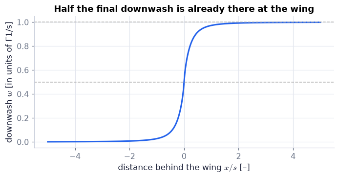

```
w far ahead, at the wing, far behind: [0.  0.5 1. ]
```

```python
xx = np.linspace(-5.0, 5.0, 401)                             # distance along the flight direction in spans (x > 0 is behind the wing)
wx = LL.downwash_along_x(x=xx, Gn=np.array([1.0]), s=1.0)    # downwash on the centre line for an elliptic loading with Γ1 = s = 1 (so w at the wing = 0.5)
fig, ax = plt.subplots(figsize=(6.2, 3.2))                   # one panel
ax.plot(xx, wx, color=COLORS["blue"])                        # the downwash
for lvl in (0.5, 1.0): ax.axhline(lvl, color="0.7", ls="--", lw=1)   # the value at the wing and twice it
ax.set(xlabel="distance behind the wing $x/s$ [–]", ylabel="downwash $w$ [in units of Γ1/s]", title="Half the final downwash is already there at the wing")   # labels
plt.show()                                                   # display
print("w far ahead, at the wing, far behind:", np.round(LL.downwash_along_x(x=np.array([-50.0, 0.0, 50.0]), Gn=np.array([1.0]), s=1.0), 3))   # 0.000, 0.500, 1.000
```

**What you see.** The downwash on the centre line from five spans ahead of the wing to five spans behind it.

**How to read it.** Far ahead the air is undisturbed. At the wing the downwash is 0.5 (in these units); far behind it is 1.0 — exactly twice. The wing meets air that has received half of the downward push it will eventually get.

**What would change if…** …you flew a second wing two spans behind the first? It would sit in nearly the full 2w — a tailplane works in strongly sinking air.

📝 **Note.** **N65 [B]** Outboard of the tips the trailing vortices push the air **up**. A bird flying just outboard and behind a neighbour's wing tip flies in rising air — the reason for formation flight.

> ⚠️ **slip #10 — the book prints** the “Λ-pattern” of migrating birds**; the correct form is** a V formation — the letter there is a shape, not the aspect ratio $\Lambda$.

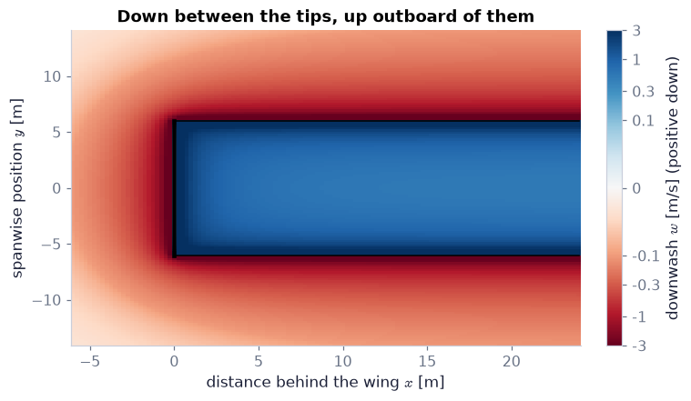

```
beside the wing, 2 m outboard of the tip (x = 0, y = 8 m): w = -0.341 m/s
on the centre line: w = 0.265 m/s at the wing, 0.539 m/s two spans behind it
```

```python
Xg, Yg = np.meshgrid(np.linspace(-6.0, 24.0, 121), np.linspace(-14.0, 14.0, 140))   # a patch of the wing's plane: x downstream, y along the span [m] (140 rows, so that no row lies exactly on a leg, where the formula is singular)
wmap = LL.horseshoe_downwash(x=Xg, y=Yg, Gamma=10.0, s=12.0) # downwash (positive down) of one horseshoe of span 12 m, Γ = 10 m²/s
from matplotlib.colors import SymLogNorm                    # a colour scale that is linear near zero and logarithmic beyond
fig, ax = plt.subplots(figsize=(6.8, 3.9))                   # one panel
norm = SymLogNorm(linthresh=0.1, vmin=-3.0, vmax=3.0)        # linear between ±0.1 m/s, logarithmic out to ±3 m/s: weak far field and strong field near the legs both keep some colour
pc = ax.pcolormesh(Xg, Yg, np.clip(wmap, -3.0, 3.0), cmap="RdBu", norm=norm, shading="auto")   # blue = air going down, red = air going up (values beyond ±3 m/s, right at the legs, are drawn as ±3)
ax.plot([0, 0], [-6, 6], color="k", lw=3)                    # the bound vortex (the wing)
for yt in (-6, 6): ax.plot([0, 24], [yt, yt], color="k", lw=1)   # the two trailing legs
fig.colorbar(pc, ax=ax, label="downwash $w$ [m/s] (positive down)", ticks=[-3, -1, -0.3, -0.1, 0, 0.1, 0.3, 1, 3], format="%g")   # colour scale with readable ticks
ax.set(xlabel="distance behind the wing $x$ [m]", ylabel="spanwise position $y$ [m]", title="Down between the tips, up outboard of them")   # labels
ax.grid(False)                                               # no grid lines over the colour map
plt.show()                                                   # display
print(f"beside the wing, 2 m outboard of the tip (x = 0, y = 8 m): w = {float(LL.horseshoe_downwash(x=0.0, y=8.0, Gamma=10.0, s=12.0)):.3f} m/s")   # −0.341: an upwash
print(f"on the centre line: w = {float(LL.horseshoe_downwash(x=0.0, y=0.0, Gamma=10.0, s=12.0)):.3f} m/s at the wing, {float(LL.horseshoe_downwash(x=24.0, y=0.0, Gamma=10.0, s=12.0)):.3f} m/s two spans behind it")   # the downwash roughly doubles downstream
```

**What you see.** A map of the vertical air motion in the plane of a horseshoe vortex, seen from above: the wing is the thick line on the left, the two legs trail to the right. The colour scale is stretched (linear within ±0.1 m/s, logarithmic beyond), so that the weak motion far from the vortex and the strong motion next to the legs are both visible.

**How to read it.** Blue (sinking air) fills the lane between the legs; red (rising air) lies outside them; the colour deepens toward the legs, where the speed grows like one over the distance. The printed value, −0.341 m/s two metres outboard of the tip, is an *upwash*: free lift for whoever flies there.

**What would change if…** …the neighbour flew directly behind instead? It would sit in the blue lane, in air sinking at up to twice the leader's own downwash (the second printed line).

📝 **Note.** **N66 [B]** **Ground effect.** A wall can be replaced by a mirror vortex of opposite strength (the method of images, Ch. 5 §5.7 and Ch. 6). An image horseshoe below the ground reduces the downwash at the wing's centre to $w=\dfrac{\Gamma}{\pi s}\Big[1-\dfrac1{1+(4h/s)^2}\Big]$ (ours), $h$ being the height above the ground.

```python
for h in (1.2, 3.0, 6.0):                                    # heights above the ground [m] for a 12 m span: s/10, s/4, s/2
    own = LL.horseshoe_downwash(x=0.0, y=0.0, Gamma=10.0, s=12.0)               # downwash of the wing's own horseshoe at its centre [m/s]
    image = LL.horseshoe_downwash(x=0.0, y=0.0, Gamma=-10.0, s=12.0, z=2*h)     # the mirror horseshoe (opposite Γ) lies 2h below: we are 2h above its plane
    print(f"h = {h:3.1f} m (h/s = {h/12:.2f}): factor = {LL.ground_effect_factor(h=h, s=12.0):.3f}; from the two horseshoes: {(own + image)/own:.3f}")   # 0.138, 0.5, 0.8 — twice each
```

```
h = 1.2 m (h/s = 0.10): factor = 0.138; from the two horseshoes: 0.138
h = 3.0 m (h/s = 0.25): factor = 0.500; from the two horseshoes: 0.500
h = 6.0 m (h/s = 0.50): factor = 0.800; from the two horseshoes: 0.800
```

**What does this show?** The closed form and the sum of two horseshoes agree. At a height of half a span the downwash is 80 % of its free-air value, at a quarter span 50 %, at a tenth of a span 14 %: less downwash means less induced drag (C10) — a wing just above the runway *floats*.

📝 **Note.** **N61 [C]** A parabolic loading $\Gamma=\Gamma_0\big(1-(2y/s)^2\big)$: the next cell compares its mid-span downwash with that of the elliptic loading of the same $\Gamma_0$; any $\Gamma(y)$ is handled by the series of C11.

```python
w_par = LL.downwash(y1=0.0, Gamma_fn=lambda y: 1 - (2*y/12.0)**2, s=12.0)   # mid-span downwash of a parabolic loading with Γ0 = 1 m²/s [m/s]
print(f"parabolic / elliptic mid-span downwash = {w_par/LL.downwash(y1=0.0, Gamma_fn=ell, s=12.0):.3f}")   # 1.273 = 4/π
```

```
parabolic / elliptic mid-span downwash = 1.273
```

**What would change if…** …a wing section flies in air that is sinking at $w$? Its lift tilts. C10.

### 🧩 Induced drag: $L=\displaystyle\int_{-s/2}^{s/2}\rho U\Gamma\,dy$, $D_i=\displaystyle\int_{-s/2}^{s/2}\rho w\Gamma\,dy$ (14.15) `C10`

*The question:* How can a wing have drag in a fluid with no friction?

#### The problem in plain words

Walk up a down escalator: you work just to stay level. A finite wing flies through air that its own wake is pushing downward. Relative to that air the wing is climbing a gentle slope, and the force on it, which is perpendicular to the air it actually meets, leans back by the slope angle. The backward part is a drag — with no friction anywhere. It is the price of lift on a wing with tips.

#### The idea

```
   U  (flight path)
─────────────────────►•
     ε  ╲             │ w  (downwash)
          ╲           ▼
   U_e      ╲►                    the air the strip actually meets is tilted down by ε

   dL ▲   ◄── dL_e is perpendicular to U_e, so it leans BACK by ε
      │  ╱
      │╱____► dD_i               its backward part is the induced drag
```

> 📎 **Primer — relative velocity as a vector subtraction.** `P350` · The wind a moving body feels is the air's velocity minus the body's own: $\mathbf U_r=\mathbf U-\mathbf V$. Its direction, not the direction of the true wind, decides where "lift" and "drag" point. (`np.hypot(x, y)` is the length of the vector $(x, y)$; `np.arctan2(y, x)` its angle in the right quadrant — primed in Ch. 2, P70.)

```python
Uv = np.array([50.0, 0.0]); wv = np.array([0.0, -1.0])           # the stream [m/s], and a 1 m/s downwash
Ue = Uv + wv                                                     # the air the strip meets
print(np.hypot(*Ue), np.degrees(np.arctan2(1.0, 50.0)))          # 50.01 m/s, tilted 1.15 degrees
```

```
50.00999900019995 1.1457628381751033
```

> 🔁 **Tools from earlier chapters used in this block** (one line each; the full primers are in the chapters named)
- **`np.arctan2`, `np.hypot`** — `np.hypot(x, y)` is the length of the vector (x, y) and `np.arctan2(y, x)` is its angle in the correct quadrant; here they give the speed and the tilt of the air a strip of the wing meets. *(Ch. 2, P70, P350)*
- **power of a force** — power is force times the speed in the direction of the force; here the induced drag times the flight speed is the rate at which energy is left behind in the wake. *(Ch. 4, P127)*

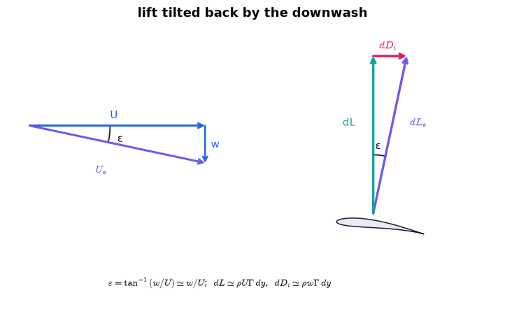

```python
fig = draw_force_triangle()                                  # the stream U, the downwash w, the tilted stream U_e, and the force normal to it split into dL and dD_i
plt.show()                                                   # display the sketch the derivation below refers to
```

#### 🧮 Derivation — Effective angle, the strip's forces, and lift and induced drag of the wing `D13` ★★ (Eq. 14.15: $L=\displaystyle\int_{-s/2}^{s/2}\rho U\Gamma\,dy,\ \ D_i=\displaystyle\int_{-s/2}^{s/2}\rho w\Gamma\,dy$)

**What we want to show.** Find what the downwash does to the force on each strip of the wing, and add the strips up.

**Assumptions.** w ≪ U (step 2); each strip behaves as a two-dimensional section (large aspect ratio; step 4).

**The plan.**

1. Tilt angle.
2. Effective angle.
3. Lift theorem in the tilted stream.
4. Resolve the force across and along the flight path.
5. Integrate along the span.

**Tools we use** (each explained before this point): relative velocity (P350) · small angles (P100, reminder) · resolving a force · the lift theorem per unit span (R04)

**We start from**

$$ \mathbf U_e=\mathbf U+\mathbf w,\qquad\mathbf w\perp\mathbf U $$

*In words:* The velocity triangle at a strip: the stream U along the flight path and the downwash w at right angles to it — the air the strip actually meets.

**Step 1 of 8 — Find the tilt of the local stream.**

$$ \tan\varepsilon=\dfrac wU\ \Rightarrow\ \varepsilon=\tan^{-1}\dfrac wU $$

- *Why we can do this:* U and w are the two legs of a right triangle; ε is the angle between the resultant and the flight path. (Slip #2: the book prints "tan" where the inverse tangent is meant.)
- *In words:* The air arrives tilted downward by ε.

**Step 2 of 8 — Use w ≪ U.**

$$ \varepsilon\simeq\dfrac wU,\qquad\alpha_e=\alpha-\varepsilon=\alpha-\dfrac wU\ \text{(14.14)} $$

- *Why we can do this:* For small angles tan⁻¹x ≃ x; the strip's chord makes the angle α with the flight path, so only α − ε with the air it meets.
- *In words:* The strip works at a smaller angle of attack than the wing is set at.

**Step 3 of 8 — Write the resultant speed.**

$$ U_e=\sqrt{U^2+w^2},\qquad U_e\cos\varepsilon=U,\qquad U_e\sin\varepsilon=w $$

- *Why we can do this:* Pythagoras and the definitions of cosine and sine in the same triangle — exact, no approximation.
- *In words:* The tilted stream's two components are exactly U and w.

**Step 4 of 8 — Apply the lift theorem to the strip.**

$$ dL_e=\rho U_e\Gamma\,dy,\quad\perp U_e $$

- *Why we can do this:* A two-dimensional section in a stream $U_e$ with circulation Γ feels ρ$U_e$Γ per unit span, at right angles to *that* stream ($L=\rho U\Gamma$ (6.62)).
- *In words:* The force on the strip is perpendicular to the tilted stream, not to the flight path.

**Step 5 of 8 — Resolve across the flight path.**

$$ dL=dL_e\cos\varepsilon=\rho\,U_e\cos\varepsilon\;\Gamma\,dy=\rho U\Gamma\,dy $$

- *Why we can do this:* The force leans back by ε; its component at right angles to the flight path is what we call lift. Use step 3.
- *In words:* The strip's lift is ρUΓ dy, as if there were no downwash.

**Step 6 of 8 — Resolve along the flight path.**

$$ dD_i=dL_e\sin\varepsilon=\rho\,U_e\sin\varepsilon\;\Gamma\,dy=\rho w\Gamma\,dy $$

- *Why we can do this:* The other component points backward: a drag. Use step 3 again.
- *In words:* The strip's induced drag is ρwΓ dy.

**Step 7 of 8 — Add the lift of all strips.**

$$ L=\displaystyle\int_{-s/2}^{s/2}\rho U\Gamma\,dy\ \text{(14.15), first member} $$

- *Why we can do this:* Γ varies along the span, so the sum is an integral.
- *In words:* The wing's lift is ρU times the area under Γ(y).

**Step 8 of 8 — Add the induced drag of all strips.**

$$ D_i=\displaystyle\int_{-s/2}^{s/2}\rho w\Gamma\,dy\ \text{(14.15), second member} $$

- *Why we can do this:* Both w and Γ vary with y.
- *In words:* The wing's induced drag is ρ times the span integral of downwash × circulation.

**Result**

$$ \alpha_e=\alpha-\dfrac wU\ \text{;}\ L=\displaystyle\int_{-s/2}^{s/2}\rho U\Gamma\,dy\ \text{,}\ D_i=\displaystyle\int_{-s/2}^{s/2}\rho w\Gamma\,dy $$

*In words:* U with Γ gives lift; w with Γ gives drag

**What it means.** Induced drag is the lift vector leaning back; it exists in a fluid with no friction, and its work rate $D_iU$ is the kinetic energy left in the lengthening wake. **Fails when:** w is not small compared with U, or the strip is not nearly two-dimensional (low aspect ratio, near the tips).

**Check it.** Units — (kg/m³)(m/s)(m²/s)(m) = N ✓. Limits — infinite span: no trailing vortices, w = 0, $D_i$ = 0. Number — U = 50, w = 1 m/s, Γ = 20 m²/s, ρ = 1.2, dy = 1 m: dL = 1200 N, d$D_i$ = 24 N, ratio 0.02 = ε.

📝 **Notes taught inside `D13`:** **N42 [B]** the induced angle $\varepsilon=\tan^{-1}(w/U)\simeq w/U$ (step 1) · **N43 [B]** the effective angle $\alpha_e=\alpha-\varepsilon=\alpha-\dfrac wU$ (14.14) (step 2) · **N44 [B]** the strip's forces $dL=\rho U\Gamma\,dy$ and $dD_i=\rho w\Gamma\,dy$ (steps 3–6).

> ⚠️ **Common confusion (traps in `D13`):** ε is tan⁻¹(w/U), not tan(w/U) (slip #2); $U_e\sin\varepsilon=w$ and $U_e\cos\varepsilon=U$ are exact — the only approximation is treating the flight path as the reference for "lift" and "drag" with a section law at $\alpha_e$; this drag is not friction.

> ⚠️ **slip #2 — the book prints** $\varepsilon=\tan\dfrac wU$**; the correct form is** $\varepsilon=\tan^{-1}\dfrac wU$ (the inverse tangent; for $w\ll U$ both are $\simeq w/U$).

#### ✏️ Tiny example: one strip by hand

$U$ = 50 m/s, downwash $w$ = 1 m/s, a strip of width 1 m carrying Γ = 20 m²/s, ρ = 1.2 kg/m³, geometric angle α = 5°.

1. Tilt: ε = $w/U$ = 0.02 rad = 1.15°.
2. Effective angle $\alpha_e=\alpha-\dfrac wU$ (14.14) = 5° − 1.15° = 3.85°.
3. Lift of the strip: $\rho U\Gamma\,dy$ = 1.2 × 50 × 20 × 1 = 1200 N.
4. Induced drag: $\rho w\Gamma\,dy$ = 1.2 × 1 × 20 × 1 = 24 N.
5. Ratio 24/1200 = 0.02 = ε: the drag is the lift times the tilt.

```python
sf_ = LL.strip_forces(Gamma=10.0, w=1.0, U=30.0, rho=1.225, dy=0.1)               # a strip 0.1 m wide carrying 10 m²/s in a 1 m/s downwash: small-angle forms
sx_ = LL.strip_forces(Gamma=10.0, w=1.0, U=30.0, rho=1.225, dy=0.1, exact=True)   # the same without the small-angle step
print(f"strip: dL = {sf_['dL']:.2f} N, dD_i = {sf_['dDi']:.3f} N, ε = {sf_['eps']:.4f} rad (exact: dL = {sx_['dL']:.2f}, dD_i = {sx_['dDi']:.3f})")   # 36.75, 1.225, 0.0333
W, s, rho, U = ac["W"], ac["s"], 1.225, ac["U_slow"]         # our aircraft at 30 m/s: weight [N], span [m], density [kg/m³], speed [m/s]
G1 = 4*W/(np.pi*s*rho*U)                                     # the elliptic loading that carries the weight: Γ1 from L = (πs/4)ρUΓ1 (derived in C13)
w_el = LL.elliptic_downwash(Gamma1=G1, s=s)                  # Eq. (14.24): its uniform downwash Γ1/2s [m/s]
eps_el = LL.induced_angle(w=w_el, U=U)                       # the tilt ε ≈ w/U [rad]
a_eff = LL.effective_angle(alpha=np.deg2rad(5.0), w=w_el, U=U)   # Eq. (14.14): the angle a strip set at 5° really works at [rad]
yy = np.linspace(-s/2, s/2, 4001)                            # stations along the span [m]
L_w, Di_w = LL.lift_and_induced_drag(y=yy, Gamma=LL.elliptic_circulation(y=yy, s=s, Gamma1=G1), w=w_el + 0*yy, rho=rho, U=U)   # Eq. (14.15): both integrals by the trapezoid rule
print(f"Γ1 = {G1:.2f} m²/s, w = {w_el:.3f} m/s, ε = {eps_el:.4f} rad = {np.degrees(eps_el):.2f}°, effective angle = {np.degrees(a_eff):.2f}° ({a_eff:.4f} rad)")   # 25.98, 1.083, 2.07°, 2.93°
print(f"L = {L_w:.0f} N, D_i = {Di_w:.1f} N = {100*Di_w/L_w:.1f} % of the lift")   # 9000 N, 324.8 N, 3.6 %
```

```
strip: dL = 36.75 N, dD_i = 1.225 N, ε = 0.0333 rad (exact: dL = 36.75, dD_i = 1.225)
```

```
Γ1 = 25.98 m²/s, w = 1.083 m/s, ε = 0.0361 rad = 2.07°, effective angle = 2.93° (0.0512 rad)
L = 9000 N, D_i = 324.8 N = 3.6 % of the lift
```

**What does the code above do?**

```python
G_, w_, U_, rho_, dy_ = 10.0, 1.0, 30.0, 1.225, 0.1          # circulation [m²/s], downwash [m/s], speed [m/s], density [kg/m³], strip width [m]
Ue = np.hypot(U_, w_)                                        # speed of the tilted stream [m/s]
eps = np.arctan2(w_, U_)                                     # its tilt [rad], exactly
dLe = rho_*Ue*G_*dy_                                         # lift theorem in the tilted stream [N], perpendicular to U_e
assert np.isclose(dLe*np.sin(eps), rho_*w_*G_*dy_)           # backward part = ρ w Γ dy exactly, because U_e sin ε = w
assert np.isclose(dLe*np.cos(eps), rho_*U_*G_*dy_)           # upward part = ρ U Γ dy exactly, because U_e cos ε = U
assert np.allclose([dLe*np.cos(eps), dLe*np.sin(eps)], [sx_["dL"], sx_["dDi"]])   # and the tested function returns these two numbers
print(f"dL_e = {dLe:.3f} N at ε = {np.degrees(eps):.3f}° → dL = {dLe*np.cos(eps):.3f} N, dD_i = {dLe*np.sin(eps):.4f} N")   # 36.770 N at 1.909° → 36.750, 1.2250
```

```
dL_e = 36.770 N at ε = 1.909° → dL = 36.750 N, dD_i = 1.2250 N
```

**What does the code above do?**

Both resolutions are **exact**: $U_e\sin\varepsilon=w$ and $U_e\cos\varepsilon=U$. Only calling them "lift" and "drag" relative to the flight path, with a section law at the reduced angle, is approximate.

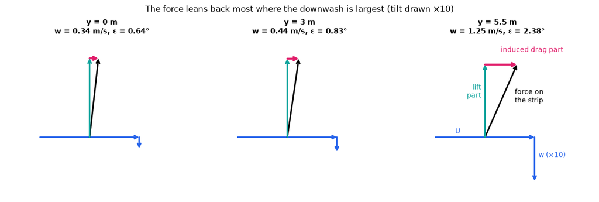

```python
rect = LL.solve_lifting_line(c=1.25, s=12.0, U=30.0, alpha=0.1, K=2*np.pi, N=32, rho=1.225)   # a rectangular wing (chord 1.25 m, span 12 m) at α = 0.1 rad = 5.7°; the solver is taught in C12
fig, axes = plt.subplots(1, 3, figsize=(11.0, 4.0))          # one force triangle per station
arrow = lambda ax, tail, head, col, lw=2.0: ax.annotate("", xy=head, xytext=tail, arrowprops=dict(arrowstyle="->", color=col, lw=lw, shrinkA=0, shrinkB=0))   # a helper: one arrow from tail to head
for ax, y1 in zip(axes, (0.0, 3.0, 5.5)):                    # mid-span, half-way out, near the tip [m]
    w1 = np.interp(y1, rect["y"], rect["w"])                 # downwash at this station [m/s]
    e10 = 10*w1/30.0                                         # the tilt ε = w/U, exaggerated ten times for the drawing [rad]
    tip = (0.5 + 0.8*np.sin(e10), 0.8*np.cos(e10))           # head of the force arrow: normal to the tilted stream
    arrow(ax, (0, 0), (1, 0), COLORS["blue"])                # the stream U
    arrow(ax, (1, 0), (1, -np.tan(e10)), COLORS["blue"])     # the downwash w (×10)
    arrow(ax, (0.5, 0), tip, "k")                            # the force on the strip, normal to the tilted stream
    arrow(ax, (0.5, 0), (0.5, tip[1]), COLORS["teal"])       # its lift part (normal to the flight path)
    arrow(ax, (0.5, tip[1]), tip, COLORS["rose"], 2.6)       # its induced-drag part (along the flight path)
    ax.set(xlim=(-0.35, 1.6), ylim=(-0.6, 1.0))              # the same window in the three panels
    ax.set_title(f"y = {y1:g} m\nw = {w1:.2f} m/s, ε = {np.degrees(w1/30.0):.2f}°", fontsize=10)   # readout on two lines
    ax.set_aspect("equal"); ax.axis("off")                   # true proportions, no axes
axl = axes[2]                                                # name the arrows once, in the panel where they are largest
axl.text(0.2, 0.04, "U", color=COLORS["blue"], fontsize=9)                                  # the stream
axl.text(1.04, -0.2, "w (×10)", color=COLORS["blue"], fontsize=9)                           # the downwash
axl.text(0.46, 0.4, "lift\npart", color=COLORS["teal"], fontsize=9, ha="right")             # the teal arrow
axl.text(0.66, 0.86, "induced drag part", color=COLORS["rose"], fontsize=9)                 # the rose arrow
axl.text(0.80, 0.35, "force on\nthe strip", color="k", fontsize=9)                          # the black arrow
fig.suptitle("The force leans back most where the downwash is largest (tilt drawn ×10)", fontsize=11)   # the message
plt.show()                                                   # display
```

**What you see.** The force triangle at three stations of a rectangular wing: stream and downwash (blue), the force on the strip (black), its lift part (teal) and its induced-drag part (rose). The tilt is drawn ten times too large; the arrows are named in the right-hand panel.

**How to read it.** On a rectangular wing the downwash is not uniform: it is larger near the tip than at mid-span, so the force leans back more there. The rose arrow is the induced drag of that strip.

**What would change if…** …the loading were elliptic? All three triangles would be identical: the downwash would be the same everywhere (C14).

📝 **Note.** **N45 [B]** Read $L=\int\rho U\Gamma\,dy$ and $D_i=\int\rho w\Gamma\,dy$ (14.15) as one rule used twice: $U$ with Γ gives a force normal to $U$; $w$ with Γ gives a force normal to $w$. With an infinite span there are no trailing vortices, $w=0$ and the drag vanishes. (The book's remark that this is the largest part of a wing's drag is tested in C15, N75.)

📝 **Note.** **N38 [B]** A second reading: the tip vortices get longer every second, so kinetic energy is fed into the wake at the rate $D_iU=\dfrac{d}{dt}(\text{wake kinetic energy})$ (stated, not derived). Power is force times speed (primed in Ch. 4, P127), so the induced drag equals the kinetic energy left behind *per metre flown*.

**A link backward (the book's own analogy).** Induced drag is to a wing what wave drag is to a ship (Ch. 7): the ship keeps lengthening a wave train behind it, the wing keeps lengthening a pair of vortices, and in both cases the energy fed into that pattern per metre travelled is a drag that needs no friction. The same bookkeeping — drag × speed = energy carried away — is how the drag of mountains on the atmosphere is counted when the air flowing over them radiates internal gravity waves.

```python
Gn_r = rect["Gn"]                                            # the sine coefficients of the rectangular wing's loading [m²/s] (C11–C12 explain them)
print(f"wake kinetic energy per metre = {LL.wake_kinetic_energy_per_length(Gn=Gn_r, s=12.0, rho=1.225):.3f} J/m; induced drag = {LL.induced_drag_from_series(Gn=Gn_r, rho=1.225):.3f} N")   # equal: 1 J/m = 1 N
print(f"one unit coefficient, ρ = 1: {LL.wake_kinetic_energy_per_length(Gn=np.array([1.0]), s=1.0, rho=1.0):.4f} and {LL.induced_drag_from_series(Gn=np.array([1.0]), rho=1.0):.4f} (π/8 = {np.pi/8:.4f})")   # 0.3927 three times
```

```
wake kinetic energy per metre = 74.494 J/m; induced drag = 74.494 N
one unit coefficient, ρ = 1: 0.3927 and 0.3927 (π/8 = 0.3927)
```

📝 **Note.** **N67 [C]** A tip vortex with a larger core holds less energy per metre, roughly $\propto\Gamma^2\big[\ln(s/\sigma)+\tfrac14\big]$ (ours) for a pair of Rankine vortices (solid-body core of radius σ, Ch. 3) a distance $s$ apart — one line:

```python
print([round(float(ch14.vortex_pair_energy_per_length(Gamma=14.17, s=9.42, sigma=sig, rho=1.225)), 1) for sig in (0.1, 0.3, 1.0)])   # energy per metre [J/m] for core radii 0.1, 0.3, 1 m: it falls as the core grows
```

```
[187.7, 144.7, 97.6]
```

#### 🎮 Interactive: How can there be drag without friction?

**Why interactive rather than a static figure:** building the wing from 1, 3, 7, 21 nested horseshoes and watching Γ(y) and w(y) settle onto smooth curves shows what the integral is; moving the station turns the local force triangle.

Start with the **Walkthrough**; the **Explain** tab works every number out with your settings, and the **Derivation** tab (where there is one) steps through the same derivation as above. Γ is the clockwise circulation in every readout; angles are shown in degrees and computed in radians.

**What to try:**

- Start with one horseshoe and step N up.
- Slide the station to the tip: what happens to the bars of the nearest filaments?
- Move outboard of the tip: which way does the air move?
- Lower the wing toward the ground and watch the downwash.

```python
show_viz("ch14", "downwash_induced_drag")   # full-width explainer; ⤢ Full screen for more room
```

🎮 Interactive 6/9 How can there be drag without friction? Open alone ↗

[interactive chart not shown]

**What would change if…** …Γ(y) is not given but has to be *found*? The downwash depends on Γ, and Γ depends on the downwash. We need a way to do the integral once and for all: C11.

### 🧩 The sine series and its downwash: $\Gamma=\displaystyle\sum_{n=1}^{\infty}\Gamma_n\sin(n\gamma)$ (14.18) ⇒ $w(y_1)=\dfrac{1}{2s}\displaystyle\sum_{n=1}^{\infty}n\,\Gamma_n\,\dfrac{\sin(n\gamma_1)}{\sin\gamma_1}$ (14.19, last member) `C11`

*The question:* The downwash integral is singular and awkward. Can it be done once, for every loading?

#### The problem in plain words

A violin string is fixed at both ends, and every shape it can take is a sum of sine waves that vanish at both ends. The circulation along a wing is "fixed" the same way: zero at both tips. Write it as a sum of sines of an angle that runs from 0 at one tip to π at the other, and the awkward integral for the downwash can be done for each sine separately — the answer is another sine, divided by sin γ.

#### The idea

Put a semicircle over the span. A point at the angle γ on it projects straight down to the spanwise position $y=-(s/2)\cos\gamma$. Equal steps in γ crowd toward the tips — exactly where Γ changes fastest.

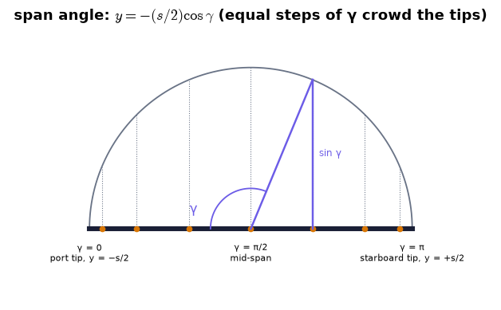

```python
fig = draw_span_semicircle()                                 # the span angle γ: a point of the span is the foot of a point on a semicircle of radius s/2
plt.show()                                                   # display
```

**What you see.** A semicircle of radius $s/2$ over the span; a point at the angle γ on it and its foot on the span.

**How to read it.** γ = 0 is the port tip, γ = 90° mid-span, γ = 180° the starboard tip. Equal steps in γ give short steps in $y$ near the tips and long ones in the middle.

**What would change if…** …you used $y$ itself? The downwash integral would keep its awkward $1/(y_1-y)$; in γ it becomes a known integral.

📝 **Note.** **N49 [B]** The span angle: $y=-(s/2)\cos\gamma$, $y_1=-(s/2)\cos\gamma_1$: γ = 0 at the port tip, π/2 at mid-span, π at the starboard tip.

> ⚠️ **Common confusion (trap T3):** this γ is an angle — not Chapter 5's sheet strength, not the ratio of specific heats.

```python
print(np.round(LL.span_angle(y=np.array([-6.0, 0.0, 3.0, 6.0]), s=12.0), 3))   # port tip, mid-span, half-way out, starboard tip of a 12 m span: 0, 1.571, 2.094, 3.142 rad (0°, 90°, 120°, 180°)
```

```
[0.    1.571 2.094 3.142]
```

> 📎 **Primer — half-range sine series.** `P346` · On 0 ≤ γ ≤ π any function that vanishes at both ends can be written as $\sum a_n\sin n\gamma$, and the sines are orthogonal there: $\int_0^\pi\sin n\gamma\,\sin m\gamma\,d\gamma=\tfrac\pi2$ if $n=m$ and 0 otherwise. (Full-period integrals of sines: Ch. 6, P151; keeping only the first N terms of such a series: Ch. 11, P275.)

```python
g = np.linspace(0, np.pi, 2001)                       # the half range 0…π
print(np.trapezoid(np.sin(2*g)*np.sin(3*g), g))       # 0: different sines
print(np.trapezoid(np.sin(3*g)**2, g), np.pi/2)       # 1.5708: the same sine
```

```
1.1102230246251565e-16
1.5707963267948966 1.5707963267948966
```

> 🔁 **Tools from earlier chapters used in this block** (one line each; the full primers are in the chapters named)
- **integrals of sines over a full period; Galerkin truncation** — the product of two different sine shapes integrates to zero over the full range and the square of one gives half the range, so an unknown curve written as a sum of a few fixed sine shapes can be found one amplitude at a time; here the curve is the loading Γ along the span. *(Ch. 6, P151, P275, P346)*
- **even and odd functions** — an even function has the same value at −y and y, an odd one changes sign; here a symmetric wing has an even loading, which keeps only the odd-numbered sine terms. *(Ch. 11, P261)*
- **substitution in an integral (change of variable)** — replace the integration variable by a new one and convert the differential and the limits as well; here y = −(s/2) cos γ turns integrals along the span into integrals over the span angle γ, with dy = (s/2) sin γ dγ. *(Ch. 3, P106)*
- **proof by induction; linear recurrences** — to prove a statement for every n, show it for the first cases and show that it carries over from the cases before n to n; a rule that gives each term from the two before it is a three-term recursion; here both are used on the family of integrals behind the downwash. *(Ch. 12, P306, P236, P347)*

📝 **Note.** **N50 [B]** The loading as a sine series: $\Gamma=\displaystyle\sum_{n=1}^{\infty}\Gamma_n\sin(n\gamma)$ (14.18). Every term vanishes at both tips; the numbers $\Gamma_n$ [m²/s] are the unknowns of the theory. Odd $n$ are symmetric about mid-span (even functions of $y$), even $n$ antisymmetric (odd functions).

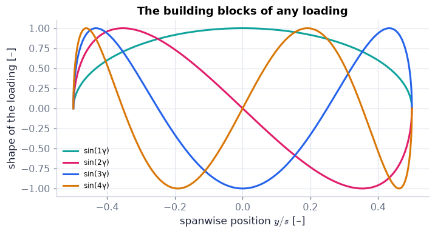

```python
gg = np.linspace(0, np.pi, 401)                              # span angle from port tip to starboard tip
yy1 = LL.span_position(gamma=gg, s=1.0)                      # the same as a position on a span of 1: y/s from −0.5 to 0.5
fig, ax = plt.subplots(figsize=(6.4, 3.4))                   # one panel
for n_, col in zip((1, 2, 3, 4), (COLORS["teal"], COLORS["rose"], COLORS["blue"], COLORS["amber"])):   # the first four shapes
    ax.plot(yy1, np.sin(n_*gg), color=col, label=f"sin({n_}γ)")   # one sine shape against the spanwise position
ax.set(xlabel="spanwise position $y/s$ [–]", ylabel="shape of the loading [–]", title="The building blocks of any loading")   # labels
ax.legend(fontsize=8); plt.show()                            # legend and display
```

**What you see.** The first four sine shapes plotted against the position along the span.

**How to read it.** $n$ = 1 is a half-ellipse (a circle squashed, since $\sin\gamma=\sqrt{1-(2y/s)^2}$). $n$ = 2 is antisymmetric: more lift on one wing than the other — a rolling wing. $n$ = 3 is symmetric with a dip in the middle, $n$ = 4 antisymmetric again. Every one is zero at both tips.

**What would change if…** …a wing is symmetric and flies straight? Only the odd shapes appear (C12 confirms: the even coefficients vanish).

#### 🧮 Derivation — The sine series inside the downwash integral `D14` ★★ (Eq. 14.13: $w(y_1)=\dfrac{1}{4\pi}\displaystyle\int_{-s/2}^{s/2}\dfrac{d\Gamma}{dy}\,\dfrac{dy}{(y_1-y)}$)

**What we want to show.** Rewrite the downwash integral for a loading given as a sine series, so that the integral can be done term by term. This is where the book's one consequential misprint sits.

**Assumptions.** The series may be differentiated and integrated term by term (true for the smooth loadings considered); the integral is a principal value.

**The plan.**

1. Change the variable from y to γ.
2. Differentiate the series.
3. Rewrite the denominator.
4. Assemble.
5. Exchange sum and integral.

**Tools we use** (each explained before this point): substitution in an integral (P106, reminder) · the half-range sine series (P346) · term-by-term differentiation (gloss)

**We start from**

$$ \begin{array}{l}w(y_1)=\dfrac{1}{4\pi}\displaystyle\int_{-s/2}^{s/2}\dfrac{d\Gamma}{dy}\,\dfrac{dy}{(y_1-y)}\ \text{(14.13) with}\ y=-(s/2)\cos\gamma\ \text{and}\ \Gamma=\displaystyle\sum_{n=1}^\infty\Gamma_n\sin(n\gamma) \\ \text{(14.18)}\end{array} $$

*In words:* The downwash of a loading written as sines of the span angle

**Step 1 of 7 — Change the variable.**

$$ y=-\dfrac s2\cos\gamma\ \Rightarrow\ dy=\dfrac s2\sin\gamma\,d\gamma $$

- *Why we can do this:* Differentiate; d(cos γ) = −sin γ dγ and the two minus signs cancel. γ grows with y.
- *In words:* A step along the span, in terms of a step in the angle.

**Step 2 of 7 — Convert the limits.**

$$ y=-\dfrac s2\leftrightarrow\gamma=0,\qquad y=+\dfrac s2\leftrightarrow\gamma=\pi $$

- *Why we can do this:* cos 0 = 1 and cos π = −1.
- *In words:* Port tip to starboard tip is γ from 0 to π.

**Step 3 of 7 — Rewrite the numerator.**

$$ \dfrac{d\Gamma}{dy}\,dy=d\Gamma=\dfrac{d\Gamma}{d\gamma}\,d\gamma $$

- *Why we can do this:* Both are the change of Γ over the same small step; the factor dy/dγ of step 1 cancels inside it.
- *In words:* The shed strength does not care which coordinate we use.

**Step 4 of 7 — Differentiate the series term by term.**

$$ \dfrac{d\Gamma}{d\gamma}=\displaystyle\sum_{n=1}^{\infty}n\,\Gamma_n\cos(n\gamma) $$

- *Why we can do this:* d sin(nγ)/dγ = n cos(nγ); a convergent series of smooth terms may be differentiated term by term here.
- *In words:* Each sine sheds a cosine-shaped sheet, n times stronger for the n-th term.

**Step 5 of 7 — Rewrite the denominator.**

$$ y_1-y=-\dfrac s2\cos\gamma_1+\dfrac s2\cos\gamma=\dfrac s2\,(\cos\gamma-\cos\gamma_1) $$

- *Why we can do this:* Insert the definitions of y and y₁. **Order matters:** cos γ − cos γ₁. Slip #1: the book prints cos γ₁ − cos γ, which would flip the sign of the downwash.
- *In words:* The distance between filament and station, in the angles.

**Step 6 of 7 — Assemble the integral.**

$$ w(y_1)=\dfrac{1}{2\pi s}\displaystyle\int_0^\pi\sum_{n=1}^{\infty}n\,\Gamma_n\,\dfrac{\cos(n\gamma)\,d\gamma}{\cos\gamma-\cos\gamma_1} $$

- *Why we can do this:* Put steps 2–5 into the downwash integral of the Start: 1/(4π) ÷ (s/2) = 1/(2πs). This is the first member of the book's three-member downwash equation, with the denominator corrected.
- *In words:* The downwash as one integral over the span angle.

**Step 7 of 7 — Exchange the sum and the integral.**

$$ w(y_1)=\dfrac{1}{2\pi s}\displaystyle\sum_{n=1}^{\infty}n\,\Gamma_n\int_0^\pi\dfrac{\cos(n\gamma)\,d\gamma}{\cos\gamma-\cos\gamma_1} $$

- *Why we can do this:* The integral of a sum is the sum of the integrals; the $\Gamma_n$ are constants. This is the book's second member, corrected.
- *In words:* One standard integral per sine — the same for every wing.

**Result**

$$ w(y_1)=\dfrac{1}{2\pi s}\displaystyle\sum_{n=1}^{\infty}n\,\Gamma_n\int_0^\pi\dfrac{\cos(n\gamma)\,d\gamma}{\cos\gamma-\cos\gamma_1} $$

*In words:* The downwash needs only the integrals $I_n(\gamma_1)$ of D15

**What it means.** The change of variable crowds the stations toward the tips, where Γ changes fastest, and turns the awkward 1/(y₁ − y) into a form whose integral is known. **Fails when:** the loading has a jump (a deflected flap's edge): the series then converges slowly.

**Check it.** Units — (m²/s)/m = m/s ✓. Sign — for the elliptic loading (n = 1 only, Γ₁ > 0) the integral is +π (D15), so w = +Γ₁/2s: downward, as it must be behind a lifting wing; the printed denominator gives −Γ₁/2s. Code — `LL.downwash_series(…, printed_middle=True)` returns the negative of the quadrature of the downwash integral.

> ⚠️ **Common confusion (traps in `D14`):** The order in the denominator (slip #1); dy = (s/2) sin γ dγ cancels inside dΓ — it must not be inserted a second time; the limits are 0 to π, not −π to π.

> ⚠️ **slip #1 — the book prints** the first two members of its three-member downwash equation (14.19) with the denominator $\cos\gamma_1-\cos\gamma$, $w(y_1)=\dfrac1{2\pi s}\displaystyle\int_0^\pi\sum n\Gamma_n\dfrac{\cos(n\gamma)\,d\gamma}{\cos\gamma_1-\cos\gamma}$**; the correct form is** $\cos\gamma-\cos\gamma_1$ (step 5 above). The last member, $w(y_1)=\dfrac1{2s}\sum n\Gamma_n\dfrac{\sin(n\gamma_1)}{\sin\gamma_1}$, and everything the book builds on it are right.

```python
w_last = LL.downwash_series(Gn=np.array([1.0]), gamma1=np.pi/2, s=1.0)                         # last member of (14.19) for the elliptic loading (Γ1 = s = 1), at mid-span
w_printed = LL.downwash_series(Gn=np.array([1.0]), gamma1=np.pi/2, s=1.0, printed_middle=True)  # the middle member evaluated as the book prints it
w_quad = LL.downwash(y1=0.0, Gamma_fn=lambda y: np.sqrt(1 - 4*y**2), s=1.0)                    # direct quadrature of the downwash integral (14.13)
print(f"last member: {w_last:+.3f}   printed middle member: {w_printed:+.3f}   direct integral: {w_quad:+.3f}   [m/s]")   # +0.5, −0.5, +0.5
```

```
last member: +0.500   printed middle member: -0.500   direct integral: +0.500   [m/s]
```

**What does this show?** The corrected series and the direct integral agree at +0.5 (downward). The printed form gives −0.5: it would make the air *rise* behind a lifting wing.

> 📎 **Primer — product-to-sum identity and a three-term recursion.** `P347` · $\cos(n+1)\gamma+\cos(n-1)\gamma=2\cos\gamma\,\cos n\gamma$. A rule that gives each term of a sequence from the two before it, $I_{n+1}=2cI_n-I_{n-1}$, fixes the whole sequence once two starting values are known (linear recurrences: Ch. 10, P236; proof by induction — true for the first cases, and true for the next whenever true for the previous ones: Ch. 12, P306).

```python
cg, I = np.cos(1.0), [0.0, np.pi]                     # cg = cos(gamma_1) with gamma_1 = 1 rad; the starting values I_0 and I_1
for n in range(1, 4): I.append(2*cg*I[n] - I[n-1])    # the recursion
print(I[3], np.pi*np.sin(3*1.0)/np.sin(1.0))          # both 0.5269
```

```
0.5268649645675239 0.5268649645675232
```

> 📎 **Primer — the sum of two cotangents and the product of two sines.** `P352` · Two identities the next derivation uses once each. Over a common denominator, $\cot A+\cot B=\dfrac{\cos A\sin B+\cos B\sin A}{\sin A\sin B}=\dfrac{\sin(A+B)}{\sin A\,\sin B}$ (the numerator is the addition formula for the sine). And subtracting $\cos(A+B)=\cos A\cos B-\sin A\sin B$ from $\cos(A-B)=\cos A\cos B+\sin A\sin B$ gives $2\sin A\sin B=\cos(A-B)-\cos(A+B)$. One more reminder: $\dfrac{d}{d\gamma}\ln\lvert\sin u\rvert=\dfrac{du}{d\gamma}\cot u$, the chain rule applied to a logarithm (Ch. 1, P49).

```python
A, B = 0.7, 0.2                                                          # two angles [rad]
print(1/np.tan(A) + 1/np.tan(B), np.sin(A + B)/(np.sin(A)*np.sin(B)))    # both 6.120: cot A + cot B = sin(A + B)/(sin A sin B)
print(2*np.sin(A)*np.sin(B), np.cos(A - B) - np.cos(A + B))              # both 0.256: 2 sin A sin B = cos(A − B) − cos(A + B)
```

```
6.120396707713573 6.120396707713573
0.25597259361970826 0.25597259361970826
```

#### 🧮 Derivation — Glauert's integral, and the downwash of the series `D15` ★★★ (Eq. 14.19: $w(y_1)=\dfrac{1}{2s}\displaystyle\sum_{n=1}^{\infty}n\,\Gamma_n\,\dfrac{\sin(n\gamma_1)}{\sin\gamma_1}$)

**What we want to show.** Evaluate the one integral the whole theory rests on. The book says only "the final equality comes from evaluating the integral".

**Assumptions.** 0 < γ₁ < π; the integral is taken as a principal value.

**The plan.**

1. Find I₀ and I₁ directly.
2. Use a trigonometric identity to link three consecutive $I_n$.
3. Guess a closed form and show that it obeys the same link and the same two starting values.
4. Conclude by induction.

**Tools we use** (each explained before this point): principal value (P344) · product-to-sum identity and three-term recursion (P347) · proof by induction (P306, reminder) · l'Hôpital's rule (P343) for the tips · the derivative of ln|sin u| by the chain rule (P49, reminder) · the sum of two cotangents and the product of two sines (P352)

**We start from**

$$ I_n(\gamma_1)\equiv\displaystyle\int_0^\pi\dfrac{\cos(n\gamma)\,d\gamma}{\cos\gamma-\cos\gamma_1}\ \text{(principal value), 0 < γ₁ < π} $$

*In words:* The integral left over from D14, one for each n

**Step 1 of 14 — Propose an antiderivative for n = 0.**

$$ F(\gamma)\equiv\dfrac{1}{\sin\gamma_1}\ln\left\lvert\dfrac{\sin A}{\sin B}\right\rvert,\qquad A\equiv\dfrac{\gamma_1+\gamma}2,\quad B\equiv\dfrac{\gamma_1-\gamma}2 $$

- *Why we can do this:* A candidate only: steps 2–4 differentiate it and show that its slope is the integrand. A logarithm is the natural guess because the integrand behaves like 1/(γ − γ₁) near the singular point, and the integral of 1/x is ln|x|.
- *In words:* A logarithm that blows up at γ = γ₁, like the integrand.

**Step 2 of 14 — Differentiate the logarithm.**

$$ \dfrac{dF}{d\gamma}=\dfrac{1}{\sin\gamma_1}\Big[\tfrac12\cot A+\tfrac12\cot B\Big] $$

- *Why we can do this:* ln|sin A / sin B| = ln|sin A| − ln|sin B|, and by the chain rule d/dγ ln|sin u| = u′·cos u/sin u = u′ cot u. Here dA/dγ = +½ and dB/dγ = −½; the second logarithm carries a minus sign of its own, so both cotangents enter with +½.
- *In words:* The slope of the candidate is half the sum of two cotangents.

**Step 3 of 14 — Add the two cotangents.**

$$ \cot A+\cot B=\dfrac{\cos A\sin B+\cos B\sin A}{\sin A\,\sin B}=\dfrac{\sin(A+B)}{\sin A\,\sin B}=\dfrac{\sin\gamma_1}{\sin A\,\sin B} $$

- *Why we can do this:* Put the two fractions over the common denominator sin A sin B; the numerator is the addition formula for sin(A + B), and A + B = γ₁ (primer P352 above).
- *In words:* The sum carries sin γ₁ on top — the same factor the candidate has underneath, so the two will cancel.

**Step 4 of 14 — Turn the product of sines into a difference of cosines.**

$$ 2\sin A\sin B=\cos(A-B)-\cos(A+B)=\cos\gamma-\cos\gamma_1\ \ \Longrightarrow\ \ \dfrac{dF}{d\gamma}=\dfrac{1}{2\sin A\sin B}=\dfrac{1}{\cos\gamma-\cos\gamma_1} $$

- *Why we can do this:* The product-to-sum identity for two sines (primer P352 above) with A − B = γ and A + B = γ₁; in step 2 the factor sin γ₁ of step 3 cancels the 1/sin γ₁ in front. The slope of F is the integrand, so F is an antiderivative: $\displaystyle\int\dfrac{d\gamma}{\cos\gamma-\cos\gamma_1}=F(\gamma)$.
- *In words:* The guess is confirmed: differentiating it gives back exactly the integrand.

**Step 5 of 14 — Cut out a symmetric gap.**

$$ I_0=\displaystyle\lim_{\epsilon\to0}\Big[\int_0^{\gamma_1-\epsilon}+\int_{\gamma_1+\epsilon}^{\pi}\Big]\dfrac{d\gamma}{\cos\gamma-\cos\gamma_1} $$

- *Why we can do this:* The definition of the principal value (P344): the infinite areas on the two sides have opposite signs and must be removed evenly.
- *In words:* Approach the singular point equally from both sides.

**Step 6 of 14 — Evaluate I₀.**

$$ I_0=\dfrac{1}{\sin\gamma_1}\displaystyle\lim_{\epsilon\to0}\ln\dfrac{\sin(\gamma_1-\epsilon/2)}{\sin(\gamma_1+\epsilon/2)}=0 $$

- *Why we can do this:* Insert the limits in step 1: the end points give ln 1 = 0 (at γ = π both sines equal cos(γ₁/2)); the two logarithms of sin(ε/2) cancel.
- *In words:* With no cosine on top, the two sides cancel exactly.

**Step 7 of 14 — Evaluate I₁.**

$$ I_1=\displaystyle\int_0^\pi\dfrac{(\cos\gamma-\cos\gamma_1)+\cos\gamma_1}{\cos\gamma-\cos\gamma_1}\,d\gamma=\pi+\cos\gamma_1\,I_0=\pi $$

- *Why we can do this:* Add and subtract cos γ₁ in the numerator; the first part is the integral of 1 over (0, π), the second is a constant times I₀ = 0.
- *In words:* The first non-trivial integral is π, whatever γ₁ is.

**Step 8 of 14 — Recall the product-to-sum identity.**

$$ \cos(n+1)\gamma+\cos(n-1)\gamma=2\cos\gamma\,\cos n\gamma $$

- *Why we can do this:* Add the expansions of cos(nγ ± γ); the sine terms cancel (P347). It ties three consecutive numerators together.
- *In words:* Two neighbouring cosines add up to the middle one times 2 cos γ.

**Step 9 of 14 — Turn it into a recursion.**

$$ I_{n+1}+I_{n-1}=2\displaystyle\int_0^\pi\cos n\gamma\,d\gamma+2\cos\gamma_1\,I_n=2\cos\gamma_1\,I_n\quad(n\ge1) $$

- *Why we can do this:* Divide the identity by (cos γ − cos γ₁), integrate, and split 2 cos γ as in step 7; the integral of cos nγ over (0, π) vanishes for n ≥ 1.
- *In words:* Each $I_n$ follows from the two before it.

**Step 10 of 14 — Propose a closed form.**

$$ S_n\equiv\pi\,\dfrac{\sin n\gamma_1}{\sin\gamma_1}:\qquad S_0=0,\quad S_1=\pi $$

- *Why we can do this:* A guess suggested by the first few values; it matches both starting values of steps 6 and 7.
- *In words:* A candidate that starts right.

**Step 11 of 14 — Show the candidate obeys the recursion.**

$$ S_{n+1}+S_{n-1}=\dfrac{\pi}{\sin\gamma_1}\big[\sin(n+1)\gamma_1+\sin(n-1)\gamma_1\big]=2\cos\gamma_1\,S_n $$

- *Why we can do this:* The companion identity sin(A + B) + sin(A − B) = 2 sin A cos B with A = nγ₁, B = γ₁.
- *In words:* The candidate satisfies the same three-term rule.

**Step 12 of 14 — Conclude by induction.**

$$ I_n=\pi\,\dfrac{\sin n\gamma_1}{\sin\gamma_1}\quad\text{for all }n\ge0 $$

- *Why we can do this:* Two sequences with the same two starting values and the same rule for each next term are equal term by term (P306).
- *In words:* Glauert's integral.

**Step 13 of 14 — Insert into D14's result.**

$$ \begin{array}{l}w(y_1)=\dfrac{1}{2\pi s}\displaystyle\sum_{n=1}^{\infty}n\Gamma_n\,\pi\dfrac{\sin n\gamma_1}{\sin\gamma_1}=\dfrac{1}{2s}\sum_{n=1}^{\infty}n\,\Gamma_n\,\dfrac{\sin(n\gamma_1)}{\sin\gamma_1}\ \text{(14.19), last} \\ \text{member}\end{array} $$

- *Why we can do this:* Substitute step 12 for each integral; π cancels.
- *In words:* The downwash of a sine series is another sine series, divided by sin γ₁.

**Step 14 of 14 — Check the tips.**

$$ \displaystyle\lim_{\gamma_1\to0}\dfrac{\sin n\gamma_1}{\sin\gamma_1}=n,\qquad\lim_{\gamma_1\to\pi}\dfrac{\sin n\gamma_1}{\sin\gamma_1}=(-1)^{n+1}n $$

- *Why we can do this:* Both are 0/0; l'Hôpital's rule gives n cos(nγ₁)/cos γ₁ at the two ends (P343).
- *In words:* Each term stays finite at the tips, but grows like n² — a hint that the series converges slowly there.

**Result**

$$ \begin{array}{l}\displaystyle\int_0^\pi\dfrac{\cos n\gamma\,d\gamma}{\cos\gamma-\cos\gamma_1}=\pi\,\dfrac{\sin n\gamma_1}{\sin\gamma_1}\ \text{, hence} \\ w(y_1)=\dfrac{1}{2s}\displaystyle\sum_{n=1}^{\infty}n\,\Gamma_n\,\dfrac{\sin(n\gamma_1)}{\sin\gamma_1}\end{array} $$

*In words:* The singular integral, done once and for all

**What it means.** Every sine shape of the loading produces a downwash of the same sine shape divided by sin γ — so a single sine (the ellipse) gives a uniform downwash, and higher sines give more downwash toward the tips. **Fails when:** γ₁ is exactly 0 or π (use step 14), which is why collocation stations avoid the tips.

**Check it.** Units — the integral is dimensionless; w in m/s ✓. Limits — n = 1: w = Γ₁/2s, the same at every station. Number — γ₁ = 60°: I₀ … I₄ = 0, π, π, 0, −π; quadrature with the singular part subtracted gives the same to 15 digits.

```python
import sympy as sp                                              # symbolic algebra
g, g1 = sp.symbols("gamma gamma_1", positive=True)              # span angle of the filament and of the station
n = sp.symbols("n", integer=True, positive=True)                # index of the sine term
ident = sp.cos((n + 1)*g) + sp.cos((n - 1)*g) - 2*sp.cos(g)*sp.cos(n*g)        # step 8: product-to-sum identity
assert sp.simplify(sp.expand_trig(ident)) == 0                  # the identity holds for every n and gamma
S = lambda k: sp.pi*sp.sin(k*g1)/sp.sin(g1)                     # step 10: the candidate closed form
rec = S(n + 1) + S(n - 1) - 2*sp.cos(g1)*S(n)                   # step 11: does it obey the recursion?
assert sp.simplify(sp.expand_trig(rec)) == 0                    # yes: the closed form satisfies the recursion
assert S(0) == 0 and sp.simplify(S(1) - sp.pi) == 0             # steps 6-7: the two starting values match
F_left = sp.log(sp.sin((g1 + g)/2)/sp.sin((g1 - g)/2))/sp.sin(g1)         # steps 1-4: the antiderivative for n = 0 on the left of the singular point (gamma < gamma_1)
F_right = sp.log(sp.sin((g1 + g)/2)/sp.sin((g - g1)/2))/sp.sin(g1)        # the same on the right (gamma > gamma_1), where the absolute value flips the sign inside the second sine
for F0 in (F_left, F_right):                                    # on both sides …
    assert sp.simplify(sp.diff(F0, g) - 1/(sp.cos(g) - sp.cos(g1))) == 0   # … its slope is the integrand (sp.diff differentiates)
eps = sp.symbols("epsilon", positive=True)                      # half-width of the gap cut out round gamma_1 (step 5)
I0_gap = (F_left.subs(g, g1 - eps) - F_left.subs(g, 0)) + (F_right.subs(g, sp.pi) - F_right.subs(g, g1 + eps))   # step 6: the two pieces of I_0 with the gap left open
assert sp.simplify(sp.limit(I0_gap, eps, 0)) == 0               # closing the gap evenly gives I_0 = 0
X, X1 = sp.symbols("X X_1")                                     # X = cos(gamma), X1 = cos(gamma_1)
for k in range(1, 6):                                           # direct evaluation for n = 1..5
    Tk = sp.chebyshevt(k, X)                                    # cos(k gamma) is a polynomial T_k in cos(gamma)
    q = sp.cancel((Tk - Tk.subs(X, X1))/(X - X1))               # the singular factor divides out exactly
    Ik = sp.integrate(q.subs(X, sp.cos(g)), (g, 0, sp.pi))      # ordinary integral; the remainder is cos(k g1)*I_0 = 0
    assert sp.simplify(Ik.subs(X1, sp.cos(g1)) - sp.pi*sp.chebyshevu(k - 1, sp.cos(g1))) == 0   # = pi sin(k g1)/sin(g1)
print(sp.limit(sp.sin(3*g1)/sp.sin(g1), g1, 0))                 # step 14: the tip value is n (here 3)
```

```
3
```

📝 **Notes taught inside `D15`:** **N51 [B]** Glauert's integral $\displaystyle\int_0^\pi\dfrac{\cos n\gamma\,d\gamma}{\cos\gamma-\cos\gamma_1}=\pi\,\dfrac{\sin n\gamma_1}{\sin\gamma_1}$ (not in the book — ours, standard: the book says only that the last equality comes from evaluating the integral).

**Five sympy functions in the check above.** `sp.diff(F, g)` differentiates and `sp.limit(expr, eps, 0)` takes a limit. `sp.chebyshevt(k, X)` is the polynomial $T_k$ for which $\cos k\gamma=T_k(\cos\gamma)$ — for example $T_2(X)=2X^2-1$, the double-angle formula. `sp.chebyshevu(k-1, X)` is its companion $U_{k-1}$, for which $\dfrac{\sin k\gamma}{\sin\gamma}=U_{k-1}(\cos\gamma)$. `sp.cancel` divides a fraction of polynomials out exactly. Writing the numerator as a polynomial in $X=\cos\gamma$ lets the factor $X-X_1$ cancel, so that what is left is an ordinary integral with no singular point.

> ⚠️ **Common confusion (traps in `D15`):** I₀ = 0 holds only as a principal value; the recursion needs **two** starting values; showing that the candidate satisfies the recursion *is* the proof — no further integration is needed; the printed form of the first two members has the opposite sign (slip #1).

#### ✏️ Tiny example: two sines by hand

Γ₁ = 12 and Γ₃ = 1 m²/s on a span $s$ = 12 m.

1. Mid-span, γ₁ = 90°: sin γ₁ = 1, sin 3γ₁ = −1, so Γ = 12 − 1 = 11 m²/s.
2. Downwash there from $w(y_1)=\dfrac1{2s}\sum n\Gamma_n\dfrac{\sin(n\gamma_1)}{\sin\gamma_1}$ (14.19): (1/24)[1 × 12 × 1 + 3 × 1 × (−1)] = 9/24 = 0.375 m/s.
3. Near the port tip, γ₁ = 30° ($y_1$ = −5.2 m): sin γ₁ = 0.5, sin 3γ₁ = 1, Γ = 6 + 1 = 7 m²/s.
4. Downwash there: (1/24)[12 × 0.5/0.5 + 3 × 1 × 1/0.5] = (12 + 6)/24 = 0.75 m/s.
5. The $n$ = 1 term alone gives 0.5 m/s everywhere; the small Γ₃ lowers the downwash in the middle and raises it by half toward the tips.

```python
Gn2 = np.array([12.0, 0.0, 1.0])                             # the coefficients of the hand example: Γ1 = 12, Γ2 = 0, Γ3 = 1 [m²/s]
for g1 in (np.pi/2, np.pi/6):                                # mid-span (90°) and near the port tip (30°)
    print(f"γ1 = {np.degrees(g1):.0f}° ({g1:.3f} rad): Γ = {LL.circulation_series(Gn=Gn2, gamma=g1):.1f} m²/s, w = {LL.downwash_series(Gn=Gn2, gamma1=g1, s=12.0):.3f} m/s")   # 11 and 0.375; 7 and 0.75
print("Glauert's integral at γ1 = 60°, n = 0…4, by quadrature:", np.round([LL.glauert_integral(n=n, gamma1=np.pi/3, method="quad") for n in range(5)], 6))     # 0, π, π, 0, −π
print("                               the closed form:        ", np.round([LL.glauert_integral(n=n, gamma1=np.pi/3, method="closed") for n in range(5)], 6))   # the same
```

```
γ1 = 90° (1.571 rad): Γ = 11.0 m²/s, w = 0.375 m/s
γ1 = 30° (0.524 rad): Γ = 7.0 m²/s, w = 0.750 m/s
Glauert's integral at γ1 = 60°, n = 0…4, by quadrature: [ 0.      3.1416  3.1416  0.     -3.1416]
                               the closed form:         [ 0.      3.1416  3.1416  0.     -3.1416]
```

**What does the code above do?**

1. `LL.circulation_series` is $\Gamma=\sum\Gamma_n\sin(n\gamma)$ (14.18) and `LL.downwash_series` its downwash $w(y_1)=\dfrac1{2s}\sum n\Gamma_n\dfrac{\sin(n\gamma_1)}{\sin\gamma_1}$ (14.19): the hand example's 11 m²/s and 0.375 m/s at mid-span, 7 m²/s and 0.75 m/s near the tip.
2. `LL.glauert_integral` evaluates the integral of the derivation numerically (`"quad"`, the singular part subtracted) and by the closed form $\pi\sin n\gamma_1/\sin\gamma_1$: 0, π, π, 0, −π for $n$ = 0 … 4 at γ₁ = 60°.
3. Both routes agree to the digits shown.

```python
gam_of = lambda y: np.arccos(-2*y/12.0)                      # span angle of a station y on a 12 m span
Gfn = lambda y: 12*np.sin(gam_of(y)) + np.sin(3*gam_of(y))   # the two-sine loading as a plain function of y [m²/s]
y_test = np.array([-5.0, -2.0, 0.0, 3.0, 5.5])               # five stations [m]
w_quad5 = np.array([LL.downwash(y1=y1, Gamma_fn=Gfn, s=12.0) for y1 in y_test])   # direct principal-value integral, Eq. (14.13)
w_ser5 = LL.downwash_series(Gn=Gn2, gamma1=LL.span_angle(y=y_test, s=12.0), s=12.0)   # the series, Eq. (14.19)
assert np.allclose(w_quad5, w_ser5, rtol=1e-6)               # same numbers → the series is the integral, done once
print(np.round(w_quad5, 4))                                  # the downwash at the five stations [m/s]
```

```
[0.7222 0.4306 0.375  0.5    0.7951]
```

**What does the code above do?**

The loading of the hand example is handed to the quadrature of the original integral as a plain function of $y$; the result equals the sine-series formula at all five stations.

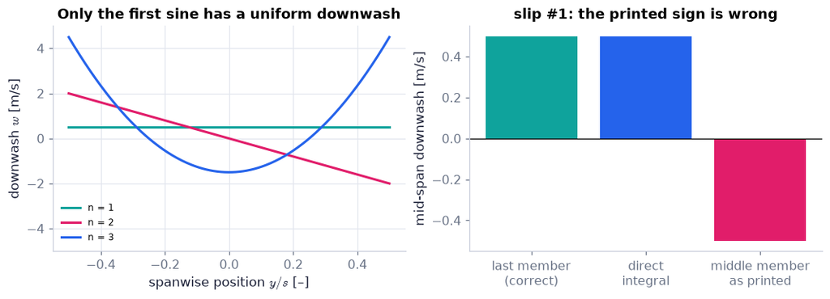

```python
g_in = np.linspace(0.02, np.pi - 0.02, 400)                  # span angles, staying clear of the tips
fig, (axm, axb) = plt.subplots(1, 2, figsize=(9.6, 3.4))     # left: downwash of single modes; right: the sign check
for n_, col in zip((1, 2, 3), (COLORS["teal"], COLORS["rose"], COLORS["blue"])):   # three single-sine loadings
    Gn_one = np.zeros(n_); Gn_one[-1] = 1.0                  # only Γ_n = 1 m²/s
    axm.plot(LL.span_position(gamma=g_in, s=1.0), LL.downwash_series(Gn=Gn_one, gamma1=g_in, s=1.0), color=col, label=f"n = {n_}")   # its downwash along the span (s = 1 m)
axm.set(xlabel="spanwise position $y/s$ [–]", ylabel="downwash $w$ [m/s]", ylim=(-5, 5), title="Only the first sine has a uniform downwash")   # labels
axm.legend(fontsize=8)                                       # which curve is which
axb.bar(["last member\n(correct)", "direct\nintegral", "middle member\nas printed"], [w_last, w_quad, w_printed], color=[COLORS["teal"], COLORS["blue"], COLORS["rose"]])   # the three numbers of the slip check
axb.axhline(0, color="k", lw=0.8)                            # zero line
axb.grid(False)                                              # no grid lines across the bars
axb.set(ylabel="mid-span downwash [m/s]", title="slip #1: the printed sign is wrong")   # labels
plt.show()                                                   # display
```

**What you see.** Left: the downwash produced by the loadings sin γ, sin 2γ and sin 3γ alone. Right: three bars — the corrected series, the direct integral, and the middle member as the book prints it.

**What would change if…** …a little sin 3γ is added to the ellipse? The flat line gains a wiggle: less downwash in the middle, more at the tips.

**What would change if…** …we do not know the $\Gamma_n$? Each strip of the wing tells us one relation between its circulation and its downwash. C12.

### 🧩 The lifting-line equation: $\dfrac K2\,Uc(\alpha+\beta)=\displaystyle\sum_{n=1}^{\infty}\Big(1+\dfrac{nKc}{4s\sin\gamma}\Big)\Gamma_n\sin(n\gamma)$ (14.20) `C12`

*The question:* Given a wing's shape and angle, how do you find the circulation along it?

#### The problem in plain words

A designer draws a wing — this span, this taper, this twist — and wants its lift and its drag. Each strip of the wing behaves like the two-dimensional section of C06, but at the *reduced* angle the downwash leaves it. The downwash comes from the circulation of all the strips, and the circulation of each strip depends on its downwash: a loop. Written with the sine series the loop is a small set of linear equations, and a computer closes it in a millisecond.

#### The idea

```
chord c(y), angle α(y) ──►  [ each strip:  Γ = (K/2) U c (α − w/U + β) ]  ◄──►  [ w from all the Γ_n ]
                                                │
                                                ▼
                       N unknowns Γ_n ,  N stations γ_j   ──►  np.linalg.solve  ──►  Γ(y), w(y), L, D_i
```

> 📎 **Primer — integral equation.** `P345` · An equation in which the unknown *function* appears under an integral sign. After discretising, it is a matrix equation with the unknown on both sides: $x=r-Mx$, i.e. $(I+M)x=r$. (`np.linalg.solve(A, r)` solves $Ax=r$ — primed in Ch. 1, P57; `np.eye(n)` is the identity matrix and `M @ x` a matrix–vector product.)

```python
M = np.array([[0.2, 0.1], [0.1, 0.2]]); r2 = np.array([1.0, 1.0])   # x appears on both sides of x = r2 - M @ x
x2 = np.linalg.solve(np.eye(2) + M, r2)                             # move it to one side and solve
print(x2, r2 - M @ x2)                                              # the same vector twice: [0.769 0.769]
```

```
[0.7692 0.7692] [0.7692 0.7692]
```

> 🔁 **Tools from earlier chapters used in this block** (one line each; the full primers are in the chapters named)
- **`np.linalg.solve`; `np.eye`, `@`** — `np.linalg.solve(A, r)` returns the vector x with A·x = r for a square matrix A (`@` is the matrix product, `np.eye(N)` the unit matrix); here x holds the sine coefficients of the loading. *(Ch. 1, P57, P345)*
- **collocation; condition number; `np.linalg.cond`** — collocation finds N unknowns by demanding that an equation holds at N chosen points; the condition number `np.linalg.cond(A)` says how much the solve can amplify small errors (a few tens is harmless); here the points are stations along the span. *(Ch. 6, P162)*
- **`lambda`** — `lambda y: expr` is a one-line function without a name, handy for handing a loading Γ(y) or a twist α(y) to a solver. *(Ch. 1, P29)*

#### 🧮 Derivation — The lifting-line equation: from the section law to a linear system `D16` ★★ (Eq. 14.20: $\dfrac K2\,Uc(\alpha+\beta)=\displaystyle\sum_{n=1}^{\infty}\Big(1+\dfrac{nKc}{4s\sin\gamma}\Big)\Gamma_n\sin(n\gamma)$)

**What we want to show.** One equation from which the circulation along any wing can be computed.

**Assumptions.** The section law is linear (no stall); lifting-line assumptions (i)–(iii) of N39.

**The plan.**

1. Express Γ through $C_L$.
2. Combine into an equation for Γ(y) with w inside.
3. Move the w-term to the unknown side.
4. Insert both sine series.
5. Collect.
6. Truncate.

**Tools we use** (each explained before this point): substitution · the section coefficient (P336) · the sine series (P346) and its downwash (D15) · integral equation (P345)

**We start from**

$$ \text{the section law at the effective angle,}\ C_L=K\Big[\alpha-\dfrac{w(y)}{U}+\beta(y)\Big]\ \text{(14.16)} $$

*In words:* Each strip lifts like a two-dimensional section, at the angle the downwash leaves it; K is the section's lift-curve slope per radian, −β its zero-lift angle

**Step 1 of 8 — State the section law on a finite wing.**

$$ C_L=K\Big[\alpha-\dfrac{w(y)}{U}+\beta(y)\Big]\ \text{(14.16)} $$

- *Why we can do this:* It generalises $C_L\simeq2\pi(\alpha+\beta)$ (14.12): slope K instead of 2π, and the geometric angle reduced by ε ≃ w/U ($\alpha_e=\alpha-\dfrac wU$ (14.14)).
- *In words:* The local lift coefficient depends on the local downwash.

**Step 2 of 8 — Relate circulation and lift coefficient.**

$$ \rho U\Gamma=C_L\,\tfrac12\rho U^2c\ \Rightarrow\ \Gamma=\tfrac12U\,c\,C_L $$

- *Why we can do this:* Two expressions for the lift per unit span of the strip: the lift theorem $L=\rho U\Gamma$ (6.62) and the definition of the section coefficient.
- *In words:* A strip's circulation is half its chord times speed times lift coefficient.

**Step 3 of 8 — Combine.**

$$ \Gamma(y)=\dfrac K2\,U\,c(y)\Big[\alpha-\dfrac{w(y)}{U}+\beta(y)\Big]\ \text{(14.17)} $$

- *Why we can do this:* Insert step 1 into step 2. Together with the downwash integral $w(y_1)=\dfrac1{4\pi}\displaystyle\int\dfrac{d\Gamma}{dy}\dfrac{dy}{(y_1-y)}$ (14.13) this is an integral equation: Γ appears on the left and, through w, under an integral on the right (P345).
- *In words:* Circulation determines downwash determines circulation.

**Step 4 of 8 — Move the downwash term to the left.**

$$ \Gamma+\dfrac K2\,c\,w=\dfrac K2\,U\,c\,(\alpha+\beta) $$

- *Why we can do this:* Multiply out the bracket: (K/2)Uc × (−w/U) = −(K/2)c w; add it to both sides. Everything unknown is now on the left.
- *In words:* Unknowns on one side, the wing's geometry on the other.

**Step 5 of 8 — Insert the series for Γ.**

$$ \Gamma=\displaystyle\sum_{n=1}^{\infty}\Gamma_n\sin(n\gamma)\ \text{(14.18) at the station γ} $$

- *Why we can do this:* We look for the loading as a sum of sines of the span angle; the unknowns become the numbers $\Gamma_n$.
- *In words:* The loading at this station, in the unknown amplitudes.

**Step 6 of 8 — Insert the series for w at the same station.**

$$ \dfrac K2\,c\,w=\displaystyle\sum_{n=1}^{\infty}\dfrac{nKc}{4s\sin\gamma}\,\Gamma_n\sin(n\gamma) $$

- *Why we can do this:* $w=\dfrac1{2s}\sum n\Gamma_n\dfrac{\sin(n\gamma)}{\sin\gamma}$ (14.19, last member) with γ₁ renamed γ; multiply by Kc/2.
- *In words:* The downwash term, in the same amplitudes.

**Step 7 of 8 — Collect on sin(nγ).**

$$ \dfrac K2\,U\,c\,(\alpha+\beta)=\displaystyle\sum_{n=1}^{\infty}\Big(1+\dfrac{nKc}{4s\sin\gamma}\Big)\Gamma_n\sin(n\gamma)\ \text{(14.20)} $$

- *Why we can do this:* Add steps 5 and 6 term by term and put them into step 4.
- *In words:* One equation that must hold at every station γ.

**Step 8 of 8 — Truncate and collocate.**

$$ \displaystyle\sum_{n=1}^{N}\mathsf A_{jn}\Gamma_n=r_j,\quad\mathsf A_{jn}=\Big(1+\dfrac{nKc_j}{4s\sin\gamma_j}\Big)\sin n\gamma_j,\quad r_j=\dfrac K2Uc_j(\alpha_j+\beta_j) $$

- *Why we can do this:* Keep N terms and require step 7 at N stations $\gamma_j=j\pi/(N+1)$: N linear equations for N unknowns (ours, formalising the book's description).
- *In words:* A small matrix problem for the sine amplitudes.

**Result**

$$ \dfrac K2\,Uc(\alpha+\beta)=\displaystyle\sum_{n=1}^{\infty}\Big(1+\dfrac{nKc}{4s\sin\gamma}\Big)\Gamma_n\sin(n\gamma) $$

*In words:* Any planform, any twist: one linear solve

**What it means.** The "1" is the two-dimensional response; the second term is the wing talking to itself through its wake — larger for higher n and for broader chords. **Fails when:** stalled sections (non-linear law), swept or stubby wings, a rolled-up wake (N68).

**Check it.** Units — left (m/s)(m) = m²/s; right: the bracket is dimensionless (c/s), $\Gamma_n$ in m²/s ✓. Limits — s → ∞ at fixed chord: the bracket → 1 and Γ = (K/2)Uc(α + β), the two-dimensional result; elliptic chord c = c₀ sin γ: the sin γ cancels and n = 1 alone satisfies it (D20). Number — rectangle Λ = 6, K = 2π, α = 5°, N = 1: Γ₁ = 0.2742/1.262 = 0.217 Uc.

📝 **Notes taught inside `D16`:** **N46 [B]** the section law on a finite wing $C_L=K\Big[\alpha-\dfrac{w(y)}{U}+\beta(y)\Big]$ (14.16) (step 1) · **N47 [B]** $\Gamma=\tfrac12UcC_L$ (step 2) · **N48 [B]** the lifting-line equation $\Gamma(y)=\dfrac K2Uc(y)\Big[\alpha-\dfrac{w(y)}{U}+\beta(y)\Big]$ (14.17) (step 3).

> ⚠️ **Common confusion (traps in `D16`):** −β is the zero-lift angle here (trap T3); K per radian (trap T12); c, α, β, K may all depend on γ, so this is not a Fourier series whose coefficients could be found by projection — collocation is needed; sin γ = 0 at the tips (trap T10).

> ⚠️ **Common confusion:** (traps T12 and T3) $K$ is the section's lift-curve slope **per radian**; `K=` is a required keyword of every `LL` function, so that 2π is never assumed silently. And β in $C_L=K\Big[\alpha-\dfrac{w(y)}{U}+\beta(y)\Big]$ (14.16) is *minus the zero-lift angle* of the section the wing has — for a Zhukhovsky section it coincides with the camber angle of C06.

📝 **Note.** **N52 [B]** **The procedure, written out for N = 3.** Keep three terms and demand the equation at the three stations γ = 45°, 90°, 135° ($\gamma_j=j\pi/(N+1)$ — never a tip, where sin γ = 0; trap T10): $\mathsf A_{jn}\Gamma_n=r_j$ with $\mathsf A_{jn}=\Big(1+\dfrac{nKc_j}{4s\sin\gamma_j}\Big)\sin n\gamma_j$ and $r_j=\dfrac K2Uc_j(\alpha_j+\beta_j)$ (ours, formalising the book's description).

```python
A3, g3 = LL.lifting_line_matrix(c=wd["c"], s=wd["s"], K=wd["K"], N=3)                           # the 3 × 3 matrix and its three stations for the demo wing (chord 1 m, span 6 m)
r3 = LL.lifting_line_rhs(c=wd["c"], s=wd["s"], U=wd["U"], alpha=wd["alpha"], K=wd["K"], N=3)    # the right-hand side (K/2) U c α at each station [m²/s]
print("stations γ_j [°]:", np.degrees(g3).round(1), "=", g3.round(3), "rad")                    # 45°, 90°, 135°
print("matrix A (rows = stations, columns = sines):\n", A3.round(3))                            # [0.969 1.740 1.493], [1.262 0 −1.785], [0.969 −1.740 1.493]
print("right-hand side r:", r3.round(4), " → Γ_n =", np.linalg.solve(A3, r3).round(4), "m²/s")  # 0.2742 three times → [0.2487, 0, 0.0222]
```

```
stations γ_j [°]: [ 45.  90. 135.] = [0.785 1.571 2.356] rad
matrix A (rows = stations, columns = sines):
 [[ 0.969  1.74   1.493]
 [ 1.262  0.    -1.785]
 [ 0.969 -1.74   1.493]]
right-hand side r: [0.2742 0.2742 0.2742]  → Γ_n = [ 0.2487 -0.      0.0222] m²/s
```

**What does this show?** Three stations, three unknowns. The matrix entries are the bracket of $\dfrac K2\,Uc(\alpha+\beta)=\sum\Big(1+\dfrac{nKc}{4s\sin\gamma}\Big)\Gamma_n\sin(n\gamma)$ (14.20) times $\sin n\gamma_j$; the right-hand side is the same 0.2742 m²/s at every station of an untwisted rectangle. The solution has Γ₂ = 0 (a symmetric wing) and a small positive Γ₃.

#### ✏️ Tiny example: one term, one station, by hand

A rectangular wing with $s$ = 6 m, $c$ = 1 m (Λ = 6), $K$ = 2π, $U$ = 1 m/s, α = 5° = 0.0873 rad, β = 0. Keep only Γ₁ and use the mid-span station γ = 90° (sin γ = 1).

1. The bracket of $\dfrac K2\,Uc(\alpha+\beta)=\sum\Big(1+\dfrac{nKc}{4s\sin\gamma}\Big)\Gamma_n\sin(n\gamma)$ (14.20): 1 + 2π × 1/(4 × 6) = 1.262.
2. Left side: π × 1 × 1 × 0.0873 = 0.2742.
3. Γ₁ = 0.2742/1.262 = 0.2173 m²/s.
4. Lift coefficient: $L=\dfrac{\pi s}{4}\rho U\Gamma_1$ (14.21) divided by ½ρU²sc gives πΓ₁/(2Uc) = 0.341.
5. The two-dimensional section alone would give 2π × 0.0873 = 0.548: the finite wing delivers 62 % of it in this crude estimate (72 % when enough terms are kept — next cell).

```python
sol = LL.solve_lifting_line(c=LL.planform(kind="rectangular", s=wd["s"], c_root=wd["c"]), s=wd["s"], U=wd["U"], alpha=wd["alpha"], K=wd["K"], N=32, rho=wd["rho"])   # the demo wing with 32 sine terms
print(f"C_L = {sol['CL']:.4f}, slope dC_L/dα = {sol['slope']:.3f} per radian = {sol['slope']*np.pi/180:.4f} per degree")   # 0.3954; 4.530 per radian
print(f"C_Di = {sol['CDi']:.5f}, span efficiency = {sol['e_span']:.3f}, condition number of the matrix = {sol['cond']:.0f}")   # 0.00869, 0.954, about 40
print("Γ_n/Γ_1 for n = 1…5:", (sol["Gn"][:5]/sol["Gn"][0]).round(3))    # 1, 0, 0.122, 0, 0.026
print(f"section alone: C_L = {wd['K']*wd['alpha']:.4f}; the finite wing delivers {100*sol['CL']/(wd['K']*wd['alpha']):.0f} % of it")   # 0.548; 72 %
```

```
C_L = 0.3954, slope dC_L/dα = 4.530 per radian = 0.0791 per degree
C_Di = 0.00869, span efficiency = 0.954, condition number of the matrix = 40
Γ_n/Γ_1 for n = 1…5: [ 1.    -0.     0.122 -0.     0.026]
section alone: C_L = 0.5483; the finite wing delivers 72 % of it
```

**What does the code above do?**

1. `LL.solve_lifting_line` builds the matrix and right-hand side for N = 32, solves for the $\Gamma_n$ and returns the loading, the downwash and the coefficients.
2. The wing's lift coefficient is 0.3954 at α = 5° (0.0873 rad): a slope of 4.530 per radian, 72 % of the section's 2π.
3. The induced drag coefficient is 0.00869 and the **span efficiency** 0.954. Its definition, ahead of the derivation in C13: $e_{\text{span}}\equiv\dfrac{\Gamma_1^2}{\sum n\Gamma_n^2}\le1$ — the share of the first sine in the sum that sets the induced drag. It equals 1 for the loading with the least induced drag (one sine only) and is smaller for every other loading.
4. The *condition number* (how much the solve amplifies small errors — collocation, Ch. 6 P162) is modest.
5. The even coefficients vanish: a symmetric wing has a symmetric loading. Γ₃ is 12 % of Γ₁.

```python
c_, s_, K_, U_, al_ = wd["c"], wd["s"], wd["K"], wd["U"], wd["alpha"]   # chord [m], span [m], lift slope [1/rad], speed [m/s], angle of attack [rad]
N4 = 4                                                       # keep four sine terms
g4 = np.array([(j + 1)*np.pi/(N4 + 1) for j in range(N4)])   # four stations γ_j = jπ/5: 36°, 72°, 108°, 144°
A4 = np.zeros((N4, N4)); r4 = np.zeros(N4)                   # empty matrix and right-hand side
for j in range(N4):                                          # one row per station
    r4[j] = K_/2*U_*c_*al_                                   # left side of Eq. (14.20): (K/2) U c (α + β), with β = 0
    for n in range(1, N4 + 1):                               # one column per sine term
        A4[j, n-1] = (1 + n*K_*c_/(4*s_*np.sin(g4[j])))*np.sin(n*g4[j])   # the bracket of Eq. (14.20) times sin(nγ_j)
Gn4 = np.linalg.solve(A4, r4)                                # the four coefficients [m²/s]
assert np.allclose(A4, LL.lifting_line_matrix(c=c_, s=s_, K=K_, N=4)[0])                       # same matrix → the library does exactly this
assert np.allclose(Gn4, LL.solve_lifting_line(c=c_, s=s_, U=U_, alpha=al_, K=K_, N=4)["Gn"])   # and the same solution
print("Γ_n (N = 4):", Gn4.round(4), "m²/s")                  # Γ1 = 0.2505, Γ3 = 0.0276; the even ones are zero
```

```
Γ_n (N = 4): [ 0.2505 -0.      0.0276 -0.    ] m²/s
```

**What does the code above do?**

1. Two nested loops fill the matrix entry by entry from $\dfrac K2\,Uc(\alpha+\beta)=\sum\Big(1+\dfrac{nKc}{4s\sin\gamma}\Big)\Gamma_n\sin(n\gamma)$ (14.20).
2. `np.linalg.solve` returns the four coefficients.
3. The asserts confirm that `LL.lifting_line_matrix` and `LL.solve_lifting_line` do the same.

```python
g_chk = np.linspace(0.05, np.pi - 0.05, 400)                 # 400 span angles between the stations, to test the equation there
rows = []                                                    # one row per truncation
for N in (1, 2, 4, 8, 16, 32, 64):                           # number of sine terms kept
    sN = LL.solve_lifting_line(c=wd["c"], s=wd["s"], U=wd["U"], alpha=wd["alpha"], K=wd["K"], N=N)      # solve with N terms
    res = LL.lifting_line_residual(Gn=sN["Gn"], gamma=g_chk, c=wd["c"], s=wd["s"], U=wd["U"], alpha=wd["alpha"], K=wd["K"])   # how badly Eq. (14.17) is violated between the stations [m²/s]
    rows.append({"N": N, "C_L": sN["CL"], "C_Di": sN["CDi"], "e_span": sN["e_span"], "cond": sN["cond"], "largest residual / Γ1": np.abs(res).max()/sN["Gn"][0]})   # collect
print(pd.DataFrame(rows).round(5).to_string(index=False))    # the numbers settle after a handful of terms
```

```
 N     C_L    C_Di  e_span      cond  largest residual / Γ1
 1 0.34129 0.00618 1.00000   1.00000                0.95002
 2 0.38183 0.00773 1.00000   1.23213                0.81605
 4 0.39345 0.00851 0.96482   1.83344                0.50739
 8 0.39519 0.00868 0.95501   3.81043                0.23565
16 0.39534 0.00869 0.95401  11.34299                0.08572
32 0.39535 0.00869 0.95394  40.36656                0.01975
64 0.39535 0.00869 0.95394 154.15068                0.00131
```

**What does this show?** A convergence table. The lift coefficient is 0.3413 with one term (the hand example), 0.3935 with four, and 0.39535 from sixteen on; the span efficiency settles at 0.954. The last column is the largest mismatch of $\Gamma(y)=\dfrac K2\,U\,c(y)\Big[\alpha-\dfrac{w(y)}{U}+\beta(y)\Big]$ (14.17) *between* the stations: it shrinks as terms are added (slowly — a rectangular tip is a sharp corner). **A few terms usually suffice** for the forces.

```python
def loading_taper(taper):                                    # loading and downwash of a wing of aspect ratio 6 (span 6 m, area 6 m²) for one taper ratio
    c_root = 2*6.0/(6.0*(1 + taper))                         # root chord that keeps the area at 6 m²
    st = LL.solve_lifting_line(c=LL.planform(kind="tapered", s=6.0, c_root=c_root, taper=taper), s=6.0, U=1.0, alpha=wd["alpha"], K=2*np.pi, N=24)   # solve
    G1_ = st["Gn"][0]                                        # its first coefficient: the elliptic loading with the same lift has this amplitude
    return {"Γ(y) [m²/s] (clockwise)": (st["y"], st["Gamma"]),
            "elliptic loading of the same lift": (st["y"], LL.elliptic_circulation(y=st["y"], s=6.0, Gamma1=G1_)),
            "10 × w(y)/U": (st["y"], 10*st["w"]/1.0),
            "10 × uniform downwash Γ1/(2sU)": (st["y"], 10*LL.elliptic_downwash(Gamma1=G1_, s=6.0) + 0*st["y"])}   # four curves
figF7 = slider_figure(loading_taper, "taper ratio (tip chord / root chord)", np.linspace(0.1, 1.0, 19), unit="",
                      xlabel="spanwise position y [m]", ylabel="Γ [m²/s] and 10·w/U [–]", yrange=[-0.05, 0.75],
                      title="Taper reshapes the loading; near 0.4 it is almost elliptic")   # 19 slider positions
figF7.show()                                                 # display
for tp in (1.0, 0.8, 0.6, 0.4, 0.2, 0.1):                    # six taper ratios
    st = LL.solve_lifting_line(c=LL.planform(kind="tapered", s=6.0, c_root=2*6.0/(6.0*(1 + tp)), taper=tp), s=6.0, U=1.0, alpha=wd["alpha"], K=2*np.pi, N=24)   # solve
    print(f"taper {tp:3.1f}: span efficiency = {st['e_span']:.3f}, C_L = {st['CL']:.4f}")   # best near 0.4
```

[interactive chart not shown]

```
taper 1.0: span efficiency = 0.954, C_L = 0.3954
taper 0.8: span efficiency = 0.970, C_L = 0.3999
taper 0.6: span efficiency = 0.983, C_L = 0.4042
taper 0.4: span efficiency = 0.991, C_L = 0.4072
taper 0.2: span efficiency = 0.982, C_L = 0.4063
taper 0.1: span efficiency = 0.958, C_L = 0.4020
```

**What does the code above do?**

1. `loading_taper` solves the lifting-line equation for one taper ratio at fixed span and area, and returns the loading, the elliptic loading that would give the same lift (same Γ₁), ten times the downwash ratio $w/U$ and its uniform ghost.
2. The printed lines list the span efficiency for six taper ratios.

**What you see.** Loading (first curve) against its elliptic ghost, and downwash (third curve) against its uniform ghost, as the taper ratio goes from 0.1, a nearly pointed tip, to 1.0, a rectangle.

**How to read it.** A rectangle carries too much toward the tips: its loading is fuller than the ellipse and its downwash rises outboard. A sharply tapered wing does the opposite. Near a taper ratio of 0.4 the two curves nearly coincide and the downwash is nearly flat — the printed span efficiency peaks there at 0.99.

**What would change if…** …you twisted the tips down a little (washout)? The loading would move inboard, as taper does (the live cell and N63).

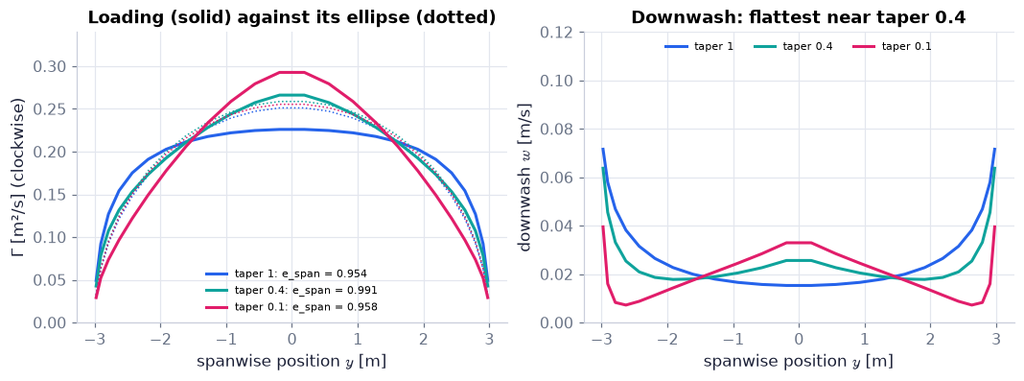

```python
fig, (axg, axw) = plt.subplots(1, 2, figsize=(9.6, 3.5))     # left: loadings; right: downwash — the slider figure above at three fixed positions
for tp, col in zip((1.0, 0.4, 0.1), (COLORS["blue"], COLORS["teal"], COLORS["rose"])):   # a rectangle, the near-elliptic taper, a nearly pointed tip
    st = LL.solve_lifting_line(c=LL.planform(kind="tapered", s=6.0, c_root=2*6.0/(6.0*(1 + tp)), taper=tp), s=6.0, U=1.0, alpha=wd["alpha"], K=2*np.pi, N=24)   # same span (6 m) and area (6 m²), one taper ratio
    axg.plot(st["y"], st["Gamma"], color=col, label=f"taper {tp:g}: e_span = {st['e_span']:.3f}")   # the loading Γ(y)
    axg.plot(st["y"], LL.elliptic_circulation(y=st["y"], s=6.0, Gamma1=st["Gn"][0]), color=col, ls=":", lw=1)   # the elliptic loading with the same lift (dotted)
    axw.plot(st["y"], st["w"], color=col, label=f"taper {tp:g}")   # the downwash w(y) [m/s] at U = 1 m/s
axg.set(xlabel="spanwise position $y$ [m]", ylabel="Γ [m²/s] (clockwise)", ylim=(0, 0.34), title="Loading (solid) against its ellipse (dotted)")   # labels
axw.set(xlabel="spanwise position $y$ [m]", ylabel="downwash $w$ [m/s]", ylim=(0, 0.12), title="Downwash: flattest near taper 0.4")   # labels
axg.legend(fontsize=7, loc="lower center"); axw.legend(fontsize=7, loc="upper center", ncol=3)   # which curve is which, placed clear of the curves
plt.show()                                                   # display
```

**What you see.** The slider figure above frozen at three taper ratios, for a page without JavaScript: the loading of each wing with the elliptic loading of the same lift (dotted), and its downwash.

**How to read it.** The rectangle (blue) is fuller than its ellipse toward the tips and its downwash climbs outboard; the nearly pointed wing (rose) is the opposite — too peaked in the middle; the taper of 0.4 (teal) lies almost on its ellipse and its downwash is nearly flat over the inner three quarters of the span. The span efficiencies in the legend rank them.

**What would change if…** …the aspect ratio were larger? All three loadings would move toward the shape of their chord distribution: on a very slender wing each strip behaves like a section on its own.

> ▶️ **Live cell.** The widget below needs a running Python kernel. On the web page it is frozen — open this notebook in Colab (button at the top) or run it locally to drag the sliders.

```python
def show_wing(taper=0.6, tip_twist_deg=0.0, AR=6.0, N=12):   # redraw for the slider values
    s_ = np.sqrt(AR*6.0)                                     # span for this aspect ratio at a fixed area of 6 m², from Λ = s²/A [m]
    c_root = 2*6.0/(s_*(1 + taper))                          # root chord that keeps the area [m]
    twist = lambda y: np.deg2rad(tip_twist_deg)*np.abs(2*y/s_)   # extra angle growing linearly from 0 at the root to the tip value [rad]
    st = LL.solve_lifting_line(c=LL.planform(kind="tapered", s=s_, c_root=c_root, taper=taper), s=s_, U=1.0, alpha=wd["alpha"], K=2*np.pi, twist=twist, N=int(N))   # solve
    fig, (axl, axr) = plt.subplots(1, 2, figsize=(9.0, 3.2)) # left: loading; right: coefficient bars
    axl.plot(st["y"], st["Gamma"], color=COLORS["amber"], label="Γ(y)")   # the loading
    axl.plot(st["y"], LL.elliptic_circulation(y=st["y"], s=s_, Gamma1=st["Gn"][0]), color=COLORS["muted"], ls="--", label="elliptic, same lift")   # its elliptic ghost
    axl.set(xlabel="y [m]", ylabel="Γ [m²/s] (clockwise)", title=f"C_L = {st['CL']:.3f}, C_Di = {st['CDi']:.5f}, e_span = {st['e_span']:.3f}")   # three numbers
    axl.legend(fontsize=8)                                   # which curve is which
    nn = np.arange(1, len(st["Gn"]) + 1)                     # mode numbers 1…N
    axr.bar(nn, nn*st["Gn"]**2, color=[COLORS["teal"]] + [COLORS["rose"]]*(len(nn) - 1))   # n Γ_n²: the first bar carries the lift, the others only cost drag
    axr.set(xlabel="n", ylabel="n Γ_n² [m⁴/s²]", title="what each sine adds to the induced drag")   # labels
    plt.show()                                               # display
_ = live(show_wing, taper=(0.1, 1.0, 0.1), tip_twist_deg=(-5.0, 5.0, 0.5), AR=(3.0, 20.0, 1.0), N=(1, 24, 1))   # four sliders (kernel only)
```

▶️ **Live cell.** These sliders need a running Python kernel, so they are frozen on this page. Press **Open in Colab** at the top (or run the notebook locally) to use them.

**What does the code above do?** Four sliders — taper ratio, twist at the tip (degrees), aspect ratio and number of terms — re-solve the lifting-line equation and redraw the loading with its elliptic ghost and the bars $n\Gamma_n^2$. The slider figure above carries the taper part of this on the web page.

📝 **Note.** **N63 [B]** **Twist.** A *rectangular* wing can carry an elliptic loading if its angle varies along the span like an ellipse: $\alpha(y)=\alpha_t+\alpha_r\sqrt{1-(2y/s)^2}$ with tip angle $\alpha_t=\dfrac{Kc\,\alpha_r}{4s}$ and $\Gamma_1=\tfrac12KUc\,\alpha_r$ (ours; stated, then confirmed by the solver in the next cell). Lowering the tips' angle like this is called *washout*.

> ⚠️ **slip #9 — the book prints** the span as $b$ in the two exercises on this**; the correct form is** $s$ (here $b$ is the constant of the map $z=\zeta+b^2/\zeta$).

```python
tw = LL.elliptic_twist_rectangular(alpha_r=wd["alpha"], c=wd["c"], s=wd["s"], K=wd["K"])    # the tip angle that makes a rectangle's loading elliptic
twist_fn = lambda y: tw["alpha_t"] + wd["alpha"]*np.sqrt(1 - (2*y/wd["s"])**2)              # the whole angle distribution α(y) [rad] (a lambda is a one-line function)
st_tw = LL.solve_lifting_line(c=wd["c"], s=wd["s"], U=wd["U"], alpha=0.0, K=wd["K"], twist=twist_fn, N=8)   # solve with that twist (alpha = 0: the twist carries the whole angle)
print(f"tip angle = {tw['alpha_t']:.5f} rad = {np.degrees(tw['alpha_t']):.2f}°; root angle = {np.degrees(tw['alpha_t'] + wd['alpha']):.2f}°")   # 1.31° at the tip, 6.31° at the root
print("Γ_n:", st_tw["Gn"].round(6), "m²/s; span efficiency =", round(st_tw["e_span"], 6))    # one coefficient only: [0.2742, 0, 0, …]; 1.0
```

```
tip angle = 0.02285 rad = 1.31°; root angle = 6.31°
Γ_n: [ 0.2742  0.      0.     -0.     -0.     -0.      0.      0.    ] m²/s; span efficiency = 1.0
```

**What does this show?** With the tip at 1.31° and the root at 6.31° the solver returns a single coefficient, Γ₁ = 0.2742 m²/s $=\tfrac12KUc\,\alpha_r$, and a span efficiency of exactly 1: an elliptic loading on a rectangular wing.

📝 **Note.** **N64 [C]** A small aircraft flying along a large one's tip vortex feels a rolling moment $M=\displaystyle\int_{-s/2}^{s/2}\rho U\,y\,\Gamma(y)\,dy$ — the reason for wake-turbulence separation at airports. (The exercise that poses it takes $w$ positive *upward* — trap T5.) One number with our own inputs:

```python
rm = ch14.wake_vortex_rolling_moment(rho=1.225, U=ac["U_cruise"], K=ac["K"], s=ac["s"], c=1.25, Gamma_v=300.0, ell=1.0)   # our light aircraft in a vortex of 300 m²/s with a 1 m core
print(f"rolling moment = {rm['M']:.0f} N m (quadrature: {rm['M_quad']:.0f}); for scale, weight × half-span = {ac['W']*ac['s']/2:.0f} N m")   # comparable to the weight acting at the wing tip
```

```
rolling moment = 126391 N m (quadrature: 126391); for scale, weight × half-span = 54000 N m
```

📝 **Note.** **N68 [B]** **When it fails.** Lifting-line results are approximate. They need a large aspect ratio and an unswept wing (assumptions 1 and 2 of N39), a wake that stays flat (assumption 3), and sections below stall — the section law $C_L=K\Big[\alpha-\dfrac{w(y)}{U}+\beta(y)\Big]$ (14.16) is a straight line. Extensions cover several wings, propellers, ground effect and bird formations.

**What would change if…** …we only want the wing's total lift and drag, not Γ(y)? They follow from the coefficients directly: C13.

### 🧩 Lift and induced drag from the coefficients: $L=\dfrac{\pi s}{4}\,\rho U\Gamma_1$ (14.21), $D_i=\dfrac\pi8\,\rho\displaystyle\sum_{n=1}^{N}n\,\Gamma_n^2$ (14.22) `C13`

*The question:* Which parts of the loading lift the aircraft, and which only cost drag?

#### The problem in plain words

Split a wing's loading into its sine shapes. The first is a single hump. The others wiggle: they add lift in one place and remove it in another, and over the whole span their lift adds up to nothing. But every wiggle sheds extra trailing vorticity, and trailing vorticity costs drag. So the lift is in the first shape alone — and every other shape is a pure cost.

#### The idea

| Term of the loading | Net lift | Induced drag |
| --- | --- | --- |
| $n=1$ | all of it | $\propto\Gamma_1^2$ |
| $n=2$ | 0 | $\propto2\,\Gamma_2^2$ |
| $n=3$ | 0 | $\propto3\,\Gamma_3^2$ |
| $n$ | 0 | $\propto n\,\Gamma_n^2$ |

> 📎 **Primer — a double sum collapsed by orthogonality.** `P348` · Multiplying two sums gives every pairing: $(\sum_na_n)(\sum_mb_m)=\sum_n\sum_ma_nb_m$ — use two different index letters. If the pairings are then weighted by a factor that is 1 when $n=m$ and 0 otherwise (the Kronecker delta $\delta_{nm}$), only the diagonal survives: $\sum_n\sum_ma_nb_m\delta_{nm}=\sum_na_nb_n$. (`np.outer(p, q)` is the table of all products $p_nq_m$; `np.eye(3)` is $\delta_{nm}$ as a table.)

```python
p3 = np.array([1., 2., 3.]); q3 = np.array([4., 5., 6.])   # two short lists
print(np.sum(np.outer(p3, q3)*np.eye(3)), np.sum(p3*q3))   # 32.0 both: the cross terms are gone
```

```
32.0 32.0
```

#### 🧮 Derivation — Lift from the first coefficient `D17` ★★ (Eq. 14.21: $L=\dfrac{\pi s}{4}\,\rho U\Gamma_1$)

**What we want to show.** Get the wing's total lift from the sine amplitudes. The book gives the result only.

**Assumptions.** ρ and U uniform along the span.

**The plan.**

1. Change variable to γ.
2. Insert the series.
3. Integrate term by term.
4. Use orthogonality.

**Tools we use** (each explained before this point): substitution in an integral (P106, reminder) · orthogonality of sines on the half range (P346)

**We start from**

$$ L=\displaystyle\int_{-s/2}^{s/2}\rho U\Gamma\,dy\ \text{(14.15) with}\ \Gamma=\displaystyle\sum_{n=1}^\infty\Gamma_n\sin(n\gamma)\ \text{(14.18)} $$

*In words:* Lift is ρU times the area under the loading

**Step 1 of 6 — Change the variable.**

$$ L=\rho U\,\dfrac s2\displaystyle\int_0^\pi\Gamma\,\sin\gamma\,d\gamma $$

- *Why we can do this:* $y=-(s/2)\cos\gamma$ gives dy = (s/2) sin γ dγ and limits 0 to π (D14 steps 1–2).
- *In words:* The area under the loading, measured in the span angle.

**Step 2 of 6 — Insert the series.**

$$ L=\rho U\,\dfrac s2\displaystyle\int_0^\pi\Big[\sum_{n=1}^{\infty}\Gamma_n\sin(n\gamma)\Big]\sin\gamma\,d\gamma $$

- *Why we can do this:* Replace Γ by its series $\Gamma=\sum\Gamma_n\sin(n\gamma)$ (14.18); we want the lift in terms of the amplitudes the solver returns.
- *In words:* Every sine of the loading is multiplied by sin γ.

**Step 3 of 6 — Exchange sum and integral.**

$$ L=\rho U\,\dfrac s2\displaystyle\sum_{n=1}^{\infty}\Gamma_n\int_0^\pi\sin(n\gamma)\,\sin\gamma\,d\gamma $$

- *Why we can do this:* The integral of a sum is the sum of the integrals.
- *In words:* One integral per term.

**Step 4 of 6 — Use orthogonality.**

$$ \displaystyle\int_0^\pi\sin(n\gamma)\,\sin\gamma\,d\gamma=\dfrac\pi2\ (n=1),\qquad0\ (n\ne1) $$

- *Why we can do this:* On the half range two different sines integrate to zero and a sine with itself to π/2 (P346); here the second sine is the n = 1 one, supplied by dy.
- *In words:* Only the first term survives.

**Step 5 of 6 — Keep the surviving term.**

$$ L=\rho U\,\dfrac s2\cdot\dfrac\pi2\,\Gamma_1 $$

- *Why we can do this:* Insert step 4 into step 3.
- *In words:* The lift contains Γ₁ and nothing else.

**Step 6 of 6 — Tidy up.**

$$ L=\dfrac{\pi s}{4}\,\rho U\Gamma_1\ \text{(14.21)} $$

- *Why we can do this:* Multiply the two numerical factors, (s/2)(π/2) = πs/4, to reach the form the book prints.
- *In words:* Lift = ρU × (the area of a half-ellipse of height Γ₁ and width s).

**Result**

$$ L=\dfrac{\pi s}{4}\,\rho U\Gamma_1 $$

*In words:* The lift needs only the first coefficient

**What it means.** The higher sines redistribute lift along the span without adding any. **Fails when:** never, within the series; it is an exact consequence of the two Start equations.

**Check it.** Units — (m)(kg/m³)(m/s)(m²/s) = N ✓. Limits — elliptic loading: ρU × area of a half-ellipse = ρU(π/4)sΓ₁ ✓. Number — Γ₁ = 12 m²/s, s = 12 m, ρ = 1.2, U = 50: 6786 N, whatever Γ₃ is.

📝 **Notes taught inside `D17`:** **N53 [B]** the lift needs only the first coefficient, $L=\dfrac{\pi s}{4}\rho U\Gamma_1$ (14.21).

> ⚠️ **Common confusion (traps in `D17`):** The sin γ that selects n = 1 comes from dy — forgetting it gives the wrong selection; the half-range integral is π/2, not π.

#### 🧮 Derivation — Induced drag from the coefficients `D18` ★★★ (Eq. 14.22: $D_i=\dfrac\pi8\,\rho\displaystyle\sum_{n=1}^{N}n\,\Gamma_n^2$)

**What we want to show.** Get the wing's induced drag from the sine amplitudes — and see that every amplitude adds to it. The book gives the result only.

**Assumptions.** The series are truncated at N terms (or converge well enough to be multiplied term by term).

**The plan.**

1. Change variable.
2. Insert w and cancel sin γ.
3. Insert Γ with a second index.
4. Multiply the two sums.
5. Integrate term by term.
6. Collapse with orthogonality.

**Tools we use** (each explained before this point): substitution in an integral (P106, reminder) · a double sum collapsed by orthogonality (P348) · orthogonality on the half range (P346)

**We start from**

$$ \begin{array}{l}D_i=\displaystyle\int_{-s/2}^{s/2}\rho w\Gamma\,dy\ \text{(14.15) with}\ \Gamma=\displaystyle\sum_{m}\Gamma_m\sin(m\gamma)\ \text{(14.18) and} \\ w=\dfrac{1}{2s}\displaystyle\sum_{n}n\,\Gamma_n\,\dfrac{\sin(n\gamma)}{\sin\gamma}\ \text{(14.19, last member)}\end{array} $$

*In words:* Drag is ρ times the span integral of downwash × circulation

**Step 1 of 9 — Change the variable.**

$$ D_i=\rho\,\dfrac s2\displaystyle\int_0^\pi w\,\Gamma\,\sin\gamma\,d\gamma $$

- *Why we can do this:* dy = (s/2) sin γ dγ, limits 0 to π (D14 steps 1–2).
- *In words:* The drag integral in the span angle.

**Step 2 of 9 — Insert the downwash series.**

$$ w\,\sin\gamma=\dfrac{1}{2s}\displaystyle\sum_{n}n\,\Gamma_n\sin(n\gamma) $$

- *Why we can do this:* Multiply the downwash series of the Start by sin γ: its 1/sin γ is cancelled by the sin γ of dy — once.
- *In words:* The awkward denominator disappears.

**Step 3 of 9 — Simplify the prefactor.**

$$ D_i=\dfrac\rho4\displaystyle\int_0^\pi\Big[\sum_{n}n\,\Gamma_n\sin(n\gamma)\Big]\Gamma\,d\gamma $$

- *Why we can do this:* ρ(s/2) × 1/(2s) = ρ/4; the span has cancelled.
- *In words:* The induced drag does not contain the span explicitly — only the amplitudes.

**Step 4 of 9 — Insert the circulation with its own index.**

$$ D_i=\dfrac\rho4\displaystyle\int_0^\pi\Big[\sum_{n}n\,\Gamma_n\sin(n\gamma)\Big]\Big[\sum_{m}\Gamma_m\sin(m\gamma)\Big]d\gamma $$

- *Why we can do this:* The two sums run independently, so they need different index letters; using n for both would silently drop the cross terms (P348).
- *In words:* A product of two sine series.

**Step 5 of 9 — Multiply out.**

$$ D_i=\dfrac\rho4\displaystyle\int_0^\pi\sum_{n}\sum_{m}n\,\Gamma_n\Gamma_m\,\sin(n\gamma)\sin(m\gamma)\,d\gamma $$

- *Why we can do this:* Every term of the first sum times every term of the second: N² products.
- *In words:* All pairings of a downwash sine with a loading sine.

**Step 6 of 9 — Exchange sums and integral.**

$$ D_i=\dfrac\rho4\displaystyle\sum_{n}\sum_{m}n\,\Gamma_n\Gamma_m\int_0^\pi\sin(n\gamma)\sin(m\gamma)\,d\gamma $$

- *Why we can do this:* Finite sums may be taken outside the integral; the amplitudes are constants.
- *In words:* One simple integral per pairing.

**Step 7 of 9 — Use orthogonality.**

$$ \displaystyle\int_0^\pi\sin(n\gamma)\sin(m\gamma)\,d\gamma=\dfrac\pi2\,\delta_{nm} $$

- *Why we can do this:* Different sines integrate to zero over the half range, equal ones to π/2 (P346); $\delta_{nm}$ is 1 if n = m and 0 otherwise.
- *In words:* Only pairings of a sine with itself contribute.

**Step 8 of 9 — Collapse the double sum.**

$$ \displaystyle\sum_{n}\sum_{m}n\,\Gamma_n\Gamma_m\,\dfrac\pi2\,\delta_{nm}=\dfrac\pi2\sum_{n}n\,\Gamma_n^2 $$

- *Why we can do this:* The delta removes the sum over m, setting m = n (P348).
- *In words:* N² pairings shrink to N squares.

**Step 9 of 9 — Assemble.**

$$ D_i=\dfrac\pi8\,\rho\displaystyle\sum_{n=1}^{N}n\,\Gamma_n^2\ \text{(14.22)} $$

- *Why we can do this:* (ρ/4)(π/2) = πρ/8. (Slip #7: the book writes the upper limit N here and ∞ in its series for Γ and w; this line is for the truncated solution.)
- *In words:* Each sine adds n times its amplitude squared — never a negative amount.

**Result**

$$ D_i=\dfrac\pi8\,\rho\displaystyle\sum_{n=1}^{N}n\,\Gamma_n^2 $$

*In words:* Every coefficient adds a positive amount of drag

**What it means.** For a given lift (a given Γ₁) the drag is least when all other amplitudes vanish; the excess is measured by $e_{\text{span}}=\Gamma_1^2/\sum n\Gamma_n^2\le1$ (N54). **Fails when:** the wake is not flat (winglets, non-planar wings can beat the planar optimum).

**Check it.** Units — (kg/m³)(m⁴/s²) = kg m/s² = N ✓ (ρΓ² is a force). Limits — one term: the elliptic value $D_i=\frac\pi8\rho\Gamma_1^2$ (14.25). Number — Γ₁ = 12, Γ₃ = 1 m²/s, ρ = 1.2: (π/8) × 1.2 × (144 + 3) = 69.3 N. Code — the trapezoid rule on the Start integral with w from the series agrees to 1e-5.

```python
import sympy as sp                                              # symbolic algebra
g, s, rho = sp.symbols("gamma s rho", positive=True)            # span angle, span, density
G = sp.symbols("Gamma1:5", real=True)                           # four coefficients Gamma_1..Gamma_4
Gam = sum(G[k]*sp.sin((k + 1)*g) for k in range(4))             # (14.18) truncated at N = 4
w = sum((k + 1)*G[k]*sp.sin((k + 1)*g) for k in range(4))/(2*s*sp.sin(g))     # (14.19), last member
integrand = rho*w*Gam*(s/2)*sp.sin(g)                           # steps 1-3: rho w Gamma dy with dy = (s/2) sin(gamma) d(gamma)
Di = sp.integrate(sp.expand(sp.simplify(integrand)), (g, 0, sp.pi))            # steps 4-8: all sixteen products, integrated
target = sp.pi/8*rho*sum((k + 1)*G[k]**2 for k in range(4))     # (14.22)
assert sp.simplify(Di - target) == 0                            # the cross terms have vanished
print(sp.integrate(sp.sin(2*g)*sp.sin(3*g), (g, 0, sp.pi)), sp.integrate(sp.sin(3*g)**2, (g, 0, sp.pi)))   # step 7: 0 and pi/2
```

```
0 pi/2
```

> ⚠️ **Common confusion (traps in `D18`):** The sin γ of dy cancels the 1/sin γ of w — do not cancel it twice; two different summation indices are needed; the factor n comes from w, once; N against ∞ as the upper limit (slip #7).

> ⚠️ **slip #7 — the book prints** the upper limit $N$ in $D_i=\dfrac\pi8\rho\displaystyle\sum_{n=1}^{N}n\Gamma_n^2$ (14.22) but ∞ in its series for Γ and $w$**; the correct form is** either, used consistently: the two force formulas are written for the truncated solution of $N$ terms.

📝 **Note.** **N54 [B]** For a given lift (a given Γ₁) the induced drag is least when every higher coefficient is zero. **Not in the book — ours:** the **span efficiency** $e_{\text{span}}\equiv\dfrac{\Gamma_1^2}{\sum n\Gamma_n^2}\le1$, with $C_{D_i}=\dfrac{C_L^2}{\pi\Lambda e_{\text{span}}}$.

> ⚠️ **Common confusion (trap T3):** aeronautics writes this as *e*; this chapter already uses $e$ for the thickness parameter, so we write $e_{\text{span}}$ (`e_span` in code).

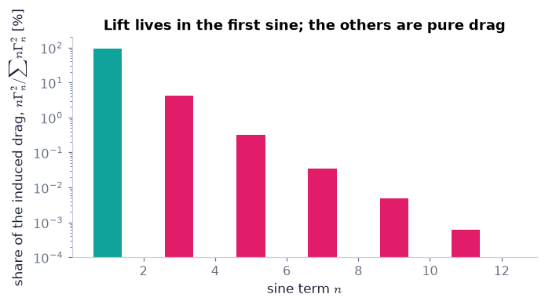

```
shares for n = 1, 3, 5 [%]: [95.4  4.2  0.3] ; e_span = 0.954
```

```python
s12 = LL.solve_lifting_line(c=wd["c"], s=wd["s"], U=wd["U"], alpha=wd["alpha"], K=wd["K"], N=12)   # the rectangular demo wing with 12 terms
nn = np.arange(1, 13)                                        # mode numbers 1…12
terms = nn*s12["Gn"]**2                                      # n Γ_n²: what each sine adds to the induced drag [m⁴/s²]
fig, ax = plt.subplots(figsize=(6.2, 3.3))                   # one panel
ax.grid(False)                                               # no grid lines across the bars
ax.bar(nn, 100*terms/terms.sum(), color=[COLORS["teal"]] + [COLORS["rose"]]*11)   # the first bar (teal) carries the lift; the others (rose) only cost drag
ax.set(xlabel="sine term $n$", ylabel=r"share of the induced drag, $n\Gamma_n^2/\sum n\Gamma_n^2$ [%]", yscale="log", ylim=(1e-4, 200), title="Lift lives in the first sine; the others are pure drag")   # logarithmic axis from 0.0001 % up: the even terms (zero to round-off, about 1e-30 %) fall below it and show no bar
plt.show()                                                   # display
print("shares for n = 1, 3, 5 [%]:", (100*terms[[0, 2, 4]]/terms.sum()).round(1), "; e_span =", round(LL.span_efficiency(Gn=s12["Gn"]), 3))   # 95.4, 4.2, 0.3; 0.954
```

**What you see.** One bar per sine term of the rectangular wing's loading: its share of the induced drag, on a logarithmic axis.

**How to read it.** The teal bar ($n$ = 1) is 95.4 % of the drag and *all* of the lift. The rose bars — 4.2 % from $n$ = 3, 0.3 % from $n$ = 5 — buy no lift at all. The even terms are zero for a symmetric wing, so the places $n$ = 2, 4, 6, … are empty. The span efficiency is the teal share: 0.954.

**What would change if…** …the wing were tapered to 0.4? The rose bars would shrink to under 1 % in total (the explainer below shows it).

#### ✏️ Tiny example: two sines again

Γ₁ = 12, Γ₃ = 1 m²/s, $s$ = 12 m, ρ = 1.2 kg/m³, $U$ = 50 m/s.

1. $L=\dfrac{\pi s}{4}\rho U\Gamma_1$ (14.21) = (π × 12/4) × 1.2 × 50 × 12 = 6786 N — Γ₃ does not appear.
2. $D_i=\dfrac\pi8\rho\sum n\Gamma_n^2$ (14.22) = (π/8) × 1.2 × (1 × 144 + 3 × 1) = 0.4712 × 147 = 69.3 N.
3. Without Γ₃ it would be 0.4712 × 144 = 67.9 N.
4. Span efficiency: 144/147 = 0.980 — the small third harmonic costs 2 % more drag and buys no lift.

```python
Gn = sol["Gn"]                                               # the 32 coefficients of the rectangular demo wing from C12 [m²/s]
L_ser = LL.lift_from_series(Gn=Gn, s=wd["s"], rho=wd["rho"], U=wd["U"])   # Eq. (14.21): L = (πs/4) ρ U Γ1 [N]
Di_ser = LL.induced_drag_from_series(Gn=Gn, rho=wd["rho"])   # Eq. (14.22): D_i = (π/8) ρ Σ n Γ_n² [N]
e_sp = LL.span_efficiency(Gn=Gn)                             # Γ1² / Σ n Γ_n²
CDi = LL.induced_drag_coefficient(CL=sol["CL"], AR=6.0, e_span=e_sp)   # C_L²/(π Λ e_span)
print(f"L = {L_ser:.3f} N, D_i = {Di_ser:.4f} N (ρ = 1 kg/m³, U = 1 m/s), e_span = {e_sp:.3f}, C_Di = {CDi:.5f} (solver: {sol['CDi']:.5f})")   # 1.186, 0.0261, 0.954, 0.00869
```

```
L = 1.186 N, D_i = 0.0261 N (ρ = 1 kg/m³, U = 1 m/s), e_span = 0.954, C_Di = 0.00869 (solver: 0.00869)
```

**What does the code above do?**

1. `LL.lift_from_series` is $L=\dfrac{\pi s}{4}\rho U\Gamma_1$ (14.21): it reads only the first coefficient.
2. `LL.induced_drag_from_series` is $D_i=\dfrac\pi8\rho\sum n\Gamma_n^2$ (14.22): it reads all of them.
3. `LL.span_efficiency` and `LL.induced_drag_coefficient` turn them into $e_{\text{span}}$ = 0.954 and $C_{D_i}$ = 0.00869 — the same numbers the solver reported in C12.

```python
rho_, U_, s_ = wd["rho"], wd["U"], wd["s"]                   # density [kg/m³], speed [m/s], span [m]
gq = np.linspace(0, np.pi, 4001)[1:-1]                       # span angles, tips excluded (sin γ = 0 there)
yq = -(s_/2)*np.cos(gq)                                      # the stations in metres
Gam_q = LL.circulation_series(Gn=Gn, gamma=gq)               # Eq. (14.18): the loading at those stations [m²/s]
w_q = LL.downwash_series(Gn=Gn, gamma1=gq, s=s_)             # Eq. (14.19): the downwash there [m/s]
L_mine = np.trapezoid(rho_*U_*Gam_q, yq)                     # Eq. (14.15), first integral, by the trapezoid rule [N]
Di_mine = np.trapezoid(rho_*w_q*Gam_q, yq)                   # Eq. (14.15), second integral [N]
assert np.allclose([L_mine, Di_mine], [L_ser, Di_ser], rtol=2e-3)   # the integrals equal the two closed forms (to the accuracy of the trapezoid rule near the tips)
print(f"L = {L_mine:.4f} N, D_i = {Di_mine:.5f} N by direct integration")   # 1.186 and 0.0261
```

```
L = 1.1861 N, D_i = 0.02608 N by direct integration
```

**What does the code above do?**

The two integrals $L=\int\rho U\Gamma\,dy$, $D_i=\int\rho w\Gamma\,dy$ (14.15) are evaluated directly with the trapezoid rule and compared with the two closed forms of this block.

#### 🎮 Interactive: What makes one wing better than another?

**Why interactive rather than a static figure:** changing taper, twist and aspect ratio and watching the coefficient bars, the loading against its elliptic ghost, the downwash and the efficiency respond together shows the method's inputs and outputs at once.

Start with the **Walkthrough**; the **Explain** tab works every number out with your settings, and the **Derivation** tab (where there is one) steps through the same derivation as above. Γ is the clockwise circulation in every readout; angles are shown in degrees and computed in radians.

**What to try:**

- Go from the rectangle to taper 0.4: what happens to the rose bars?
- Press 'rectangle with elliptic twist': how many bars are left?
- Raise N from 1 to 12 and watch the numbers settle.
- Click the n = 3 bar to see its shape on the span.

```python
show_viz("ch14", "lifting_line_solver")   # full-width explainer; ⤢ Full screen for more room
```

🎮 Interactive 7/9 What makes one wing better than another? Open alone ↗

[interactive chart not shown]

**What would change if…** …we switch every rose bar off? C14.

### 🧩 The elliptic loading: $C_{D_i}=\dfrac{C_L^2}{\pi\Lambda}$ (14.26) `C14`

*The question:* What is the cheapest way to carry a given weight on a given span — and why are glider wings so long?

#### The problem in plain words

An albatross glides for hours on wings three metres across and a hand wide. A sparrow could not. The reason is in one formula: the drag a wing pays for its lift is inversely proportional to the *square of its span*. Spread the same lift over twice the span and the bill drops to a quarter. And among all ways of spreading the lift along a given span, one is cheapest: the loading shaped like half an ellipse, which makes the air sink at the same speed everywhere along the wing.

#### The idea

[output not shown]

#### 🧮 Derivation — The elliptic optimum: loading, downwash, drag and drag coefficient `D19` ★★ (Eq. 14.26: $C_{D_i}=\dfrac{D_i}{(1/2)\rho U^2A}=\dfrac{C_L^2}{\pi(s^2/A)}=\dfrac{C_L^2}{\pi\Lambda}$)

**What we want to show.** Find the loading that carries a given lift on a given span with the least induced drag, and what that least drag is.

**Assumptions.** Fixed lift **and span**; a flat wake (lifting-line assumptions).

**The plan.**

1. Fix the lift.
2. Drop everything that only costs drag.
3. Translate the remaining sine back to y.
4. Find its downwash and drag.
5. Express the drag by the lift.
6. Make it a coefficient.

**Tools we use** (each explained before this point): a sum of non-negative terms · sin γ = √(1 − cos²γ) · substitution · section against wing coefficients (P336)

**We start from**

$$ L=\dfrac{\pi s}{4}\rho U\Gamma_1\ \text{(14.21) and}\ D_i=\dfrac\pi8\rho\displaystyle\sum n\Gamma_n^2\ \text{(14.22)} $$

*In words:* Lift from the first amplitude, drag from all of them

**Step 1 of 9 — Fix the lift.**

$$ \Gamma_1=\dfrac{4L}{\pi s\,\rho U} $$

- *Why we can do this:* Solve $L=\frac{\pi s}4\rho U\Gamma_1$ (14.21) for Γ₁: for a given lift, span, density and speed the first amplitude is not ours to choose.
- *In words:* The lift pins down the first sine.

**Step 2 of 9 — Separate the drag into two parts.**

$$ D_i=\dfrac\pi8\rho\,\Gamma_1^2+\dfrac\pi8\rho\displaystyle\sum_{n\ge2}n\,\Gamma_n^2,\qquad\sum_{n\ge2}n\,\Gamma_n^2\ge0 $$

- *Why we can do this:* Split the sum in the drag formula of the Start; every term is n times a square, so the second part cannot be negative.
- *In words:* A fixed part, plus an extra that is never a saving.

**Step 3 of 9 — Choose the minimum.**

$$ \Gamma_n=0\ (n\ge2)\ \Rightarrow\ \Gamma=\Gamma_1\sin\gamma $$

- *Why we can do this:* A sum of non-negative terms is smallest when each is zero; the series $\Gamma=\sum\Gamma_n\sin(n\gamma)$ (14.18) then has one term.
- *In words:* The best loading is a single sine of the span angle.

**Step 4 of 9 — Translate to the span coordinate.**

$$ \Gamma=\Gamma_1\sin(\gamma)=\Gamma_1\sqrt{1-(2y/s)^2}\ \text{(14.23)} $$

- *Why we can do this:* From $y=-(s/2)\cos\gamma$, cos γ = −2y/s, and sin γ = √(1 − cos²γ) ≥ 0 on 0 ≤ γ ≤ π.
- *In words:* Plotted against y, the loading is half an ellipse.

**Step 5 of 9 — Find its downwash.**

$$ w(y)=\dfrac{1}{2s}\,\Gamma_1\,\dfrac{\sin\gamma}{\sin\gamma}=\dfrac{\Gamma_1}{2s}\ \text{(14.24)} $$

- *Why we can do this:* The series $w=\dfrac1{2s}\sum n\Gamma_n\dfrac{\sin(n\gamma)}{\sin\gamma}$ (14.19, last member) with only n = 1.
- *In words:* The air sinks at the same speed everywhere along the wing.

**Step 6 of 9 — Write its drag.**

$$ D_i=\dfrac\pi8\,\rho\,\Gamma_1^2\ \text{(14.25), first form} $$

- *Why we can do this:* Step 2 with the extra part zero.
- *In words:* The least induced drag, in terms of the amplitude.

**Step 7 of 9 — Express it by the lift.**

$$ D_i=\dfrac\pi8\,\rho\,\dfrac{16L^2}{\pi^2s^2\rho^2U^2}=\dfrac{2L^2}{\pi\rho U^2s^2}\ \text{(14.25), second form} $$

- *Why we can do this:* Square the Γ₁ of step 1 and insert it into step 6: 16/π² times π/8 leaves 2/π, and one ρ cancels. We want the drag in terms of the lift.
- *In words:* Induced drag ∝ lift squared, over speed squared and **span squared**.

**Step 8 of 9 — Divide by ½ρU²A.**

$$ C_{D_i}=\dfrac{D_i}{\tfrac12\rho U^2A}=\dfrac{4L^2}{\pi\rho^2U^4s^2A} $$

- *Why we can do this:* The definition of a wing's drag coefficient (R01, planform area A).
- *In words:* The same drag, as a coefficient.

**Step 9 of 9 — Recognise the lift coefficient and the aspect ratio.**

$$ C_{D_i}=\dfrac{C_L^2}{\pi(s^2/A)}=\dfrac{C_L^2}{\pi\Lambda}\ \text{(14.26)} $$

- *Why we can do this:* $C_L^2=4L^2/(\rho^2U^4A^2)$, so $4L^2/(\rho^2U^4)=C_L^2A^2$; one factor A cancels and s²/A is Λ (14.1).
- *In words:* The price of lift: lift coefficient squared over π times aspect ratio.

**Result**

$$ \Gamma=\Gamma_1\sqrt{1-(2y/s)^2}\ \text{,}\ w=\Gamma_1/2s\ \text{,}\ D_i=\dfrac{2L^2}{\pi\rho U^2s^2}\ \text{,}\ C_{D_i}=\dfrac{C_L^2}{\pi\Lambda} $$

*In words:* An elliptic loading, a uniform downwash, and a drag that falls with the square of the span

**What it means.** Induced drag is set by the *span loading* L/s, not by the area; doubling the span at fixed lift quarters it. In level flight it falls as 1/U². **Fails when:** the wing is not planar (winglets), the span is not what is held fixed (structural weight grows with span), or the sections stall.

**Check it.** Units — L²/(ρU²s²): N²/(N) = N ✓; $C_{D_i}$ dimensionless ✓. Limits — Λ → ∞: no induced drag (two-dimensional flow); L = 0: none either. Number — W = 10 kN, ρ = 1.25, U = 40 m/s, s = 10 m, A = 20 m²: $D_i$ = 318 N, $C_{D_i}$ = 0.0159, w = 1.27 m/s; and D_i = L × (w/U) = 10 000 × 0.0318 ✓. Direct quadrature of the downwash integral $w(y_1)=\frac1{4\pi}\int\frac{d\Gamma}{dy}\frac{dy}{(y_1-y)}$ (14.13) for the half-ellipse gives the same uniform w.

📝 **Notes taught inside `D19`:** **N55 [B]** the elliptic loading $\Gamma=\Gamma_1\sin(\gamma)=\Gamma_1\sqrt{1-(2y/s)^2}$ (14.23) (steps 3–4) · **N56 [B]** the uniform downwash $w(y)=\Gamma_1/2s$ (14.24) (step 5) · **N57 [B]** $D_i=\dfrac\pi8\rho\Gamma_1^2=\dfrac{2L^2}{\pi\rho U^2s^2}$ (14.25) (steps 6–7).

> ⚠️ **Common confusion (traps in `D19`):** "minimum" is at fixed lift and span with a flat wake; Γ₁ is squared, so the factor is 16/π², not 4/π; dividing by ½ρU²A twice produces $C_L^2$ and leaves one factor A/s² = 1/Λ.

📝 **Note.** **N58 [B]** $dL=\rho U\Gamma\,dy=C_L\,\tfrac12\rho U^2c\,dy$ (14.27): with a uniform downwash, one section and no twist, every strip has the same $C_L$, so the chord must be proportional to the circulation: an **elliptic planform** gives the elliptic loading.

> ⚠️ **Common confusion:** (trap T11) the optimum is a statement about the *loading* Γ(y), not about the outline. An elliptic outline produces it only if untwisted with one section; a rectangle can produce it with twist (N63, C12); and "optimum" means least induced drag at a fixed lift **and span**, with a flat wake.

#### 🧮 Derivation — The elliptic planform and the lift slope of a finite wing `D20` ★★ (Eq. 14.27: $dL=\rho U\Gamma\,dy=C_L\,\tfrac12\rho U^2c\,dy$)

**What we want to show.** Find a wing shape that produces the elliptic loading without twist, and how much less lift such a wing gives per degree than its section alone. The second half is an exercise in the book.

**Assumptions.** Elliptic loading; the same section along the span and no twist (step 2); K constant.

**The plan.**

1. Get Γ from $C_L$ and c.
2. Argue that $C_L$ is the same at every station.
3. Conclude the chord law.
4. Put it into the lifting-line equation.
5. Solve for Γ₁.
6. Turn it into a lift slope.

**Tools we use** (each explained before this point): proportionality · solving a linear equation · area of an ellipse (gloss)

**We start from**

$$ dL=\rho U\Gamma\,dy=C_L\,\tfrac12\rho U^2c\,dy\ \text{(14.27)} $$

*In words:* The lift of a strip, written two ways

**Step 1 of 8 — Equate the two forms.**

$$ \Gamma=\tfrac12\,U\,c\,C_L $$

- *Why we can do this:* Both sides of $\rho U\Gamma\,dy=C_L\tfrac12\rho U^2c\,dy$ (14.27) are the lift of the same strip; cancel the common factor ρU dy.
- *In words:* At each station the circulation is proportional to chord × lift coefficient.

**Step 2 of 8 — Show $C_L$ is uniform.**

$$ C_L=K\Big[\alpha-\dfrac{\Gamma_1}{2sU}+\beta\Big]=\text{const} $$

- *Why we can do this:* For the elliptic loading $w=\Gamma_1/2s$ (14.24) at every station; with one section (same K, β) and no twist (same α), the section law $C_L=K[\alpha-w/U+\beta]$ (14.16) gives the same value everywhere.
- *In words:* Every strip works at the same lift coefficient.

**Step 3 of 8 — Conclude the chord law.**

$$ c(y)\propto\Gamma(y)\ \Rightarrow\ c=c_0\sqrt{1-(2y/s)^2}=c_0\sin\gamma $$

- *Why we can do this:* Step 1 with $C_L$ and U constant: chord and circulation have the same shape, and Γ is elliptic.
- *In words:* An elliptic planform, root chord c₀.

**Step 4 of 8 — Put it into the lifting-line equation.**

$$ \Gamma_1\sin\gamma=\dfrac K2\,U\,c_0\sin\gamma\,\Big[\alpha+\beta-\dfrac{\Gamma_1}{2sU}\Big] $$

- *Why we can do this:* $\Gamma(y)=\dfrac K2Uc\Big[\alpha-\dfrac wU+\beta\Big]$ (14.17) with Γ = Γ₁ sin γ, c = c₀ sin γ, w = Γ₁/2s.
- *In words:* The same sin γ on both sides: one sine really is enough.

**Step 5 of 8 — Cancel sin γ and solve for Γ₁.**

$$ \Gamma_1\Big(1+\dfrac{Kc_0}{4s}\Big)=\dfrac K2\,U\,c_0\,(\alpha+\beta) $$

- *Why we can do this:* Divide by sin γ (non-zero between the tips); move the Γ₁ term to the left.
- *In words:* A single linear equation for the single unknown.

**Step 6 of 8 — Express c₀/s by the aspect ratio.**

$$ A=\dfrac\pi4\,c_0\,s\ \Rightarrow\ \Lambda=\dfrac{s^2}{A}=\dfrac{4s}{\pi c_0}\ \Rightarrow\ \dfrac{Kc_0}{4s}=\dfrac{K}{\pi\Lambda} $$

- *Why we can do this:* An ellipse with axes s and c₀ has area π(s/2)(c₀/2).
- *In words:* The correction term depends only on K and Λ.

**Step 7 of 8 — Form the wing's lift coefficient.**

$$ C_L=\dfrac{\tfrac{\pi s}{4}\rho U\Gamma_1}{\tfrac12\rho U^2A}=\dfrac{K(\alpha+\beta)}{1+K/(\pi\Lambda)} $$

- *Why we can do this:* $L=\tfrac{\pi s}4\rho U\Gamma_1$ (14.21) with Γ₁ from step 5 and A from step 6: πsc₀/(4A) = 1.
- *In words:* The wing's lift coefficient is the section's, divided by 1 + K/(πΛ).

**Step 8 of 8 — Read off the slope.**

$$ \dfrac{dC_L}{d\alpha}=\dfrac{K}{1+K/(\pi\Lambda)};\qquad K=2\pi:\ C_{L,3D}=\dfrac{C_{L,2D}}{1+2/\Lambda} $$

- *Why we can do this:* Differentiate step 7 with respect to α; with K = 2π the correction K/(πΛ) is 2/Λ.
- *In words:* A finite wing lifts less per degree than its section: by a quarter at Λ = 6.

**Result**

$$ \begin{array}{l}\text{an untwisted wing of elliptic planform has the elliptic loading, and} \\ \dfrac{dC_L}{d\alpha}=\dfrac{K}{1+K/(\pi\Lambda)}\ \text{(ours);}\ C_{L,3D}=\dfrac{C_{L,2D}}{1+2/\Lambda}\ \text{for K = 2π.}\end{array} $$

**What it means.** The downwash reduces every strip's angle of attack by the same w/U = $C_L/(\pi\Lambda)$, so the whole lift line is tilted, not bent. **Fails when:** low aspect ratio or sweep (lifting-line theory itself fails); other planforms need the solver (their slope differs by a few per cent).

**Check it.** Units — all dimensionless ✓. Limits — Λ → ∞: the section's slope K; Λ → 0: slope → πΛ (very stubby wings lift little). Number — Λ = 6, K = 2π: 4.71 per radian (0.75 × 2π); Λ = 9.6: 5.20. Code — the solver with an elliptic planform returns one coefficient and this $C_L$ to round-off.

📝 **Notes taught inside `D20`:** **N59 [B]** the lift slope of a finite wing, $\dfrac{dC_L}{d\alpha}=\dfrac{K}{1+K/(\pi\Lambda)}$, i.e. $C_{L,3D}=\dfrac{C_{L,2D}}{1+2/\Lambda}$ for K = 2π (ours).

> ⚠️ **Common confusion (traps in `D20`):** Elliptic *loading* is not elliptic *planform* (trap T11): the planform gives the loading only if untwisted with one section; the correction is K/(πΛ) in general and 2/Λ only for K = 2π.

#### ✏️ Tiny example: the price of lift by hand

**N62 [C]** (the pattern of the book's level-flight exercise, with our own aircraft of C01: $W$ = 10 000 N, $s$ = 10 m, $A$ = 20 m², Λ = 5, ρ = 1.25 kg/m³ — a round value near the sea-level standard atmosphere of Ch. 1 — $U$ = 40 m/s, $C_L$ = 0.5.)

1. $D_i=\dfrac{2L^2}{\pi\rho U^2s^2}$ (14.25) = 2 × 10⁸/(π × 1.25 × 1600 × 100) = 318 N.
2. As a coefficient, $C_{D_i}=\dfrac{C_L^2}{\pi\Lambda}$ (14.26) = 0.25/15.7 = 0.0159; check: 0.0159 × 1000 Pa × 20 m² = 318 N ✓.
3. First coefficient from $L=\dfrac{\pi s}{4}\rho U\Gamma_1$ (14.21): Γ₁ = 4 × 10 000/(π × 10 × 1.25 × 40) = 25.5 m²/s.
4. Downwash $w=\Gamma_1/2s$ (14.24) = 1.27 m/s, a tilt of 1.27/40 = 0.032 rad = 1.8°; lift × tilt = 10 000 × 0.0318 = 318 N ✓.
5. Circulation half-way out along each wing ($y$ = ±2.5 m): 25.5 × √(1 − 0.25) = 22.1 m²/s.
6. Double the span at the same area (Λ = 20): 318/4 = 80 N.

```python
Di_slow = LL.elliptic_induced_drag(L=ac["W"], rho=1.225, U=ac["U_slow"], s=ac["s"])       # Eq. (14.25): induced drag of our aircraft at 30 m/s [N]
Di_fast = LL.elliptic_induced_drag(L=ac["W"], rho=1.225, U=ac["U_cruise"], s=ac["s"])     # the same at 55 m/s [N]
print(f"D_i = {Di_slow:.1f} N at 30 m/s, {Di_fast:.1f} N at 55 m/s (ratio {Di_slow/Di_fast:.2f})")   # 324.8 and 96.6: it falls as 1/U²
print(f"C_Di at C_L = 1.088, Λ = 9.6: {LL.induced_drag_coefficient(CL=1.088, AR=9.6):.4f}")           # Eq. (14.26): 0.0392
print(f"lift slope: {LL.finite_wing_lift_slope(K=2*np.pi, AR=9.6):.3f} per radian at Λ = 9.6, {LL.finite_wing_lift_slope(K=2*np.pi, AR=6.0):.3f} at Λ = 6 (section: {2*np.pi:.3f})")   # 5.200 and 4.712
ew = LL.elliptic_wing(alpha=wd["alpha"], AR=6.0, K=2*np.pi)  # an untwisted elliptic wing of aspect ratio 6 at α = 5°
print(f"elliptic wing, Λ = 6, α = 5° ({wd['alpha']:.4f} rad): C_L = {ew['CL']:.4f}, C_Di = {ew['CDi']:.5f}, w/U = {ew['w_over_U']:.4f}")   # 0.4112, 0.00897, 0.0218
```

```
D_i = 324.8 N at 30 m/s, 96.6 N at 55 m/s (ratio 3.36)
C_Di at C_L = 1.088, Λ = 9.6: 0.0392
lift slope: 5.200 per radian at Λ = 9.6, 4.712 at Λ = 6 (section: 6.283)
elliptic wing, Λ = 6, α = 5° (0.0873 rad): C_L = 0.4112, C_Di = 0.00897, w/U = 0.0218
```

**What does the code above do?**

1. `LL.elliptic_induced_drag` is $D_i=\dfrac{2L^2}{\pi\rho U^2s^2}$ (14.25): 324.8 N at 30 m/s and 96.6 N at 55 m/s for our aircraft.
2. Flying 1.8 times faster cuts the induced drag by 3.4: it falls as $1/U^2$.
3. `LL.induced_drag_coefficient` is $C_{D_i}=\dfrac{C_L^2}{\pi\Lambda}$ (14.26).
4. `LL.finite_wing_lift_slope` is the slope $K/(1+K/\pi\Lambda)$ of the derivation: 5.200 per radian at Λ = 9.6 and 4.712 (three quarters of 2π) at Λ = 6. `LL.elliptic_wing` collects the elliptic wing's numbers.

```python
w_five = [LL.downwash(y1=y1, Gamma_fn=ell, s=12.0) for y1 in (-5.0, -2.0, 0.0, 3.0, 5.5)]    # direct quadrature of Eq. (14.13) for the half-ellipse at five stations [m/s]
assert np.allclose(w_five, LL.elliptic_downwash(Gamma1=1.0, s=12.0))                         # all equal Γ1/2s = 0.04167: the downwash is uniform
s_el = LL.solve_lifting_line(c=LL.planform(kind="elliptic", s=6.0, c_root=4/np.pi), s=6.0, U=1.0, alpha=wd["alpha"], K=2*np.pi, N=8)   # an elliptic planform of aspect ratio 6 through the solver of C12
assert np.allclose(s_el["Gn"][1:], 0, atol=1e-12)            # every coefficient but the first is zero
assert np.isclose(s_el["CL"], ew["CL"])                      # and the lift coefficient is the closed form's
print("downwash at five stations:", np.round(w_five, 5), "m/s; Γ_n of the elliptic wing:", s_el["Gn"].round(4)[:3], "…; C_L =", round(s_el["CL"], 4))   # 0.04167 ×5; [0.2618, 0, 0]; 0.4112
```

```
downwash at five stations: [0.0417 0.0417 0.0417 0.0417 0.0417] m/s; Γ_n of the elliptic wing: [ 0.2618 -0.      0.    ] …; C_L = 0.4112
```

**What does the code above do?**

Two independent checks. (i) The principal-value integral $w(y_1)=\dfrac{1}{4\pi}\displaystyle\int\dfrac{d\Gamma}{dy}\dfrac{dy}{(y_1-y)}$ (14.13), evaluated numerically for a half-ellipse, returns the same downwash at five different stations. (ii) The general solver, given an elliptic planform, returns one coefficient only and the closed-form lift coefficient.

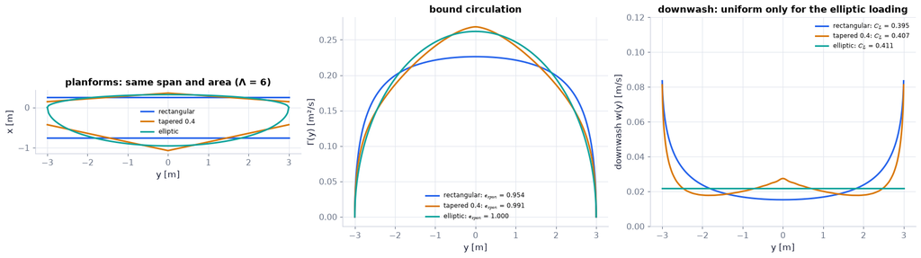

```python
fig = fig_planforms_loadings()                               # three planforms of equal span and area (rectangle, taper 0.4, ellipse) with their Γ(y), w(y) and span efficiency
plt.show()                                                   # display
```

**What you see.** Three wings of the same span and area — a rectangle, a tapered wing and an ellipse — each with the loading and the downwash the lifting-line solver gives it.

**How to read it.** Only the ellipse has a flat downwash, and its span efficiency is 1.000. The rectangle's downwash rises toward the tips and its efficiency is 0.954; the tapered wing, at 0.991, is close to the ellipse.

**What would change if…** …the rectangle were twisted as in N63? Its downwash would flatten and its efficiency would reach 1 as well.

```python
CLs = np.linspace(0.0, 1.5, 151)                             # lift coefficients on the horizontal axis
def induced_polar(AR):                                       # induced drag coefficient against lift coefficient for one aspect ratio
    return {"C_Di = C_L²/(πΛ), elliptic loading": (CLs, LL.induced_drag_coefficient(CL=CLs, AR=AR))}   # Eq. (14.26)
figF8a = slider_figure(induced_polar, "aspect ratio Λ", np.arange(3.0, 30.1, 1.0), unit="", xlabel="lift coefficient C_L [–]",
                       ylabel="induced drag coefficient C_Di [–]", yrange=[0, 0.25], title="The price of lift falls as the wing gets slender")   # 28 slider positions
figF8a.show()                                                # display
print(pd.DataFrame({"Λ": [3, 6, 9.6, 20, 30], "lift slope [1/rad]": [LL.finite_wing_lift_slope(K=2*np.pi, AR=A_) for A_ in (3, 6, 9.6, 20, 30)],
                    "C_Di at C_L = 1": [LL.induced_drag_coefficient(CL=1.0, AR=A_) for A_ in (3, 6, 9.6, 20, 30)]}).round(4).to_string(index=False))   # two numbers per aspect ratio
```

[interactive chart not shown]

```
   Λ  lift slope [1/rad]  C_Di at C_L = 1
 3.0              3.7699           0.1061
 6.0              4.7124           0.0531
 9.6              5.1999           0.0332
20.0              5.7120           0.0159
30.0              5.8905           0.0106
```

**What does the code above do?**

1. `induced_polar` is $C_{D_i}=\dfrac{C_L^2}{\pi\Lambda}$ (14.26) as a curve; the slider changes the aspect ratio.
2. The table lists the finite wing's lift slope $K/(1+K/\pi\Lambda)$ and the induced drag coefficient at $C_L$ = 1.

**What you see.** A parabola — induced drag coefficient against lift coefficient — that flattens as the aspect-ratio slider moves up.

**How to read it.** At a fixed lift coefficient the induced drag is inversely proportional to Λ: at $C_L$ = 1 it is 0.106 for a stubby Λ = 3 and 0.016 for a glider's Λ = 20. The same slenderness also raises the lift slope toward the section's 2π.

**What would change if…** …the span were doubled at the same area? Λ quadruples and, at the same $C_L$, the induced drag coefficient falls to a quarter.

**What would change if…** …we add the drag that has nothing to do with lift — friction and form drag? Then there is a best speed to fly: C15.

## 14.7 Lift and Drag Characteristics of Airfoils

**What is this section about?** What measured lift and drag curves look like, where they leave the theory (stall), and how the drag of a wing splits into a part that comes from friction and shape and a part that is the price of lift.

### 🧩 The drag breakdown and the polar: $C_D=C_{D0}+\dfrac{C_L^2}{\pi\Lambda e_{\text{span}}}$ (ours, built on $C_{D_i}=\dfrac{C_L^2}{\pi\Lambda}$ (14.26)) `C15`

*The question:* Fly slowly and one kind of drag is large; fly fast and another is. Where is the best speed?

#### The problem in plain words

A glider pilot knows a number called the best-glide speed. Slower than that the glider sinks faster; faster than that it also sinks faster. Two drags are fighting. Friction and the wake of the body grow with the square of the speed. The price of lift does the opposite: the slower you fly, the harder the wing must work to hold the same weight, and the induced drag grows as one over the square of the speed. The total has a minimum where the two are equal.

#### The idea

```
total drag ─┬─ friction drag (shear stress on the skin) ───────────┐
            │                                                      ├─ profile drag  C_D0  (what the section alone has)
            └─ pressure drag ─┬─ form drag (the wake of the shape) ─┘
                              └─ induced drag (the wing's tips)   C_L² / (π Λ e_span)
```

Friction and form drag were Chapter 9 (§9.8) and recap R02 in C01; the induced part is C10–C14.

📝 **Note.** **N70 [B]** **Measured section curves.** A straight range $C_L\simeq K(\alpha+\beta)$, lift at α = 0 from the camber, a maximum, a drop at stall; the drag of a *section* is small and nearly flat until the stall, where it jumps (on a finite wing an induced part growing as $C_L^2$, that is as α², is added: the polar below). The figure is a **qualitative model** whose every constant is ours.

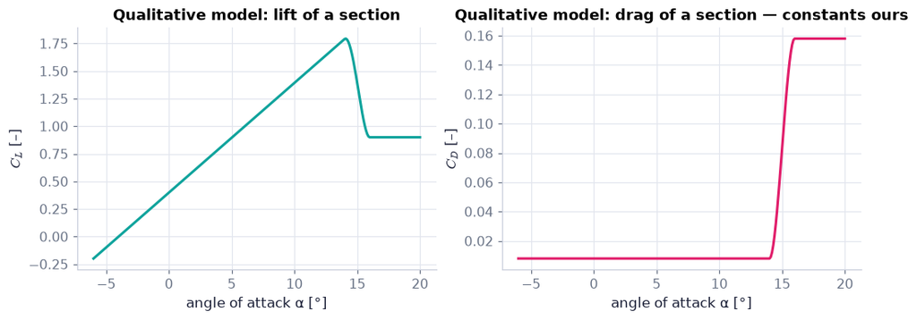

```python
al = np.deg2rad(np.linspace(-6.0, 20.0, 261))                # angles of attack [rad] (−6° … 20°)
stall = dict(K=5.7, beta=sec["beta"], alpha_stall=np.deg2rad(14.0), CL_post=0.9, width=np.deg2rad(2.0))   # our illustrative constants: slope 5.7/rad, stall at 14°, plateau 0.9, blended over 2°
CLm = ch14.generic_lift_curve(alpha=al, **stall)             # a generic measured lift curve
CDm = ch14.generic_drag_curve(alpha=al, CD0=0.008, AR=np.inf, e_span=1.0, CD_sep=0.15, **stall)   # the matching drag curve of a section (infinite aspect ratio: no induced drag)
fig, (axl, axd) = plt.subplots(1, 2, figsize=(9.4, 3.4))     # left: lift; right: drag
axl.plot(np.degrees(al), CLm, color=COLORS["teal"])          # lift coefficient
axl.set(xlabel="angle of attack α [°]", ylabel="$C_L$ [–]", title="Qualitative model: lift of a section")   # labels
axd.plot(np.degrees(al), CDm, color=COLORS["rose"])          # drag coefficient
axd.set(xlabel="angle of attack α [°]", ylabel="$C_D$ [–]", title="Qualitative model: drag of a section — constants ours")   # labels
plt.show()                                                   # display
```

**What you see.** A generic lift curve and a generic drag curve of a wing section against the angle of attack.

**How to read it.** Lift: a straight line through zero at α = −4° (the camber), a maximum near 14°, then a drop to a plateau — stall. Drag: nearly constant while the flow is attached, then a steep rise when it separates. Lift is some hundred times the drag in the attached range; that ratio is what makes wings worth having.

**What would change if…** …the section had a flap down? The lift curve would shift up and to the left (more camber) and the maximum rise (N73).

📝 **Note.** **N71 [C]** Past stall the flow leaves the upper surface near the nose and the wake is as wide as the section is tall (sketch below); the mechanism is N13 (C07).

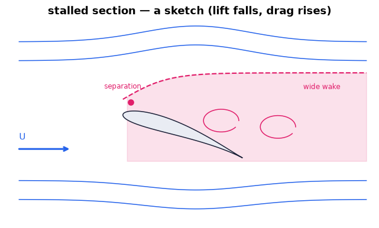

```python
fig = draw_stalled_section()                                 # a stalled section (a sketch, not a computation): the flow leaves the upper surface near the nose
plt.show()                                                   # display
```

📝 **Note.** **N72 [B]** How much lift a section reaches before it stalls depends on the chord Reynolds number $\mathrm{Re}_c=Uc/\nu$: at moderate values the laminar layer separates before it turns turbulent (early stall); at high values it turns turbulent first, and a turbulent layer survives a steeper pressure rise — the same physics as the drag crisis of a sphere (Ch. 9 §9.9).

```python
Re_slow = ch14.chord_reynolds(U=ac["U_slow"], c=1.25, nu=nu_air)       # chord Reynolds number of our wing (mean chord 1.25 m) at 30 m/s
Re_cruise = ch14.chord_reynolds(U=ac["U_cruise"], c=1.25, nu=nu_air)   # the same at 55 m/s
print(f"Re_c = {Re_slow:.2e} at 30 m/s, {Re_cruise:.2e} at 55 m/s")    # 2.57e6 and 4.71e6
print("regime at 30 m/s:", ch14.stall_regime(Re_c=Re_slow, Re_laminar=5e5, Re_turbulent=3e6))   # 'mixed' — thresholds ours, qualitative
print(f"a rough profile drag: C_D0 ≈ {ch14.profile_drag_estimate(Re_c=Re_slow, t_over_c=0.12, regime='turbulent', form_factor=1.3):.4f} for the wing alone")   # flat-plate friction on both faces × a form factor of 1.3 (ours)
```

```
Re_c = 2.57e+06 at 30 m/s, 4.71e+06 at 55 m/s
regime at 30 m/s: mixed
a rough profile drag: C_D0 ≈ 0.0101 for the wing alone
```

**What does this show?** Our wing flies at chord Reynolds numbers of a few million; with our (illustrative) thresholds the slow case is "mixed". The last line shows where a profile drag coefficient comes from: flat-plate friction on both faces (Ch. 9) times a form factor — an **approximate** estimate for the wing alone. A whole aircraft adds fuselage, tail and landing gear, which is why we use $C_{D0}$ = 0.025 for ours.

📝 **Note.** **N73 [B]** Camber lifts the whole curve; a flap is camber you can switch on; so the slowest speed at which the wing still carries the weight, $U_{\min}=\sqrt{\dfrac{2W}{\rho A\,C_{L,\max}}}$ (ours; step 5 of the derivation in C01), drops when the flap goes down.

```python
print(f"stall speed: {ch14.stall_speed(W=ac['W'], rho=1.225, A=ac['A'], CL_max=1.4):.1f} m/s clean, {ch14.stall_speed(W=ac['W'], rho=1.225, A=ac['A'], CL_max=2.0):.1f} m/s with the flap down")   # 26.5 and 22.1 m/s
```

```
stall speed: 26.5 m/s clean, 22.1 m/s with the flap down
```

> 📎 **Primer — reading a drag polar; the minimum of a/x + bx.** `P349` · A polar plots $C_L$ (up) against $C_D$ (across). A straight line from the origin to a point of the curve has slope $C_L/C_D$ = L/D; the steepest such line — the tangent — marks the best glide. Any function $p/x+qx$ has its minimum where the two terms are equal, at $x=\sqrt{p/q}$, value $2\sqrt{pq}$ (set the derivative $-p/x^2+q$ to zero — the quotient rule of Ch. 11, P265; a numerical minimiser was primed in Ch. 7, P170).

```python
p_, q_ = 0.02, 0.0637                            # C_D0 and 1/(pi*AR) for AR = 5
xs = np.linspace(0.1, 1.5, 1401)                 # candidate lift coefficients
print(xs[np.argmin(p_/xs + q_*xs)], np.sqrt(p_/q_))   # 0.56 both: the minimum of C_D/C_L
```

```
0.56 0.5603318146805257
```

> 🔁 **Tools from earlier chapters used in this block** (one line each; the full primers are in the chapters named)
- **quotient rule; `minimize_scalar`** — the quotient rule (f/g)′ = (f′g − fg′)/g² finds where a ratio is largest, and `minimize_scalar` finds the minimum of a function of one variable numerically inside a bracket; here they locate the best glide and the speed of least drag. *(Ch. 11, P265, P170, P349)*

#### 🧮 Derivation — The best glide and the U-shaped drag curve `D21` ★★ (Eq. 14.26: $C_{D_i}=\dfrac{D_i}{(1/2)\rho U^2A}=\dfrac{C_L^2}{\pi(s^2/A)}=\dfrac{C_L^2}{\pi\Lambda}$)

**What we want to show.** Find the flight condition with the least drag for a given weight, and how the two kinds of drag trade places with speed. The book says only that the induced drag grows as α².

**Assumptions.** a parabolic polar — $C_{D0}$ and $e_{\text{span}}$ constant; steady level flight (step 6).

**The plan.**

1. Form drag over lift.
2. Minimise it.
3. Evaluate the optimum.
4. Use level flight to write the drag in newtons against speed.

**Tools we use** (each explained before this point): the minimum of a/x + bx (P349) · quotient rule (P265, reminder) · level flight $C_L=W/(\tfrac12\rho U^2A)$ (D01)

**We start from**

$$ \begin{array}{l}C_D=C_{D0}+\dfrac{C_L^2}{\pi\Lambda e_{\text{span}}}\ \text{(ours), the profile drag plus the induced drag of} \\ C_{D_i}=\dfrac{C_L^2}{\pi\Lambda}\ \text{(14.26) corrected for a loading that is not elliptic.}\end{array} $$

**Step 1 of 8 — Abbreviate the polar.**

$$ C_D=C_{D0}+k\,C_L^2,\qquad k\equiv\dfrac{1}{\pi\Lambda e_{\text{span}}} $$

- *Why we can do this:* A shorthand; k is small for a slender, efficient wing.
- *In words:* Drag coefficient = a constant + a part that grows with lift squared.

**Step 2 of 8 — Form drag over lift.**

$$ \dfrac DL=\dfrac{C_D}{C_L}=\dfrac{C_{D0}}{C_L}+k\,C_L $$

- *Why we can do this:* Both forces share the factor ½ρU²A. In a glide, D/L is the glide slope; in level flight D = W × D/L.
- *In words:* One term falls with $C_L$, the other rises.

**Step 3 of 8 — Set the derivative to zero.**

$$ \dfrac{d}{dC_L}\Big(\dfrac{C_D}{C_L}\Big)=-\dfrac{C_{D0}}{C_L^2}+k=0 $$

- *Why we can do this:* A smooth function has its minimum where its slope vanishes (P349); the second derivative $2C_{D0}/C_L^3$ is positive.
- *In words:* The best point is where the two slopes cancel.

**Step 4 of 8 — Solve.**

$$ C_L^{*}=\sqrt{\dfrac{C_{D0}}{k}}=\sqrt{\pi\Lambda e_{\text{span}}\,C_{D0}}\quad\Rightarrow\quad k\,C_L^{*2}=C_{D0} $$

- *Why we can do this:* Step 3 says $k=C_{D0}/C_L^2$; solve for $C_L$ and take the positive root (a lifting wing). Multiplying back gives the equality of the two drag parts.
- *In words:* At the best glide the induced drag equals the profile drag.

**Step 5 of 8 — Evaluate the best ratio.**

$$ \Big(\dfrac LD\Big)_{\max}=\dfrac{C_L^{*}}{2C_{D0}}=\dfrac12\sqrt{\dfrac{\pi\Lambda e_{\text{span}}}{C_{D0}}} $$

- *Why we can do this:* At the optimum $C_D=2C_{D0}$; insert $C_L^*$.
- *In words:* A slender, clean wing glides far: L/D grows like √Λ.

**Step 6 of 8 — Use level flight.**

$$ C_L=\dfrac{W}{\tfrac12\rho U^2A} $$

- *Why we can do this:* L = W (D01). Each speed corresponds to one lift coefficient.
- *In words:* Fast flight is low-$C_L$ flight.

**Step 7 of 8 — Write the drag in newtons.**

$$ D=\tfrac12\rho U^2A\,C_{D0}+\tfrac12\rho U^2A\,k\,\dfrac{W^2}{(\tfrac12\rho U^2A)^2} $$

- *Why we can do this:* D = ½ρU²A·$C_D$ with step 1 and step 6.
- *In words:* A part that grows with U² and a part that falls with U².

**Step 8 of 8 — Simplify the induced part.**

$$ D=\tfrac12\rho U^2A\,C_{D0}+\dfrac{2W^2}{\pi\rho U^2s^2\,e_{\text{span}}} $$

- *Why we can do this:* k/(½ρU²A) = 2/(πΛ$e_{\text{span}}$ρU²A) and ΛA = s² (14.1). The second term is $D_i=\dfrac{2L^2}{\pi\rho U^2s^2}$ (14.25) over $e_{\text{span}}$.
- *In words:* A U-shaped curve: profile drag wins at high speed, induced drag at low speed.

**Result**

$$ \begin{array}{l}\Big(\dfrac LD\Big)_{\max}=\tfrac12\sqrt{\dfrac{\pi\Lambda e_{\text{span}}}{C_{D0}}}\ \text{at}\ C_L=\sqrt{\pi\Lambda e_{\text{span}}\,C_{D0}}\ \text{, where}\ C_{D0}=C_{D_i}\ \text{; in level flight} \\ D=\tfrac12\rho U^2AC_{D0}+\dfrac{2W^2}{\pi\rho U^2s^2e_{\text{span}}}\ \text{(ours).}\end{array} $$

**What it means.** The induced share of the drag is exactly one half at the best glide, more when slower, less when faster — "induced drag is the largest part" is a statement about speed (trap T9). **Fails when:** $C_{D0}$ varies (it does, with Reynolds number and near stall), or compressibility adds wave drag (Ch. 15).

**Check it.** Units — both drag terms in N ✓. Limits — $C_{D0}$ → 0: L/D → ∞ at $C_L$ → 0; Λ → ∞: no induced drag, the best speed → the lowest possible. Number — Λ = 5, $e_{\text{span}}$ = 1, $C_{D0}$ = 0.02: $C_L^*$ = 0.56, L/D = 14; our aircraft: 16.5 at 34.5 m/s, D = 546 N. Code — a brute-force scan of $C_L/C_D$ finds the same maximum.

📝 **Notes taught inside `D21`:** **N74 [B]** the best glide, $\Big(\dfrac LD\Big)_{\max}=\tfrac12\sqrt{\dfrac{\pi\Lambda e_{\text{span}}}{C_{D0}}}$ at $C_L=\sqrt{\pi\Lambda e_{\text{span}}C_{D0}}$ (ours; the book says only that the induced drag grows as α²).

> ⚠️ **Common confusion (traps in `D21`):** Minimise $C_D/C_L$, not $C_D$; the parabolic polar is a model; the minimum-drag speed is not the minimum-power speed (power is DU).

#### ✏️ Tiny example: a polar by hand

Λ = 5, $e_{\text{span}}$ = 1, so πΛ = 15.7; $C_{D0}$ = 0.02.

1. Best glide where induced = profile: $C_L^2/15.7$ = 0.02 → $C_L$ = √0.314 = 0.56.
2. There $C_D$ = 0.02 + 0.02 = 0.04 and L/D = 0.56/0.04 = 14.
3. Formula: ½√(15.7/0.02) = ½ × 28 = 14 ✓.
4. Fly faster, at half that lift coefficient (0.28): induced 0.005, total 0.025, L/D = 11.2, induced share 20 %.
5. Fly slower, at twice it (1.12): induced 0.08, total 0.10, L/D = 11.2, induced share 80 %.

Same glide ratio on both sides — for opposite reasons.

```python
pol = dict(CD0=ac["CD0"], AR=9.6, e_span=ac["e_span"])       # our aircraft's polar: profile drag 0.025, aspect ratio 9.6, span efficiency 0.9
print(f"C_D at C_L = 1.088: {ch14.drag_polar(CL=1.088, **pol):.4f}; parts:", {k: round(v, 4) for k, v in ch14.drag_breakdown(CL=1.088, **pol).items()})   # 0.0687 = 0.025 profile + 0.0436 induced
for U_ in (ac["U_slow"], ac["U_cruise"]):                    # the two speeds
    dv = ch14.drag_vs_speed(W=ac["W"], rho=1.225, A=ac["A"], AR=9.6, CD0=ac["CD0"], U=U_, e_span=ac["e_span"])   # drag in newtons in level flight
    print(f"U = {U_:.0f} m/s: profile {dv['profile']:.0f} N + induced {dv['induced']:.0f} N = {dv['total']:.0f} N; induced share {100*dv['induced_share']:.1f} %, L/D = {dv['LD']:.1f}")   # 207 + 361 = 568; 695 + 107 = 802
bg = ch14.best_glide(**pol)                                  # the best-glide point of the polar
U_bg = ch14.speed_min_drag(W=ac["W"], rho=1.225, A=ac["A"], AR=9.6, CD0=ac["CD0"], e_span=ac["e_span"])   # the speed at which the drag is least [m/s]
D_bg = ch14.drag_vs_speed(W=ac["W"], rho=1.225, A=ac["A"], AR=9.6, CD0=ac["CD0"], U=U_bg, e_span=ac["e_span"])["total"]   # the drag there [N]
print(f"best glide: L/D = {bg['LD_max']:.1f} at C_L = {bg['CL']:.3f}, U = {U_bg:.1f} m/s, drag {D_bg:.0f} N, glide angle {np.degrees(bg['glide_angle']):.2f}° ({bg['glide_angle']:.4f} rad)")   # 16.5, 0.824, 34.5 m/s, 546 N
```

```
C_D at C_L = 1.088: 0.0686; parts: {'profile': 0.025, 'induced': 0.0436, 'total': 0.0686, 'induced_share': 0.6356}
U = 30 m/s: profile 207 N + induced 361 N = 568 N; induced share 63.6 %, L/D = 15.9
U = 55 m/s: profile 695 N + induced 107 N = 802 N; induced share 13.4 %, L/D = 11.2
best glide: L/D = 16.5 at C_L = 0.824, U = 34.5 m/s, drag 546 N, glide angle 3.47° (0.0606 rad)
```

**What does the code above do?**

1. `ch14.drag_polar` is $C_D=C_{D0}+C_L^2/(\pi\Lambda e_{\text{span}})$; `ch14.drag_breakdown` returns its two parts as coefficients.
2. `ch14.drag_vs_speed` turns the polar into newtons for level flight: at 30 m/s the drag is 568 N, of which 64 % is induced; at 55 m/s it is 802 N, of which only 13 % is induced.
3. `ch14.best_glide` gives the maximum L/D = 16.5 at $C_L$ = 0.824.
4. `ch14.speed_min_drag` is the speed where that happens for our weight: 34.5 m/s, with a drag of 546 N.
5. Both of our flight speeds are off the optimum — one on the slow side, one on the fast side.

```python
CD0, AR_, e_sp_ = ac["CD0"], 9.6, ac["e_span"]               # profile drag coefficient, aspect ratio, span efficiency
CLs = np.linspace(0.05, 1.6, 15501)                          # a fine scan of lift coefficients
LD = CLs/(CD0 + CLs**2/(np.pi*AR_*e_sp_))                    # lift over drag at each one, from the polar
i = np.argmax(LD)                                            # index of the best one
assert np.isclose(LD[i], bg["LD_max"], rtol=1e-6)            # same maximum → the closed form is right
assert np.isclose(CLs[i], bg["CL"], atol=1e-4)               # at the same lift coefficient
print(f"brute force: L/D max = {LD[i]:.3f} at C_L = {CLs[i]:.4f}")   # 16.475 at 0.8238
```

```
brute force: L/D max = 16.475 at C_L = 0.8238
```

**What does the code above do?**

A brute-force scan over 15 501 lift coefficients finds the same maximum of $C_L/C_D$ as the closed form of the derivation.

**What does this show?** For our aircraft $(L/D)_{\max}$ = 16.5: from 1000 m of height it glides 16.5 km in still air — and only if it flies at 34.5 m/s.

📝 **Note.** **N75 [B]** The book says that induced drag is normally the largest part of a wing's drag.

> ⚠️ **Common confusion (trap T9):** that is a statement about a *flight condition*, not about wings. The induced share of the drag is exactly one half at the best glide, more when slower, less when faster.

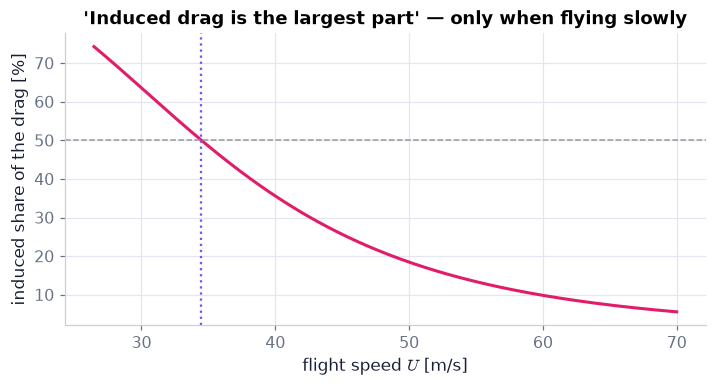

```
induced share at 30, 34.5 (best glide), 55 m/s [%]: [63.6 50.  13.4]
```

```python
U_stall = ch14.stall_speed(W=ac["W"], rho=1.225, A=ac["A"], CL_max=ac["CL_max"])   # slowest level speed [m/s]
Us = np.linspace(U_stall, 70.0, 300)                         # speeds from the stall speed to 70 m/s
CL_U = ac["W"]/(0.5*1.225*Us**2*ac["A"])                     # the lift coefficient level flight needs at each speed
share = ch14.drag_share(CL=CL_U, **pol)                      # induced fraction of the drag
fig, ax = plt.subplots(figsize=(6.4, 3.4))                   # one panel
ax.plot(Us, 100*share, color=COLORS["rose"])                 # induced share against speed
ax.axhline(50, color="0.6", ls="--", lw=1)                   # one half
ax.axvline(U_bg, color=COLORS["accent"], ls=":", lw=1.5)     # the best-glide speed
ax.set(xlabel="flight speed $U$ [m/s]", ylabel="induced share of the drag [%]", title="'Induced drag is the largest part' — only when flying slowly")   # labels
plt.show()                                                   # display
print("induced share at 30, 34.5 (best glide), 55 m/s [%]:", (100*ch14.drag_share(CL=ac["W"]/(0.5*1.225*np.array([30.0, U_bg, 55.0])**2*ac["A"]), **pol)).round(1))   # 63.6, 50.0, 13.4
```

**What you see.** The fraction of our aircraft's drag that is induced, from the stall speed to 70 m/s; the dotted line is the best-glide speed.

**How to read it.** The curve passes through exactly 50 % at the best-glide speed, 34.5 m/s. Slower than that the induced part dominates (64 % at 30 m/s, more near stall); at cruise it is a small part (13 % at 55 m/s).

**What would change if…** …the wing were more slender? The whole curve would drop: less induced drag at every speed (the sliders below).

```python
CLp = np.linspace(0.0, 1.5, 151)                             # lift coefficients for the polar
def polar(AR):                                               # the polar for one aspect ratio (area, weight, C_D0 and e_span fixed)
    bgA = ch14.best_glide(CD0=ac["CD0"], AR=AR, e_span=ac["e_span"])   # its best-glide point
    return {"polar: C_L against C_D": (ch14.drag_polar(CL=CLp, CD0=ac["CD0"], AR=AR, e_span=ac["e_span"]), CLp),
            "tangent from the origin (slope = best L/D)": (np.array([0.0, 2*bgA["CD"]]), np.array([0.0, 2*bgA["CL"]]))}   # curve and tangent
figF8b1 = slider_figure(polar, "aspect ratio Λ", np.arange(4.0, 24.1, 1.0), unit="", xlabel="drag coefficient C_D [–]",
                        ylabel="lift coefficient C_L [–]", xrange=[0, 0.2], yrange=[0, 1.55], title="A slender wing flattens the polar")   # 21 slider positions
figF8b1.show()                                               # display

Uv = np.linspace(22.0, 70.0, 200)                            # flight speeds [m/s]
def drag_curve(AR):                                          # drag in newtons against speed for one aspect ratio at fixed area and weight
    dv = ch14.drag_vs_speed(W=ac["W"], rho=1.225, A=ac["A"], AR=AR, CD0=ac["CD0"], U=Uv, e_span=ac["e_span"])   # the three drags
    return {"profile drag (grows as U²)": (Uv, dv["profile"]), "induced drag (falls as 1/U²)": (Uv, dv["induced"]), "total": (Uv, dv["total"])}   # three curves
figF8b2 = slider_figure(drag_curve, "aspect ratio Λ", np.arange(4.0, 24.1, 1.0), unit="", xlabel="flight speed U [m/s]",
                        ylabel="drag [N]", yrange=[0, 1500], title="Two drags trade places; the minimum is where they are equal")   # 21 slider positions
figF8b2.show()                                               # display
print(pd.DataFrame([{"Λ": A_, "best L/D": ch14.best_glide(CD0=ac["CD0"], AR=A_, e_span=ac["e_span"])["LD_max"], "best-glide speed [m/s]": ch14.speed_min_drag(W=ac["W"], rho=1.225, A=ac["A"], AR=A_, CD0=ac["CD0"], e_span=ac["e_span"])} for A_ in (4.0, 9.6, 16.0, 24.0)]).round(2).to_string(index=False))   # the numbers behind four slider positions
```

[interactive chart not shown]

```
   Λ  best L/D  best-glide speed [m/s]
 4.0     10.63                   42.92
 9.6     16.48                   34.48
16.0     21.27                   30.35
24.0     26.05                   27.42
```

**What does the code above do?**

1. `polar` returns the polar and its tangent from the origin; the tangent's slope is the best L/D.
2. `drag_curve` returns profile, induced and total drag in newtons against speed.
3. The table lists best L/D and best-glide speed for four aspect ratios at the same area and weight.

**What you see.** Two slider figures for the aspect ratio: the polar with its tangent, and the U-shaped drag curve with its two parts.

**How to read it.** A slender wing flattens the polar (the tangent steepens: better L/D) and moves the crossing of the two drag curves — the minimum of the total — to a lower speed. Best L/D grows like √Λ.

**What would change if…** …the weight doubled? The induced curve would quadruple; the best speed would rise by √2 and the best L/D stay the same.

📝 **Note.** **N76 [C]** Near the speed of sound local shock waves appear on the wing; sweeping it back reduces the Mach number of the flow component normal to the leading edge, $\mathrm{Ma}_n=\mathrm{Ma}\cos\Lambda_{\text{sweep}}$ (ours). Shock waves are Ch. 15 §15.6 and thin sections in supersonic flow §15.10. (The sweep angle shares the letter Λ with the aspect ratio.)

#### 🎮 Interactive: Why are glider wings so long and thin?

**Why interactive rather than a static figure:** stretching the span at fixed area reshapes the planform, flattens the polar and slides the minimum of the U-shaped drag curve at once; the speed cursor swaps which bar is larger.

Start with the **Walkthrough**; the **Explain** tab works every number out with your settings, and the **Derivation** tab (where there is one) steps through the same derivation as above. Γ is the clockwise circulation in every readout; angles are shown in degrees and computed in radians.

**What to try:**

- Drag the speed from stall to cruise and watch the two bars cross.
- Double Λ at fixed area: what happens to the best-glide speed and ratio?
- Switch the mode from glider to airliner.
- Find the speed at which the induced share is exactly 50 %.

```python
show_viz("ch14", "elliptic_loading_aspect_ratio")   # full-width explainer; ⤢ Full screen for more room
```

🎮 Interactive 8/9 Why are glider wings so long and thin? Open alone ↗

[interactive chart not shown]

**What would change if…** …the wing itself moved across the stream? Then its lift would lean *forward*. §14.8 and §14.9.

## 14.8 Propulsive Mechanisms of Fish and Birds

**What is this section about?** A wing gives a force across the stream. Move the wing sideways through the water and "across the stream it feels" has a forward part. A tail fin and a flapping wing are lifting surfaces used as engines.

📝 **Note.** **N77 [B]** **The fish tail.** The fish swims forward at $U$ while its tail, a symmetric section, sweeps sideways at $V$. The water meets the tail along the diagonal of that triangle, at the angle θ with $V/U=\tan\theta$. The lift $L$ is perpendicular to the diagonal: its forward part is the thrust $L\sin\theta$, delivered at the rate $UL\sin\theta$; its sideways part $L\cos\theta$ is what the muscles work against, at the rate $VL\cos\theta$.

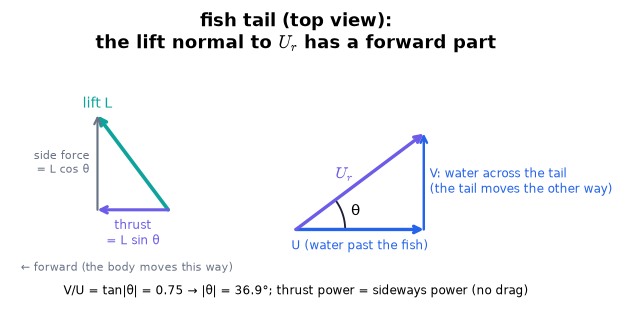

```python
fig = draw_velocity_triangle(kind="fish")                    # the fish's forward speed U, the tail's sideways speed V, the relative velocity, and the lift normal to it
plt.show()                                                   # display
```

**What you see.** The velocity triangle of a tail fin: forward speed $U$, sideways speed $V$, their resultant (the water the tail meets), and the lift at right angles to that resultant, split into thrust and side force.

**How to read it.** The lift leans forward by the same angle θ by which the relative velocity leans sideways. Forward part: $L\sin\theta$ (thrust). Sideways part: $L\cos\theta$.

**What would change if…** …the tail swept back the other way? $V$ reverses, the triangle flips, the side force reverses — and the thrust still points forward.

#### ✏️ Tiny example: a tail stroke by hand

$U$ = 1.0 m/s, $V$ = 0.75 m/s, $L$ = 10 N.

1. tan θ = 0.75, so sin θ = 0.6 and cos θ = 0.8 (a 3–4–5 triangle; θ = 36.9° = 0.644 rad).
2. Thrust = 10 × 0.6 = 6 N; side force = 10 × 0.8 = 8 N.
3. Useful power = $U$ × thrust = 1.0 × 6 = 6 W.
4. Power put in = $V$ × side force = 0.75 × 8 = 6 W.
5. They are equal — always, because $V=U\tan\theta$ makes $VL\cos\theta=UL\sin\theta$.
6. With a drag of 1 N along the diagonal: thrust 6 − 0.8 = 5.2 N, side force 8 + 0.6 = 8.6 N, efficiency (5.2 × 1.0)/(8.6 × 0.75) = 0.81.

```python
ideal = ch14.oscillating_foil(U=fish["U"], V=fish["V"], L=fish["L"])                # the tail with lift only
real = ch14.oscillating_foil(U=fish["U"], V=fish["V"], L=fish["L"], D=fish["D"])    # the same with a drag of 1 N along the relative velocity
for name, r_ in (("no drag  ", ideal), ("drag 1 N ", real)):    # print both
    print(f"{name}: θ = {np.degrees(r_['theta']):.1f}° ({r_['theta']:.3f} rad), thrust {r_['thrust']:.1f} N, side force {r_['side_force']:.1f} N, power out {r_['power_out']:.2f} W, power in {r_['power_in']:.2f} W, efficiency {r_['efficiency']:.3f}")   # 6, 8, 6, 6, 1.000 ; 5.2, 8.6, 5.2, 6.45, 0.806
```

```
no drag  : θ = 36.9° (0.644 rad), thrust 6.0 N, side force 8.0 N, power out 6.00 W, power in 6.00 W, efficiency 1.000
drag 1 N : θ = 36.9° (0.644 rad), thrust 5.2 N, side force 8.6 N, power out 5.20 W, power in 6.45 W, efficiency 0.806
```

**What does this show?** `ch14.oscillating_foil` reproduces the hand example: without drag the tail delivers 6 N of thrust and all the power put in comes out as useful power; with a drag of 1 N the thrust is 5.2 N and the efficiency 0.806.

> ⚠️ **Common confusion:** (trap T18) the perfect score is an identity of the triangle, not a prediction: the book's picture has no drag and no wake, and treats each instant as steady.

📝 **Note.** **N79 [B]** **Bird flight.** On the downstroke the wing moves down and forward through the air; the lift, normal to the relative wind, points up *and* forward: weight support and thrust at once. On the upstroke the wing moves up, so its relative wind comes from above-ahead and a positive lift would lean *backward*; the bird therefore feathers the wing — sets it nearly edge-on to that relative wind — and the wing does little.

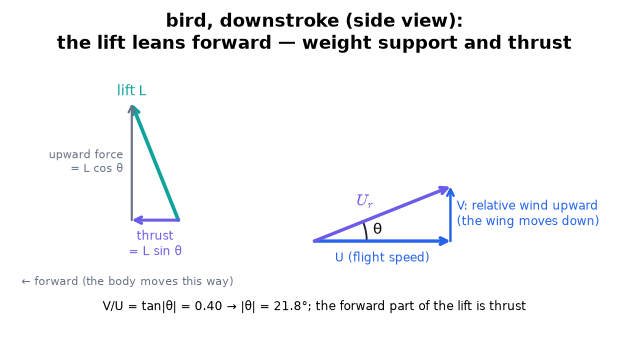

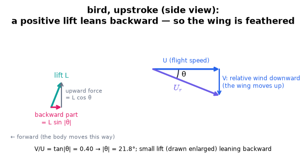

```
downstroke: θ = +21.8°, forward force +0.743 N, power the bird puts in +7.43 W
upstroke:   θ = -21.8°, forward force -0.074 N, power the bird puts in -0.74 W
mean forward force over the two half-strokes: 0.33 N
```

```python
Ub, Vb = 10.0, 4.0                                           # flight speed and the wing's vertical speed in mid-stroke [m/s] (ours, arbitrary)
fig = draw_velocity_triangle(kind="bird_down", U=Ub, V=Vb)   # downstroke: the wing moves down, so the relative wind comes from below-ahead and the lift leans forward
fig = draw_velocity_triangle(kind="bird_up", U=Ub, V=Vb)     # upstroke: the wing moves up, so the relative wind comes from above-ahead and a positive lift leans backward
plt.show()                                                   # display both sketches
down = ch14.oscillating_foil(U=Ub, V=Vb, L=2.0)              # downstroke: V > 0 means the wing moves against its own lift (here: down); lift 2 N
up = ch14.oscillating_foil(U=Ub, V=-Vb, L=0.2)               # upstroke: V < 0 means the wing moves the way its lift points (up); a feathered wing keeps, say, a tenth of the lift
print(f"downstroke: θ = {np.degrees(down['theta']):+.1f}°, forward force {down['thrust']:+.3f} N, power the bird puts in {down['power_in']:+.2f} W")   # +21.8°, +0.743 N, +7.43 W
print(f"upstroke:   θ = {np.degrees(up['theta']):+.1f}°, forward force {up['thrust']:+.3f} N, power the bird puts in {up['power_in']:+.2f} W")       # −21.8°, −0.074 N (backward), −0.74 W (the air pushes the wing up)
print(f"mean forward force over the two half-strokes: {0.5*(down['thrust'] + up['thrust']):.2f} N")   # 0.33 N (inputs ours, arbitrary)
```

**What does this show?** The same triangle as the fish tail turned on its side: with a wing speed of 4 m/s at a flight speed of 10 m/s (θ = 21.8° = 0.381 rad), 2 N of lift gives 0.74 N of thrust on the downstroke. On the upstroke the triangle is mirrored — the relative wind comes from above — and whatever positive lift is left on the wing leans backward: a tenth of the lift gives −0.074 N, a small drag, while the air does 0.74 W of work *on* the wing. That is why the wing is feathered on the way up: set nearly parallel to its relative wind, it carries almost no force. The upstroke is therefore "≈ 0", and its sign depends on how the bird feathers the wing (a slightly negative lift would even give a little thrust, at the price of weight support). With our numbers the mean over the two half-strokes is 0.33 N. The inputs are ours and arbitrary — the point is the direction of the force.

> ⚠️ **Common confusion:** the fish tail gives thrust on *both* half-strokes because its lift changes sides with the stroke (a symmetric section meeting the water from the other side). A bird's wing must keep lifting upward, so only the downstroke can lean its lift forward.

📝 **Note.** **N78 [C] · N80 [C]** - **N78 [C]** Whales and dolphins move a horizontal tail up and down — the same triangle turned on its side; bumps on a humpback's flipper delay separation (N13, N72); flexible fins change camber within a stroke. Biological flows are Ch. 16.

- **N80 [C]** Measured bird-wing shapes and a computed flight of a fruit fly are quoted in the book; the numbers stay there. An insect flies at so low a Reynolds number that "thin boundary layers" (N01) no longer holds.

## 14.9 Sailing against the Wind

**What is this section about?** The same velocity triangle a third time: a sail is a wing standing on end in the wind the boat *feels*. As long as that wind comes from far enough off the bow, the sail's lift has a forward part — even when the boat is heading into the wind.

### 🧩 Thrust from lift: $\mathbf U_r=\mathbf U-\mathbf V$, drive $=L\sin\beta_a-D\cos\beta_a$ (ours) `C16`

*The question:* How can a boat sail against the wind that drives it?

#### The problem in plain words

"The wind pushes the sail" explains sailing downwind and nothing else. A sail trimmed close is a wing: air flows *along* both sides and the force is mostly sideways to the wind the boat feels. That felt wind — the apparent wind — is the true wind minus the boat's own velocity, so it always comes from further ahead than the true wind. Lift is perpendicular to it; and a force perpendicular to a wind from ahead-and-to-the-side points partly forward. The sideways rest of the force would shove the boat downwind, were it not for a second wing under the water: the keel.

#### The idea

```
plan view, the boat heading up the page; the wind comes from ahead-right, so LEEWARD IS TO THE LEFT

             true wind U  ↙  (from ahead and to the right, at θ off the bow)
     apparent wind U_r = U − V  ↓↙  (closer to the bow, at β_a < θ, and stronger)

                   ▲  V (boat velocity)
  L  ↖            ╱█╲
(teal) ╲───────    █      lift ⟂ U_r : points forward-and-left (to leeward)
                   █
        D  ↙ ──    █      drag ∥ U_r : points back-and-left, the way the apparent wind blows
                  ╲█╱
     drive  =  forward part of L  −  backward part of D
```

In this block θ is the **course angle** off the true wind, and $\beta_a$ the angle of the apparent wind off the bow (not the camber angle).

> 🔁 **Tools from earlier chapters used in this block** (one line each; the full primers are in the chapters named)
- **true wind, boat velocity, apparent wind; `ch14.apparent_wind`** — the wind a moving body feels is the air's velocity minus its own, $\mathbf U_r=\mathbf U-\mathbf V$ — primed in C10 of this chapter (P350); the sail lives in it. *(this chapter, P350)*

> 📎 **Primer — sailing vocabulary: bow, windward, leeward, abeam, run, tack, heel.** `P353` · Seven words, with the sketch above in mind (boat heading up the page, wind from ahead-right). The **bow** is the front of the boat. The **windward** side is the side the wind comes from (the right in the sketch); the **leeward** side is the one it blows toward (the left). A wind from **abeam** arrives at 90° to the course, and sailing so is a **beam reach**; "forward of the beam" means from further ahead than that. A **run** is sailing with the wind from behind. To **tack** is to turn the bow through the wind so that it arrives over the other side; each straight leg of the zig-zag that results is also called a tack. The boat **heels** when the sideways force on the sail tips it toward leeward — ignored here: all forces are taken in the horizontal plane.

#### 🧮 Derivation — Sailing: the apparent wind, the drive $L\sin\beta_a-D\cos\beta_a$, and the closest course $\beta_a=\varepsilon_A+\varepsilon_H$ `D22` ★★

**What we want to show.** Find the force that drives a sailing boat along its course and how close to the wind it can point. The book resolves the force in words; here it is in symbols.

**Assumptions.** Steady sailing; forces in the horizontal plane; quasi-steady sail and keel forces (trap T18).

**The plan.**

1. Components of the apparent wind along and across the course.
2. Its angle off the bow.
3. Resolve lift and drag along and across the course.
4. Find where the drive vanishes.
5. Add the hull's balance.

**Tools we use** (each explained before this point): relative velocity (P350) · resolving a force · `np.arctan2` (P70, reminder) · the tangent of a difference of two angles (gloss)

**We start from**

$$ \mathbf U_r=\mathbf U-\mathbf V $$

*In words:* The wind the boat feels is the true wind minus the boat's own velocity; the sail's lift L is perpendicular to $\mathbf U_r$ and its drag D is along it

**Step 1 of 8 — Choose axes on the boat.**

$$ \hat{\mathbf t}\ \text{along the course},\quad\hat{\mathbf n}\ \text{across it, to leeward};\qquad\mathbf V=V\,\hat{\mathbf t} $$

- *Why we can do this:* The boat can only use the force component along its course; the keel resists the component across it.
- *In words:* Forward and sideways, as the boat sees them.

**Step 2 of 8 — Resolve the true wind.**

$$ \mathbf U=-U\cos\theta\,\hat{\mathbf t}+U\sin\theta\,\hat{\mathbf n} $$

- *Why we can do this:* The wind comes *from* the direction at the angle θ off the bow on the windward side, so it blows backward (−$\hat{\mathbf t}$) and to leeward (+$\hat{\mathbf n}$).
- *In words:* A headwind part and a crosswind part.

**Step 3 of 8 — Subtract the boat's velocity.**

$$ \mathbf U_r=-(U\cos\theta+V)\,\hat{\mathbf t}+U\sin\theta\,\hat{\mathbf n},\qquad\tan\beta_a=\dfrac{U\sin\theta}{U\cos\theta+V} $$

- *Why we can do this:* $\mathbf U_r=\mathbf U-\mathbf V$ (P350); $\beta_a$ is the angle between the bow and the direction the apparent wind comes from. Since V > 0, $\beta_a<\theta$.
- *In words:* The felt wind is stronger from ahead, and closer to the bow than the true wind.

**Step 4 of 8 — Write the sail's two forces.**

$$ \mathbf D=D\,(-\cos\beta_a\,\hat{\mathbf t}+\sin\beta_a\,\hat{\mathbf n}),\qquad\mathbf L=L\,(\sin\beta_a\,\hat{\mathbf t}+\cos\beta_a\,\hat{\mathbf n}) $$

- *Why we can do this:* Drag points along the apparent wind (the unit vector of $\mathbf U_r$); lift is that direction turned by 90° toward the bow, with $L=C_L\tfrac12\rho U_r^2A$ and likewise D.
- *In words:* Drag pulls back and to leeward; lift pulls forward and to leeward.

**Step 5 of 8 — Add the components along the course.**

$$ F_{\text{drive}}=L\sin\beta_a-D\cos\beta_a $$

- *Why we can do this:* The $\hat{\mathbf t}$-parts of step 4.
- *In words:* The drive is the forward part of the lift minus the backward part of the drag.

**Step 6 of 8 — Add the components across the course.**

$$ F_{\text{side}}=L\cos\beta_a+D\sin\beta_a $$

- *Why we can do this:* The $\hat{\mathbf n}$-parts of step 4.
- *In words:* A side force, usually several times the drive, pushing the boat to leeward.

**Step 7 of 8 — Find where the drive vanishes.**

$$ F_{\text{drive}}=0\ \Longleftrightarrow\ \tan\beta_a=\dfrac DL\equiv\tan\varepsilon_A $$

- *Why we can do this:* Set step 5 to zero and divide by L cos $\beta_a$. $\varepsilon_A$ is the sail's drag angle: the angle by which its total force leans back from the lift.
- *In words:* No sail can drive a boat when the felt wind is closer to the bow than its own drag angle.

**Step 8 of 8 — Balance against the hull.**

$$ \dfrac{F_{\text{drive}}}{F_{\text{side}}}=\tan(\beta_a-\varepsilon_A)=\dfrac{D_H}{L_H}=\tan\varepsilon_H\ \Rightarrow\ \beta_a=\varepsilon_A+\varepsilon_H $$

- *Why we can do this:* In steady sailing the hull's drag $D_H$ balances the drive and the keel's lift $L_H$ the side force. Steps 5 and 6 divided by L cos $\beta_a$ form the tangent of a difference of two angles.
- *In words:* In steady sailing the apparent wind sits off the bow by the sum of the two drag angles — sail's and hull's.

**Result**

$$ \begin{array}{l}F_{\text{drive}}=L\sin\beta_a-D\cos\beta_a\ \text{, zero at}\ \tan\beta_a=D/L\ \text{; steady sailing at}\ \beta_a=\varepsilon_A+\varepsilon_H\ \text{with}\ \varepsilon=\tan^{-1}(D/L) \\ \text{for sail and for hull (ours).}\end{array} $$

**What it means.** Sailing upwind is a contest between two lift-to-drag ratios — the sail's in air and the keel's in water; improve either and the boat points higher. The same triangle, with the stream and the motion exchanged, is the fish tail and the flapping wing. **Fails when:** the boat heels (forces leave the horizontal plane), in gusts (unsteady), or when the sail stalls.

**Check it.** Units — forces in N ✓; angles dimensionless ✓. Limits — V = 0: $\beta_a=\theta$ (apparent = true wind); D = 0 for both foils: $\beta_a$ → 0, the boat could point straight into the apparent wind; θ = 180° (running): $\beta_a$ = 180°, drive = +D: the boat is pushed. Number — U = 4, V = 3 m/s, θ = 90°: $\beta_a$ = 53.1°; L = 100 N, D = 25 N: drive 65 N, side force 80 N. Our boat: sail L/D = 6, hull L/D = 8: 9.5° + 7.1° = 16.6°.

📝 **Notes taught inside `D22`:** **N81 [B]** the keel as a second wing and the closest course, $\beta_a=\varepsilon_A+\varepsilon_H$ with $\varepsilon=\tan^{-1}(D/L)$ of sail and of hull (steps 7–8; not in the book — ours).

> ⚠️ **Common confusion (traps in `D22`):** The angle that matters is to the **apparent** wind, which is further ahead and faster than the true wind; L is normal to $\mathbf U_r$, not to the sail's cloth; the side force does not vanish — the keel must carry it; the book's picture is quasi-steady (trap T18).

#### ✏️ Tiny example: a beam reach by hand

True wind $U$ = 4 m/s from exactly abeam (course angle 90°), boat speed $V$ = 3 m/s.

1. The apparent wind has the part $U$ = 4 m/s from the side and the part $V$ = 3 m/s from ahead: speed 5 m/s (3–4–5).
2. Its angle off the bow: tan $\beta_a$ = 4/3, $\beta_a$ = 53.1°, sin 0.8, cos 0.6.
3. The sail gives $L$ = 100 N and $D$ = 25 N.
4. Drive = $L\sin\beta_a-D\cos\beta_a$ = 80 − 15 = 65 N.
5. Side force = $L\cos\beta_a+D\sin\beta_a$ = 60 + 20 = 80 N, carried by the keel.
6. The drive would vanish at tan $\beta_a$ = $D/L$ = 0.25, i.e. 14° off the bow.
7. Head up to 45° from the true wind: tan $\beta_a$ = 2.83/(2.83 + 3) = 0.485, $\beta_a$ = 25.9° — still more than 14°, so the boat still drives forward, *toward* the wind.

```python
aw = ch14.apparent_wind(U=boat["U_wind"], V=boat["V_boat"], theta=boat["theta"])   # true wind 6 m/s, boat 3 m/s, course 45° (0.785 rad) off the wind
sf = ch14.sail_forces(U=boat["U_wind"], V=boat["V_boat"], theta=boat["theta"], CL=boat["CL"], CD=boat["CD"], rho=1.225, A=boat["A_sail"])   # the sail's forces in that apparent wind
lim = ch14.sailboat_course_limit(LD_sail=boat["CL"]/boat["CD"], LD_hull=boat["LD_hull"])   # the closest course to the apparent wind: ε_A + ε_H [rad]
eq = ch14.sailboat_equilibrium(U=boat["U_wind"], theta=boat["theta"], CL=boat["CL"], CD=boat["CD"], rho_air=1.225, A_sail=boat["A_sail"], rho_water=boat["rho_water"], CDA_hull=boat["CDA_hull"], LD_hull=boat["LD_hull"])   # steady sailing: drive = hull drag (ours)
print(f"apparent wind: {aw['Ur']:.2f} m/s at {np.degrees(aw['beta_a']):.1f}° ({aw['beta_a']:.3f} rad) off the bow")   # 8.39 m/s at 30.4°
print(f"sail: L = {sf['L']:.0f} N, D = {sf['D']:.0f} N → drive {sf['drive']:.0f} N, side force {sf['lateral']:.0f} N")   # 1036, 173 → 375, 981
print(f"closest course to the apparent wind: {np.degrees(np.arctan(boat['CD']/boat['CL'])):.2f}° + {np.degrees(np.arctan(1/boat['LD_hull'])):.2f}° = {np.degrees(lim):.1f}° ({lim:.3f} rad)")   # 9.46° + 7.13° = 16.6°
print(f"steady sailing on this course: V = {eq['V']:.2f} m/s, apparent wind at {np.degrees(eq['beta_a']):.1f}°, drive {eq['drive']:.0f} N = hull drag, side force {eq['lateral']:.0f} N")   # 3.95 m/s, 27.4°, 390 N, 1207 N
print(f"the keel must work at L/D ≥ {eq['LD_hull_required']:.1f} (it has {boat['LD_hull']:.0f}: holds = {eq['keel_holds']}); ε_A + ε_H = {np.degrees(eq['eps_A']):.1f}° + {np.degrees(eq['eps_H']):.1f}° = β_a (closure {eq['closure']:.0e})")   # 3.1; 9.5° + 17.9°
print(f"velocity made good toward the wind at 3 m/s on this course: {ch14.velocity_made_good(V=boat['V_boat'], theta=boat['theta']):.2f} m/s")   # 2.12 m/s
```

```
apparent wind: 8.39 m/s at 30.4° (0.530 rad) off the bow
sail: L = 1036 N, D = 173 N → drive 375 N, side force 981 N
closest course to the apparent wind: 9.46° + 7.13° = 16.6° (0.290 rad)
steady sailing on this course: V = 3.95 m/s, apparent wind at 27.4°, drive 390 N = hull drag, side force 1207 N
the keel must work at L/D ≥ 3.1 (it has 8: holds = True); ε_A + ε_H = 9.5° + 17.9° = β_a (closure 1e-16)
velocity made good toward the wind at 3 m/s on this course: 2.12 m/s
```

**What does the code above do?**

1. `ch14.apparent_wind`: sailing at 3 m/s at 45° to a 6 m/s wind, the boat feels 8.39 m/s from 30.4° off the bow — stronger and further ahead than the true wind.
2. `ch14.sail_forces`: a 20 m² sail with $C_L$ = 1.2 and $C_D$ = 0.2 gives 1036 N of lift and 173 N of drag; resolved along and across the course that is a drive of 375 N and a side force of 981 N.
3. `ch14.sailboat_course_limit`: the apparent wind cannot be closer to the bow than the sum of the two drag angles, 9.46° + 7.13° = 16.6°, in the best case (a keel working at its best L/D of 8).
4. `ch14.sailboat_equilibrium` (ours) finds the boat speed at which the drive equals the hull's drag: 3.95 m/s on this course — a little faster than the 3 m/s assumed above. There the keel needs an L/D of only 3.1, and the polygon closes: $\beta_a=\varepsilon_A+\varepsilon_H$ = 9.5° + 17.9° = 27.4°.
5. `ch14.velocity_made_good` is the part of the boat's speed that points toward the wind: 2.12 m/s at 3 m/s on a 45° course.

```python
Uw, V_, th = boat["U_wind"], boat["V_boat"], boat["theta"]   # true wind speed [m/s], boat speed [m/s], course angle off the wind [rad]
t_hat = np.array([np.cos(th), np.sin(th)])                   # unit vector along the course (axes: the wind blows toward −x)
n_hat = np.array([-np.sin(th), np.cos(th)])                  # unit vector across the course, to leeward (the side the wind blows toward: its x-part is negative)
U_vec = np.array([-Uw, 0.0])                                 # the true wind as a vector
Ur = U_vec - V_*t_hat                                        # the apparent wind: true wind minus the boat's velocity
ur = Ur/np.hypot(*Ur)                                        # its direction: the drag points along it
lift_dir = np.array([-ur[1], ur[0]])                         # that direction turned by 90° …
if lift_dir @ t_hat < 0: lift_dir = -lift_dir                # … toward the bow (a @ b multiplies matching components and adds them: the dot product)
F_vec = sf["L"]*lift_dir + sf["D"]*ur                        # the sail's total force
drive, lateral = F_vec @ t_hat, F_vec @ n_hat                # its parts along and across the course
assert np.allclose([drive, lateral], [sf["drive"], sf["lateral"]])   # same numbers → the library does exactly this
print(f"drive = {drive:.1f} N, side force = {lateral:.1f} N; apparent wind {np.hypot(*Ur):.2f} m/s")   # 374.6, 980.9, 8.39
```

```
drive = 374.6 N, side force = 980.9 N; apparent wind 8.39 m/s
```

**What does the code above do?**

1. Everything is done with two-component vectors: the course direction, the leeward direction, the true wind and the boat's velocity. The axes of this cell: the true wind blows toward −x, and the course makes the angle θ with the upwind direction +x (a third orientation, after the sketch with the bow up the page; the figure below turns the course along +x).
2. The apparent wind is their difference; drag points along it and lift at right angles, on the side that faces the bow.
3. Dot products (`@`) with the course direction and the leeward direction give drive and side force — the same numbers as `ch14.sail_forces`.

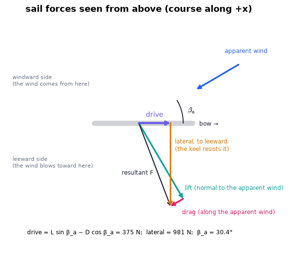

```python
fig = draw_sail_polygon(sf=sf)                               # force diagram with our numbers: apparent wind, lift, drag, their resultant split into drive and side force
plt.show()                                                   # display
```

**What you see.** The force diagram of our sail: the apparent wind (blue), the lift at right angles to it (teal), the drag along it (rose), and their resultant split into drive (along the course) and side force (across it).

**How to read it.** The diagram is turned so that the boat sails to the right (course along +x); the apparent wind arrives from ahead and from the top of the page, so the top is the windward side and the bottom the leeward side. The resultant leans forward of the beam (the direction square to the course) by $\beta_a-\varepsilon_A$: the apparent-wind angle minus the sail's drag angle. That lean is the drive. The much larger side force is what the keel must cancel.

**What would change if…** …the sail were baggy, with L/D = 3? Its drag angle would open from 9.5° to 18.4° and the boat could not point as high.

📝 **Note.** **N82 [B]** **Tacking.** No boat sails straight into the wind. It zig-zags at a fixed angle to it, and what counts is the speed made good toward the destination, $V\cos\theta$ (ours).

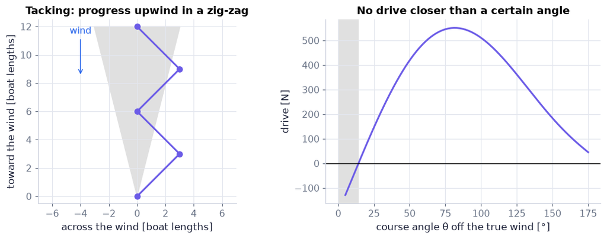

```
the drive vanishes at θ = 14.2° off the true wind (at V = 3 m/s, sail L/D = 6)
```

```python
th_deg = np.linspace(5.0, 175.0, 171)                        # course angles off the true wind [degrees]
drive_curve = ch14.sail_drive_curve(theta=np.deg2rad(th_deg), U=boat["U_wind"], V=boat["V_boat"], CL=boat["CL"], CD=boat["CD"], rho=1.225, A=boat["A_sail"])   # drive [N] on each course at a boat speed of 3 m/s
th_zero = np.interp(0.0, drive_curve[:40], th_deg[:40])      # the course at which the drive vanishes (the curve rises steadily there)
fig, (axp, axd) = plt.subplots(1, 2, figsize=(9.4, 3.6))     # left: a tacking path; right: drive against course
legs = np.array([[0, 0], [3, 3], [0, 6], [3, 9], [0, 12]])   # a zig-zag at 45° either side of the wind direction (the wind blows down the page)
axp.fill([0, -12*np.tan(np.deg2rad(th_zero)), 12*np.tan(np.deg2rad(th_zero))], [0, 12, 12], color="0.88")   # the no-go wedge either side of the wind direction
axp.plot(legs[:, 0], legs[:, 1], "-o", color=COLORS["accent"])   # the path
axp.annotate("wind", xy=(-4, 8.5), xytext=(-4, 11.5), arrowprops=dict(arrowstyle="->", color=COLORS["blue"]), color=COLORS["blue"], ha="center")   # the wind blows down the page
axp.set(xlim=(-7, 7), ylim=(-0.5, 12.5), xlabel="across the wind [boat lengths]", ylabel="toward the wind [boat lengths]", title="Tacking: progress upwind in a zig-zag")   # labels
axp.set_aspect("equal")                                      # true proportions
axd.plot(th_deg, drive_curve, color=COLORS["accent"])        # drive against course angle
axd.axhline(0, color="k", lw=0.8)                            # zero drive
axd.axvspan(0, th_zero, color="0.88")                        # courses on which the sail cannot drive the boat
axd.set(xlabel="course angle θ off the true wind [°]", ylabel="drive [N]", title="No drive closer than a certain angle")   # labels
plt.show()                                                   # display
print(f"the drive vanishes at θ = {th_zero:.1f}° off the true wind (at V = 3 m/s, sail L/D = 6)")   # the edge of the no-go zone for the sail alone
```

**What you see.** Left: a boat's zig-zag path toward the wind, with the wedge it cannot sail in shaded. Right: the sail's drive against the course angle at a boat speed of 3 m/s; the shaded band is where the drive is negative.

**How to read it.** The drive is zero where the apparent wind is at the sail's drag angle (9.5° off the bow), which for this boat speed is the printed course angle off the *true* wind. From there it rises steeply, peaks with the wind somewhat ahead of the beam, and falls again toward a run. To go upwind the boat sails either side of the wedge and tacks.

**What would change if…** …the boat were faster? The apparent wind would swing further ahead and the wedge would widen: fast boats tack through wider angles.

```python
n_frames = 40 if not FAST else 20                            # number of frames (fewer when FAST)
fig, (axf, axs) = plt.subplots(1, 2, figsize=(9.2, 3.6))     # left: a fish tail through one stroke; right: a boat tacking upwind
axf.set(xlim=(-1.6, 1.6), ylim=(-1.3, 1.3), title="fish tail: thrust forward on both half-strokes", xlabel="swimming direction ←", ylabel="sideways")   # fixed axes
axf.set_aspect("equal")                                      # true proportions
(tail,) = axf.plot([], [], color="k", lw=3)                  # the tail fin, seen from above
qf = axf.quiver([0, 0, 0], [0, 0, 0], [0, 0, 0], [0, 0, 0], color=[COLORS["blue"], COLORS["teal"], COLORS["accent"]], angles="xy", scale_units="xy", scale=1, width=0.012)   # relative velocity, lift, thrust
axs.set(xlim=(-5, 5), ylim=(-0.5, 12.5), title="sail: drive forward on both tacks", xlabel="across the wind", ylabel="toward the wind ↑ (the wind blows ↓)")   # fixed axes
axs.set_aspect("equal")                                      # true proportions
(track,) = axs.plot([], [], color="0.6", lw=1)               # the path sailed so far
qs = axs.quiver([0, 0], [0, 0], [0, 0], [0, 0], color=[COLORS["blue"], COLORS["accent"]], angles="xy", scale_units="xy", scale=1, width=0.012)   # apparent wind and drive
path_x = lambda p: 3*np.abs(((p/3 + 1) % 2) - 1) - 1.5       # zig-zag: across-wind position for a distance p made good toward the wind
fig.canvas.draw(); fig.set_layout_engine("none")             # lay the figure out once, then freeze it
def update(i):                                               # draw frame i
    ph = 2*np.pi*i/n_frames                                  # phase of the tail stroke
    Vt = fish["V"]*np.cos(ph)                                # the tail's sideways velocity now [m/s]
    yt = 0.6*np.sin(ph)                                      # its sideways position
    of = ch14.oscillating_foil(U=fish["U"], V=abs(Vt) + 1e-9, L=fish["L"]*abs(Vt)/fish["V"])   # quasi-steady: lift ∝ the sideways speed
    sgn = np.sign(Vt) if Vt != 0 else 1.0                    # which way the tail is moving
    tail.set_data([0.0, 0.5], [yt, yt - 0.25*sgn*np.sin(of["theta"])])   # the fin, turned a little into its relative flow
    qf.set_offsets(np.c_[[0.0, 0.0, 0.0], [yt, yt, yt]])     # all three arrows start at the fin
    qf.set_UVC([fish["U"], -of["thrust"]/10, -of["thrust"]/10], [-Vt, -sgn*of["side_force"]/10, 0.0])   # relative water velocity; lift (thrust forward, side force against the motion); thrust alone
    p = 12*i/n_frames                                        # distance made good toward the wind
    pp = np.linspace(0, p, 80)                               # the path so far
    track.set_data(path_x(pp), pp)                           # draw it
    tack = 1.0 if ((p/3 + 1) % 2) > 1 else -1.0              # which tack: heading up-right (+1) or up-left (−1)
    head = np.array([tack*np.sin(boat["theta"]), np.cos(boat["theta"])])   # unit vector along the course, 45° off the wind direction
    wind_app = np.array([0.0, -boat["U_wind"]]) - boat["V_boat"]*head      # apparent wind = true wind (blowing down the page) − boat velocity
    qs.set_offsets(np.c_[[path_x(p), path_x(p)], [p, p]])    # both arrows start at the boat
    qs.set_UVC([wind_app[0]/4, head[0]*sf["drive"]/250], [wind_app[1]/4, head[1]*sf["drive"]/250])   # apparent wind (scaled) and drive (scaled)
show_animation(animate(update, frames=n_frames, fig=fig, interval=90), player="video")   # a smooth video
```

[video not shown]

**What does the code above do?**

1. Left: at each instant of the stroke the tail's sideways velocity sets the velocity triangle; `ch14.oscillating_foil` returns thrust and side force for it (quasi-steady: each instant treated as steady, with the lift taken proportional to the sideways speed). Arrows: relative water velocity (blue), lift (teal), thrust (purple).
2. Right: a boat zig-zags upwind at 45° either side of the wind; the arrows are the apparent wind (blue) and the drive (purple) from `ch14.sail_forces`, drawn along the course.
3. The arrows are scaled for the drawing; their directions are what matters.

**What you see.** Left: a tail fin sweeping from side to side. Right: a boat tacking toward the wind.

**How to read it.** The teal lift arrow swings from one side to the other with the stroke, but its forward part — the purple thrust — points the same way on both half-strokes. On the right the drive arrow likewise points along the course on both tacks, although the apparent wind comes alternately over the right and the left bow.

**What would change if…** …the tail moved faster for the same swimming speed? θ grows, the lift leans further forward: more thrust per newton of lift, but more side force to pay for in a real, lossy fin.

```python
th_c = np.linspace(2.0, 178.0, 177)                          # course angles off the true wind [degrees]
beta_c = np.array([ch14.apparent_wind(U=1.0, V=0.5, theta=np.deg2rad(t_))["beta_a"] for t_ in th_c])   # apparent-wind angle off the bow for a boat at half the wind speed [rad]
def drive_per_lift(LD):                                      # drive per unit lift against course angle for one sail lift-to-drag ratio
    d_ = np.sin(beta_c) - np.cos(beta_c)/LD                  # (L sin β_a − D cos β_a)/L with D/L = 1/LD
    return {"drive / lift": (th_c, d_), "no drive below this line": (th_c, 0*th_c)}   # the curve and the zero line
figF9 = slider_figure(drive_per_lift, "sail L/D", np.linspace(2.0, 12.0, 21), unit="", xlabel="course angle θ off the true wind [°]",
                      ylabel="drive per unit lift [–]", yrange=[-0.55, 1.05], title="A better sail narrows the wedge you cannot sail in (V/U = 0.5)")   # 21 slider positions
figF9.show()                                                 # display
print(pd.DataFrame([{"sail L/D": LD_, "drag angle ε_A [°]": np.degrees(np.arctan(1/LD_)), "drive vanishes at θ [°]": np.interp(0.0, np.sin(beta_c) - np.cos(beta_c)/LD_, th_c)} for LD_ in (2.0, 4.0, 6.0, 12.0)]).round(1).to_string(index=False))   # where the curve crosses zero
```

[interactive chart not shown]

```
 sail L/D  drag angle ε_A [°]  drive vanishes at θ [°]
      2.0                26.6                     39.5
      4.0                14.0                     21.0
      6.0                 9.5                     14.2
     12.0                 4.8                      7.1
```

**What does the code above do?**

1. `beta_c` is the apparent-wind angle on every course for a boat moving at half the wind speed (`ch14.apparent_wind`).
2. `drive_per_lift` is the drive of the derivation divided by the lift, $\sin\beta_a-\cos\beta_a/(L/D)$.
3. The table lists, for four sails, the drag angle and the course on which the drive vanishes.

**What you see.** Drive per unit of lift against the course angle, with a slider for the sail's lift-to-drag ratio.

**How to read it.** The curve crosses zero where the apparent wind is at the sail's drag angle. A poor sail (L/D = 2) cannot drive the boat closer than about 40° to the true wind at this speed; a good one (L/D = 12) gets within about 7°. The hull's own drag angle adds to this (step 8 of the derivation).

**What would change if…** …the boat sailed faster relative to the wind? Every curve shifts right: the apparent wind moves ahead.

#### 🎮 Interactive: How can a boat sail against the wind?

**Why interactive rather than a static figure:** turning the course toward the wind and watching the apparent wind swing forward, the lift rotate and the drive shrink to zero is the whole argument; switching to the fish tail or the bird's wing shows the same triangle with stream and motion exchanged.

Start with the **Walkthrough**; the **Explain** tab works every number out with your settings, and the **Derivation** tab (where there is one) steps through the same derivation as above. Γ is the clockwise circulation in every readout; angles are shown in degrees and computed in radians.

**What to try:**

- Head up until the drive bar reaches zero and read $\beta_a$.
- Give the sail a perfect L/D: where is the limit now?
- Switch to 'fish tail' and press play.
- In 'bird wing', compare the downstroke with the upstroke.

```python
show_viz("ch14", "thrust_from_lift")   # full-width explainer; ⤢ Full screen for more room
```

🎮 Interactive 9/9 How can a boat sail against the wind? Open alone ↗

[interactive chart not shown]

**What would change if…** …the air were compressible? Then pressure itself travels at a finite speed and a wing can outrun its own disturbance: Chapter 15.

*↪ **S01** The chapter's exercises are not reproduced. The results the chapter relies on were taught above: the pressure loop (C07), the flat plate (C02, C06), the circular arc (C04), leading-edge suction (C07), the half-line vortex (C09), the horseshoe wing, its velocity field and ground effect (C09), the parabolic and elliptic loadings (C09, C14), the twisted wing (C12), the finite-wing lift slope (C14), the rolling moment (C12), tip-vortex cores (C10), the edge of finite angle (C04) and the projectile (C01). **S02** Literature: see the chapter's reference list in the book; the public sources used for cross-checks are listed in `analysis/ch14.md` §8.*

## ✅ What should have clicked

- **C01** A wing is a span, an area and their ratio; in level flight the lift coefficient it needs is its weight over dynamic pressure times area.
- **C02** Ideal flow allows any circulation; the sharp trailing edge allows one.
- **C03** The wing gets its circulation by shedding the opposite one — the total never leaves zero.
- **C04** Raise the circle and the plate bends; move it back and the nose fattens; the tail is the point the map folds.
- **C05** Same potential at partner points; the speed is rescaled by the map, infinitely at the tail.
- **C06** Lift grows by 2π per radian of angle; camber shifts the line without tilting it.
- **C07** Lift is the area between two pressure curves, mostly suction near the nose.
- **C08** Wherever the circulation drops along the span, a vortex trails off.
- **C09** Each trailing filament is half a line vortex; together they make the air at the wing sink.
- **C10** Lift is perpendicular to sinking air, so it leans back: drag without friction.
- **C11** Measure the span by an angle and the loading by sines, and the singular integral is done once.
- **C12** N stations, N sines, one linear solve: any planform, any twist.
- **C13** Lift lives in the first sine; every other one only costs drag.
- **C14** One sine means uniform downwash and the least drag, and the price falls with the square of the span.
- **C15** Profile drag rises with speed, induced drag falls; the best glide is where they are equal.
- **C16** Move a wing across the stream and its lift leans forward: a fish tail, a wing beat, a sail.

**What later chapters build on**

- **Ch. 15 (compressible flow)** — the lift slope 2π against the supersonic thin-airfoil value; the suction peak and the critical Mach number; finite wings with a compressibility-corrected slope $K$; shock waves and sweep.
- **Ch. 16 (biofluid mechanics)** — fins, flapping and low Reynolds numbers.
- **Wind-turbine and propeller blades** — the same section in a rotating relative wind (the velocity triangle of C16 once more).

**Not taught here (and where to find it)**

- thin-airfoil theory and Theodorsen's method (named in C04; standard aerodynamics texts)
- the Kármán–Trefftz section (named in C06)
- viscous prediction of stall and maximum lift (C07, C15 — qualitative only)
- unsteady aerodynamics beyond the lumped-vortex sketch (C03)
- swept and low-aspect-ratio wings (limits listed in C12)
- the measured data behind the generic curves (C15)

← All chapters

← PreviousNext →

Code and explanations: shammun/fluidpy (MIT). The book is not reproduced here; equations are cited by number.